# Project: Investigate TMDb movies

- Introduction
- Data Wrangling
- Exploratory Data Analysis
- Conclusions

## Introduction

> I choosed TMDb movies Dataset which cleaned from original data on Kaggle to analyze This data set contains information about 10,000 movies collected from The Movie Database (TMDb), including user vote counts, user rating for each movie , budgets and revenues, cast and dierctor and other atrractive information to be explored .

```python
import pandas as pd
import numpy as np
import scipy.stats
import requests
import re
import os
import json
import matplotlib.pyplot as plt
% matplotlib inline
import seaborn as sns
from scipy import stats
import datetime
import warnings
warnings.filterwarnings('ignore')
```

## Data Wrangling

```python
# loadin data.
df = pd.read_csv('tmdb-movies.csv')
df.head()
```

|  | id | imdb_id | popularity | budget | revenue | original_title | cast | homepage | director | tagline | ... | overview | runtime | genres | production_companies | release_date | vote_count | vote_average | release_year | budget_adj | revenue_adj |
| --- | --- | --- | --- | --- | --- | --- | --- | --- | --- | --- | --- | --- | --- | --- | --- | --- | --- | --- | --- | --- | --- |
| 0 | 135397 | tt0369610 | 32.985763 | 150000000 | 1513528810 | Jurassic World | Chris Pratt\|Bryce Dallas Howard\|Irrfan Khan\|Vi... | http://www.jurassicworld.com/ | Colin Trevorrow | The park is open. | ... | Twenty-two years after the events of Jurassic ... | 124 | Action\|Adventure\|Science Fiction\|Thriller | Universal Studios\|Amblin Entertainment\|Legenda... | 6/9/15 | 5562 | 6.5 | 2015 | 1.379999e+08 | 1.392446e+09 |
| 1 | 76341 | tt1392190 | 28.419936 | 150000000 | 378436354 | Mad Max: Fury Road | Tom Hardy\|Charlize Theron\|Hugh Keays-Byrne\|Nic... | http://www.madmaxmovie.com/ | George Miller | What a Lovely Day. | ... | An apocalyptic story set in the furthest reach... | 120 | Action\|Adventure\|Science Fiction\|Thriller | Village Roadshow Pictures\|Kennedy Miller Produ... | 5/13/15 | 6185 | 7.1 | 2015 | 1.379999e+08 | 3.481613e+08 |
| 2 | 262500 | tt2908446 | 13.112507 | 110000000 | 295238201 | Insurgent | Shailene Woodley\|Theo James\|Kate Winslet\|Ansel... | http://www.thedivergentseries.movie/#insurgent | Robert Schwentke | One Choice Can Destroy You | ... | Beatrice Prior must confront her inner demons ... | 119 | Adventure\|Science Fiction\|Thriller | Summit Entertainment\|Mandeville Films\|Red Wago... | 3/18/15 | 2480 | 6.3 | 2015 | 1.012000e+08 | 2.716190e+08 |
| 3 | 140607 | tt2488496 | 11.173104 | 200000000 | 2068178225 | Star Wars: The Force Awakens | Harrison Ford\|Mark Hamill\|Carrie Fisher\|Adam D... | http://www.starwars.com/films/star-wars-episod... | J.J. Abrams | Every generation has a story. | ... | Thirty years after defeating the Galactic Empi... | 136 | Action\|Adventure\|Science Fiction\|Fantasy | Lucasfilm\|Truenorth Productions\|Bad Robot | 12/15/15 | 5292 | 7.5 | 2015 | 1.839999e+08 | 1.902723e+09 |
| 4 | 168259 | tt2820852 | 9.335014 | 190000000 | 1506249360 | Furious 7 | Vin Diesel\|Paul Walker\|Jason Statham\|Michelle ... | http://www.furious7.com/ | James Wan | Vengeance Hits Home | ... | Deckard Shaw seeks revenge against Dominic Tor... | 137 | Action\|Crime\|Thriller | Universal Pictures\|Original Film\|Media Rights ... | 4/1/15 | 2947 | 7.3 | 2015 | 1.747999e+08 | 1.385749e+09 |

5 rows × 21 columns

```python
df.sample(30)
```

|  | id | imdb_id | popularity | budget | revenue | original_title | cast | homepage | director | tagline | ... | overview | runtime | genres | production_companies | release_date | vote_count | vote_average | release_year | budget_adj | revenue_adj |
| --- | --- | --- | --- | --- | --- | --- | --- | --- | --- | --- | --- | --- | --- | --- | --- | --- | --- | --- | --- | --- | --- |
| 2425 | 817 | tt0145660 | 1.560867 | 33000000 | 310940086 | Austin Powers: The Spy Who Shagged Me | Mike Myers\|Heather Graham\|Michael York\|Robert ... | NaN | Jay Roach | I'm back, baby! | ... | When diabolical genius, Dr. Evil travels back ... | 95 | Crime\|Adventure\|Action\|Comedy\|Science Fiction | New Line Cinema\|Eric's Boy | 6/8/99 | 583 | 6.0 | 1999 | 4.319874e+07 | 4.070370e+08 |
| 5840 | 192136 | tt2304771 | 0.229656 | 35000000 | 27330000 | Mandela: Long Walk to Freedom | Idris Elba\|Naomie Harris\|Tony Kgoroge\|Riaad Mo... | NaN | Justin Chadwick | It is an ideal for which I am prepared to die. | ... | A chronicle of Nelson Mandela's life journey f... | 141 | Drama\|History | Distant Horizons\|Film Afrika Worldwide\|Videovi... | 12/6/13 | 165 | 6.5 | 2013 | 3.276117e+07 | 2.558179e+07 |
| 6435 | 2610 | tt0338427 | 0.270403 | 10284523 | 11588205 | Shopgirl | Steve Martin\|Claire Danes\|Jason Schwartzman\|Br... | NaN | Anand Tucker | NaN | ... | Mirabelle is a disenchanted salesgirl and aspi... | 104 | Comedy\|Drama\|Romance | Epsilon Motion Pictures\|Hyde Park Films\|Shopgi... | 10/21/05 | 31 | 5.8 | 2005 | 1.148332e+07 | 1.293896e+07 |
| 7226 | 10257 | tt0398373 | 0.150708 | 0 | 0 | Chin Kei Bin 2 - Fa Tou Tai Kam | Donnie Yen\|Charlene Choi\|Gillian Chung\|Edison ... | NaN | Corey Yuen Kwai\|Patrick Leung | NaN | ... | In the mythical land of Huadu, Charcoal Head, ... | 106 | Adventure\|Action\|Comedy\|Science Fiction | NaN | 8/12/04 | 16 | 5.2 | 2004 | 0.000000e+00 | 0.000000e+00 |
| 3803 | 31880 | tt0807028 | 0.250308 | 0 | 0 | The Pool Boys | Efren Ramirez\|Matthew Lillard\|Brett Davern\|Jen... | NaN | J.B. Rogers | NaN | ... | A pool boy and a gardener turn an empty mansio... | 84 | Comedy | A-Mark Entertainment\|Zide-Perry Productions\|Fl... | 9/30/11 | 15 | 4.6 | 2011 | 0.000000e+00 | 0.000000e+00 |
| 5276 | 2163 | tt0118771 | 0.835336 | 36000000 | 50159144 | Breakdown | Kurt Russell\|J. T. Walsh\|Kathleen Quinlan\|M.C.... | NaN | Jonathan Mostow | It could happen to you. | ... | When his SUV breaks down on a remote Southwest... | 95 | Drama\|Action\|Thriller | Paramount Pictures\|Dino De Laurentiis Company\|... | 5/2/97 | 84 | 6.5 | 1997 | 4.890457e+07 | 6.813921e+07 |
| 3197 | 15706 | tt1051981 | 0.264137 | 0 | 0 | Another Gay Sequel: Gays Gone Wild! | Jonah Blechman\|Jake Mosser\|Aaron Michael Davie... | NaN | Todd Stephens | NaN | ... | ANOTHER GAY SEQUEL finds our heroes ANDY, NICO... | 90 | Comedy | TLA Releasing\|Luna Filmproduktion | 11/6/08 | 15 | 6.1 | 2008 | 0.000000e+00 | 0.000000e+00 |
| 10653 | 11202 | tt0066206 | 0.467344 | 12000000 | 89800000 | Patton | George C. Scott\|Karl Malden\|Stephen Young\|Mich... | NaN | Franklin J. Schaffner | The Rebel Warrior | ... | "Patton" tells the tale of General George S. P... | 172 | Drama\|History\|War | Twentieth Century Fox Film Corporation | 1/25/70 | 188 | 6.9 | 1970 | 6.739642e+07 | 5.043499e+08 |
| 1768 | 25405 | tt1019454 | 0.118447 | 0 | 0 | Taking Chance | Kevin Bacon\|Tom Aldredge\|Nicholas Art\|Blanche ... | http://www.hbo.com/movies/taking-chance/index.... | Ross Katz | When one falls, another brings him home. | ... | Lt. Col. Michael Strobl, a volunteer military ... | 77 | Drama\|History\|War | Motion Picture Corporation of America | 9/21/09 | 17 | 6.7 | 2009 | 0.000000e+00 | 0.000000e+00 |
| 5615 | 132344 | tt2209418 | 0.639506 | 3000000 | 11176469 | Before Midnight | Ethan Hawke\|Julie Delpy\|Seamus Davey-Fitzpatri... | NaN | Richard Linklater | Everything's better with maturity | ... | We meet Jesse and Celine nine years on in Gree... | 108 | Romance\|Drama | Castle Rock Entertainment\|Detour Filmproductio... | 4/5/13 | 346 | 7.1 | 2013 | 2.808100e+06 | 1.046155e+07 |
| 4489 | 115290 | tt2287663 | 0.728625 | 0 | 0 | Blue Lagoon: The Awakening | Indiana Evans\|Brenton Thwaites\|Denise Richards... | http://www.lifetime.com | Jake Newsome | The Awakening | ... | Two high school students become stranded on a ... | 85 | Drama\|Adventure\|Romance | Storyline Entertainment\|PeaceOut Productions\|S... | 6/16/12 | 126 | 6.1 | 2012 | 0.000000e+00 | 0.000000e+00 |
| 1001 | 236399 | tt3074694 | 0.303538 | 0 | 0 | Flowers in the Attic | Heather Graham\|Ellen Burstyn\|Kiernan Shipka\|Dy... | NaN | Deborah Chow | NaN | ... | After the sudden death of their father, four c... | 90 | Drama\|Mystery\|Thriller\|TV Movie | Front Street Pictures\|Cue the Dog Productions\|... | 1/18/14 | 56 | 6.4 | 2014 | 0.000000e+00 | 0.000000e+00 |
| 6903 | 8421 | tt0478337 | 0.142518 | 0 | 0 | Zidane, un portrait du 21e siècle | Zinedine Zidane | NaN | Douglas Gordon\|Philippe Parreno | NaN | ... | Halfway between a sports documentary and an co... | 90 | Documentary\|Foreign | Anna Lena Films\|Naflastrengir | 5/23/06 | 11 | 5.5 | 2006 | 0.000000e+00 | 0.000000e+00 |
| 1940 | 18823 | tt0800320 | 2.087252 | 125000000 | 232713139 | Clash of the Titans | Sam Worthington\|Liam Neeson\|Ralph Fiennes\|Gemm... | http://www.clash-of-the-titans.com/ | Louis Leterrier | Titans will clash. | ... | Born of a god but raised as a man, Perseus is ... | 106 | Adventure\|Fantasy\|Action | The Zanuck Company\|Legendary Pictures\|Thunder ... | 4/1/10 | 1530 | 5.6 | 2010 | 1.250000e+08 | 2.327131e+08 |
| 5560 | 209244 | tt1545754 | 0.878843 | 0 | 0 | Are You Here | Owen Wilson\|Zach Galifianakis\|Amy Poehler\|Laur... | NaN | Matthew Weiner | Friendship... there's nothing in it for anybody. | ... | When Steve Dallas, a womanizing local weatherm... | 114 | Comedy | Gilbert Films | 9/7/13 | 69 | 4.9 | 2013 | 0.000000e+00 | 0.000000e+00 |
| 8977 | 9487 | tt0120623 | 2.005566 | 120000000 | 363398565 | A Bug's Life | Kevin Spacey\|Julia Louis-Dreyfus\|Hayden Panett... | http://movies.disney.com/a-bugs-life | John Lasseter\|Andrew Stanton | An epic presentation of miniature proportions. | ... | On behalf of "oppressed bugs everywhere," an i... | 95 | Family\|Animation | Walt Disney Pictures\|Pixar Animation Studios | 11/25/98 | 1159 | 6.6 | 1998 | 1.605235e+08 | 4.861166e+08 |
| 5498 | 146239 | tt2387559 | 1.304540 | 26000000 | 51164106 | Delivery Man | Vince Vaughn\|Cobie Smulders\|Chris Pratt\|Britt ... | NaN | Ken Scott | You're never quite ready for what life delivers. | ... | An affable underachiever finds out he's father... | 105 | Comedy | DreamWorks SKG\|Touchstone Pictures | 10/10/13 | 377 | 6.1 | 2013 | 2.433687e+07 | 4.789131e+07 |
| 6658 | 3509 | tt0405296 | 0.715451 | 8500000 | 5480996 | A Scanner Darkly | Keanu Reeves\|Winona Ryder\|Woody Harrelson\|Robe... | http://www.warnerbros.com/movies/home-entertai... | Richard Linklater | Everything Is Not Going To Be OK | ... | An undercover cop in a not-too-distant future ... | 100 | Animation\|Science Fiction\|Thriller | Thousand Words\|Warner Independent Pictures (WI... | 5/25/06 | 282 | 6.7 | 2006 | 9.194188e+06 | 5.928624e+06 |
| 10363 | 11198 | tt0103950 | 0.209795 | 0 | 0 | Sing si lip yan | Jackie Chan\|Joey Wong\|Richard Norton\|Kumiko Go... | NaN | Wong Jing | NaN | ... | Extremely silly comedy about a self-indulgent ... | 105 | Action\|Adventure\|Comedy\|Romance | Golden Harvest Company\|Golden Way Films Ltd.\|P... | 1/16/93 | 38 | 6.6 | 1993 | 0.000000e+00 | 0.000000e+00 |
| 3585 | 64720 | tt1675192 | 0.509532 | 5000000 | 3099314 | Take Shelter | Michael Shannon\|Jessica Chastain\|Katy Mixon\|Sh... | http://www.sonyclassics.com/takeshelter/ | Jeff Nichols | A Jeff Nichols Film | ... | Plagued by a series of apocalyptic visions, a ... | 120 | Thriller\|Drama | Hydraulx\|REI Capital\|Grove Hill Productions\|St... | 11/25/11 | 248 | 6.9 | 2011 | 4.846990e+06 | 3.004469e+06 |
| 1257 | 292483 | tt3569356 | 0.075965 | 0 | 0 | Not Cool | Shane Dawson\|Cherami Leigh\|Drew Monson\|Lisa Sc... | http://www.notcoolthemovie.com/ | Shane Dawson | NaN | ... | NOT COOL follows former prom king and college ... | 90 | Comedy | Steeltown Entertainment\|Point Park University\|... | 9/23/14 | 17 | 4.1 | 2014 | 0.000000e+00 | 0.000000e+00 |
| 3041 | 13253 | tt1054486 | 0.534059 | 0 | 0 | Futurama: Bender's Game | Billy West\|Katey Sagal\|John DiMaggio\|Phil LaMa... | NaN | Dwayne Carey-Hill | All-New Feature-Length Quest | ... | When Leela is insulted by a group of space-red... | 88 | Animation\|Comedy\|Science Fiction | 20th Century Fox Television | 11/3/08 | 90 | 6.9 | 2008 | 0.000000e+00 | 0.000000e+00 |
| 2992 | 13018 | tt0800240 | 0.715969 | 25000000 | 17741298 | Deception | Hugh Jackman\|Ewan McGregor\|Michelle Williams\|B... | NaN | Marcel Langenegger | When you're in this world, no one is who they ... | ... | As a corporate auditor who works in a number o... | 107 | Drama\|Thriller\|Crime\|Mystery | Rifkin-Eberts\|Dune Entertainment III\|Seed Prod... | 4/24/08 | 107 | 5.8 | 2008 | 2.531967e+07 | 1.796815e+07 |
| 2390 | 46718 | tt1663633 | 0.050600 | 0 | 0 | DC Showcase: Green Arrow | Neal McDonough\|Malcolm McDowell\|Grey Griffin\|A... | NaN | Joaquim Dos Santos | NaN | ... | At an airport, the Emerald Archer must protect... | 11 | Animation\|Adventure | DC Comics\|Warner Bros. Animation | 9/28/10 | 19 | 7.3 | 2010 | 0.000000e+00 | 0.000000e+00 |
| 6467 | 9787 | tt0355702 | 0.195984 | 25000000 | 13411957 | Lords of Dogtown | Emile Hirsch\|Victor Rasuk\|Rebecca De Mornay\|Jo... | NaN | Catherine Hardwicke | They never thought they'd be famous, but they ... | ... | The film follows the surf and skateboarding tr... | 107 | Drama | Columbia Pictures\|TriStar Pictures | 6/3/05 | 118 | 6.9 | 2005 | 2.791408e+07 | 1.497530e+07 |
| 9538 | 5241 | tt0096324 | 0.259260 | 0 | 1547397 | Two Moon Junction | Sherilyn Fenn\|Richard Tyson\|Louise Fletcher\|Bu... | NaN | Zalman King | NaN | ... | A young Southern débutante temporarily abando... | 104 | Drama\|Romance | DDM Film Corporation\|Lorimar Motion Pictures | 4/29/88 | 10 | 4.6 | 1988 | 0.000000e+00 | 2.853231e+06 |
| 9924 | 252 | tt0067992 | 2.430667 | 3000000 | 4000000 | Willy Wonka & the Chocolate Factory | Gene Wilder\|Jack Albertson\|Peter Ostrum\|Roy Ki... | NaN | Mel Stuart | It's Scrumdiddlyumptious! | ... | Eccentric candy man Willy Wonka prompts a worl... | 100 | Family\|Fantasy | David L. Wolper Productions | 6/29/71 | 434 | 7.2 | 1971 | 1.615558e+07 | 2.154078e+07 |
| 10137 | 28430 | tt0054790 | 0.083697 | 0 | 0 | The Day the Earth Caught Fire | Janet Munro\|Leo McKern\|Edward Judd\|Michael Goo... | NaN | Val Guest | The INCREDIBLE becomes Real! The IMPOSSIBLE be... | ... | British reporters suspect an international cov... | 98 | Science Fiction\|Drama | Pax Films | 11/1/61 | 13 | 7.2 | 1961 | 0.000000e+00 | 0.000000e+00 |
| 271 | 293771 | tt3816458 | 0.459597 | 0 | 0 | Dead Rising | Jesse Metcalfe\|Meghan Ory\|Keegan Connor Tracy\|... | NaN | Zach Lipovsky | NaN | ... | Based on the game, Dead Rising takes place dur... | 118 | Horror\|Science Fiction | Di Bonaventura Pictures\|Contradiction Films\|De... | 3/27/15 | 82 | 4.9 | 2015 | 0.000000e+00 | 0.000000e+00 |
| 1786 | 32338 | tt1094668 | 0.212004 | 0 | 0 | Jusqu'Ã toi | Mélanie Laurent\|Justin Bartha\|Billy Boyd\|Jess... | http://www.jusquatoi.fr | Jennifer Devoldère | NaN | ... | Jack is encouraged to take the romantic Paris ... | 81 | Comedy\|Romance\|Family | Quad Productions | 7/29/09 | 11 | 4.7 | 2009 | 0.000000e+00 | 0.000000e+00 |

30 rows × 21 columns

```python
df.shape
```

```
(10866, 21)
```

```python
df.columns
```

```
Index(['id', 'imdb_id', 'popularity', 'budget', 'revenue', 'original_title',
       'cast', 'homepage', 'director', 'tagline', 'keywords', 'overview',
       'runtime', 'genres', 'production_companies', 'release_date',
       'vote_count', 'vote_average', 'release_year', 'budget_adj',
       'revenue_adj'],
      dtype='object')
```

```python
df.info()
```

```
<class 'pandas.core.frame.DataFrame'>
RangeIndex: 10866 entries, 0 to 10865
Data columns (total 21 columns):
id                      10866 non-null int64
imdb_id                 10856 non-null object
popularity              10866 non-null float64
budget                  10866 non-null int64
revenue                 10866 non-null int64
original_title          10866 non-null object
cast                    10790 non-null object
homepage                2936 non-null object
director                10822 non-null object
tagline                 8042 non-null object
keywords                9373 non-null object
overview                10862 non-null object
runtime                 10866 non-null int64
genres                  10843 non-null object
production_companies    9836 non-null object
release_date            10866 non-null object
vote_count              10866 non-null int64
vote_average            10866 non-null float64
release_year            10866 non-null int64
budget_adj              10866 non-null float64
revenue_adj             10866 non-null float64
dtypes: float64(4), int64(6), object(11)
memory usage: 1.7+ MB
```

```python
df.describe()
```

|  | id | popularity | budget | revenue | runtime | vote_count | vote_average | release_year | budget_adj | revenue_adj |
| --- | --- | --- | --- | --- | --- | --- | --- | --- | --- | --- |
| count | 10866.000000 | 10866.000000 | 1.086600e+04 | 1.086600e+04 | 10866.000000 | 10866.000000 | 10866.000000 | 10866.000000 | 1.086600e+04 | 1.086600e+04 |
| mean | 66064.177434 | 0.646441 | 1.462570e+07 | 3.982332e+07 | 102.070863 | 217.389748 | 5.974922 | 2001.322658 | 1.755104e+07 | 5.136436e+07 |
| std | 92130.136561 | 1.000185 | 3.091321e+07 | 1.170035e+08 | 31.381405 | 575.619058 | 0.935142 | 12.812941 | 3.430616e+07 | 1.446325e+08 |
| min | 5.000000 | 0.000065 | 0.000000e+00 | 0.000000e+00 | 0.000000 | 10.000000 | 1.500000 | 1960.000000 | 0.000000e+00 | 0.000000e+00 |
| 25% | 10596.250000 | 0.207583 | 0.000000e+00 | 0.000000e+00 | 90.000000 | 17.000000 | 5.400000 | 1995.000000 | 0.000000e+00 | 0.000000e+00 |
| 50% | 20669.000000 | 0.383856 | 0.000000e+00 | 0.000000e+00 | 99.000000 | 38.000000 | 6.000000 | 2006.000000 | 0.000000e+00 | 0.000000e+00 |
| 75% | 75610.000000 | 0.713817 | 1.500000e+07 | 2.400000e+07 | 111.000000 | 145.750000 | 6.600000 | 2011.000000 | 2.085325e+07 | 3.369710e+07 |
| max | 417859.000000 | 32.985763 | 4.250000e+08 | 2.781506e+09 | 900.000000 | 9767.000000 | 9.200000 | 2015.000000 | 4.250000e+08 | 2.827124e+09 |

```python
df[df['cast'].isnull() == True]
```

|  | id | imdb_id | popularity | budget | revenue | original_title | cast | homepage | director | tagline | ... | overview | runtime | genres | production_companies | release_date | vote_count | vote_average | release_year | budget_adj | revenue_adj |
| --- | --- | --- | --- | --- | --- | --- | --- | --- | --- | --- | --- | --- | --- | --- | --- | --- | --- | --- | --- | --- | --- |
| 371 | 345637 | tt4661600 | 0.422901 | 0 | 0 | Sanjay's Super Team | NaN | NaN | Sanjay Patel | NaN | ... | Sanjay's Super Team follows the daydream of a ... | 7 | Animation | Pixar Animation Studios | 11/25/15 | 47 | 6.9 | 2015 | 0.000000e+00 | 0.000000e+00 |
| 441 | 355020 | tt4908644 | 0.220751 | 0 | 0 | Winter on Fire: Ukraine's Fight for Freedom | NaN | http://www.netflix.com/title/80031666 | Evgeny Afineevsky | The Next Generation Of Revolution | ... | A documentary on the unrest in Ukraine during ... | 98 | Documentary | Passion Pictures\|Campbell Grobman Films\|Afinee... | 10/9/15 | 37 | 8.2 | 2015 | 0.000000e+00 | 0.000000e+00 |
| 465 | 321109 | tt4393514 | 0.201696 | 0 | 0 | Bitter Lake | NaN | NaN | Adam Curtis | NaN | ... | An experimental documentary that explores Saud... | 135 | Documentary | BBC | 1/24/15 | 19 | 7.8 | 2015 | 0.000000e+00 | 0.000000e+00 |
| 536 | 333350 | tt3762974 | 0.122543 | 0 | 0 | A Faster Horse | NaN | NaN | David Gelb | NaN | ... | David Gelb (Jiro Dreams of Sushi) tackles anot... | 90 | Documentary | NaN | 10/8/15 | 12 | 8.0 | 2015 | 0.000000e+00 | 0.000000e+00 |
| 538 | 224972 | tt3983674 | 0.114264 | 0 | 0 | The Mask You Live In | NaN | http://themaskyoulivein.org | Jennifer Siebel Newsom | Is american masculinity harming our boys, men ... | ... | Compared to girls, research shows that boys in... | 88 | Documentary | NaN | 1/1/15 | 11 | 8.9 | 2015 | 0.000000e+00 | 0.000000e+00 |
| 587 | 319091 | tt4185572 | 0.062536 | 0 | 0 | The Hunting Ground | NaN | NaN | Kirby Dick | NaN | ... | From the makers of The Invisible War comes a s... | 103 | Documentary | NaN | 2/27/15 | 39 | 7.8 | 2015 | 0.000000e+00 | 0.000000e+00 |
| 600 | 332479 | tt4550996 | 0.047256 | 0 | 0 | Star Wars: TIE Fighter | NaN | https://www.youtube.com/watch?v=PN_CP4SuoTU | Paul Johnson | star wars, Tie Fighter, anime | ... | Paul “OtaKing” Johnson drops a real treat i... | 7 | Science Fiction\|Action\|Animation | NaN | 3/24/15 | 29 | 7.6 | 2015 | 0.000000e+00 | 0.000000e+00 |
| 620 | 361043 | tt5022680 | 0.129696 | 0 | 0 | All Hallows' Eve 2 | NaN | NaN | Antonio Padovan\|Bryan Norton\|Marc Roussel\|Ryan... | NaN | ... | A woman finds a VHS tape on her doorstep that ... | 90 | NaN | Ruthless Pictures\|Hollywood Shorts | 10/6/15 | 13 | 5.0 | 2015 | 0.000000e+00 | 0.000000e+00 |
| 1088 | 169607 | tt2714900 | 0.226028 | 0 | 1503616 | Finding Vivian Maier | NaN | http://www.vivianmaier.com/film-finding-vivian... | John Maloof\|Charlie Siskel | NaN | ... | Vivian Maier's photos were seemingly destined ... | 83 | Documentary | NaN | 3/28/14 | 70 | 7.8 | 2014 | 0.000000e+00 | 1.384967e+06 |
| 1173 | 261041 | tt3576038 | 0.159037 | 0 | 0 | The Search for General Tso | NaN | NaN | Ian Cheney | NaN | ... | From New York City to the farmlands of the Mid... | 71 | Documentary | NaN | 4/20/14 | 14 | 6.9 | 2014 | 0.000000e+00 | 0.000000e+00 |
| 1177 | 269711 | tt3723996 | 0.153047 | 0 | 0 | JohnnyExpress | NaN | http://www.james-woo.com/#!jonnyexpress/ccag | Kyungmin Woo | Dark and occasionally cruel... | ... | It's 2150. There are all sorts of Aliens livin... | 5 | Animation\|Comedy\|Science Fiction | Alfred Image Works | 5/8/14 | 14 | 7.8 | 2014 | 0.000000e+00 | 0.000000e+00 |
| 1190 | 250761 | tt3279124 | 0.137962 | 0 | 0 | Last Days in Vietnam | NaN | NaN | Rory Kennedy | How Many Could Be Saved? | ... | During the chaotic final weeks of the Vietnam ... | 98 | War\|Documentary | NaN | 9/5/14 | 20 | 5.9 | 2014 | 0.000000e+00 | 0.000000e+00 |
| 1208 | 282297 | tt3302820 | 0.116190 | 117 | 0 | Cowspiracy: The Sustainability Secret | NaN | http://cowspiracy.com/ | Kip Anderson\|Keegan Kuhn | There is one single industry destroying the pl... | ... | "COWSPIRACY: The Sustainability Secret" is a g... | 85 | Documentary | First Spark Media\|A.U.M. Films | 7/1/14 | 66 | 7.6 | 2014 | 1.077677e+02 | 0.000000e+00 |
| 1236 | 250665 | tt3399112 | 0.093062 | 0 | 0 | No No: A Dockumentary | NaN | http://www.nonoadockumentary.com/ | Jeffrey Radice | NaN | ... | Dock Ellis pitched a no-hitter on LSD, then wo... | 100 | Documentary | NaN | 1/20/14 | 13 | 6.7 | 2014 | 0.000000e+00 | 0.000000e+00 |
| 1256 | 299729 | tt3995006 | 0.076280 | 0 | 0 | Banksy Does New York | NaN | NaN | Chris Moukarbel | The street is at play. | ... | On October 1, 2013, the elusive street artist ... | 79 | Documentary | Home Box Office (HBO)\|Matador Content\|Permanen... | 11/17/14 | 22 | 6.8 | 2014 | 0.000000e+00 | 0.000000e+00 |
| 1315 | 250745 | tt2171902 | 0.008000 | 0 | 0 | Happy Valley | NaN | NaN | Amir Bar-Lev | NaN | ... | The children of "Happy Valley" were victimized... | 98 | Documentary | NaN | 11/14/14 | 14 | 6.0 | 2014 | 0.000000e+00 | 0.000000e+00 |
| 1316 | 245158 | tt2925642 | 0.007622 | 0 | 0 | Kids for Cash | NaN | NaN | Robert May | NaN | ... | A look into the judicial scandal that rocked t... | 102 | Documentary\|Thriller | NaN | 2/7/14 | 12 | 7.1 | 2014 | 0.000000e+00 | 0.000000e+00 |
| 1319 | 320420 | tt3249478 | 0.005844 | 0 | 0 | Love Me | NaN | NaN | Jonathon Narducci | NaN | ... | Love Me follows Western men and Ukrainian wome... | 94 | Documentary | NaN | 4/6/14 | 13 | 7.0 | 2014 | 0.000000e+00 | 0.000000e+00 |
| 1326 | 250668 | tt2548738 | 0.023872 | 0 | 0 | Rich Hill | NaN | NaN | Tracy Droz Tragos\|Andrew Droz Palermo | NaN | ... | If you ever find yourself traveling down Inter... | 91 | Documentary | NaN | 1/19/14 | 14 | 7.1 | 2014 | 0.000000e+00 | 0.000000e+00 |
| 1327 | 258614 | tt2966760 | 0.003504 | 0 | 0 | Pantani: The Accidental Death of a Cyclist | NaN | NaN | James Erskine | Every man has his own mountain to climb | ... | In 1998 Marco Pantani, the most flamboyant and... | 90 | Documentary | NaN | 2/17/14 | 11 | 6.5 | 2014 | 0.000000e+00 | 0.000000e+00 |
| 1385 | 20785 | tt0075988 | 0.002457 | 0 | 0 | Emmet Otter's Jug-Band Christmas | NaN | NaN | Jim Henson | NaN | ... | A poor otter family risks everything for the c... | 48 | Drama\|Comedy\|Family | NaN | 1/1/77 | 10 | 7.5 | 1977 | 0.000000e+00 | 0.000000e+00 |
| 1889 | 23951 | tt1241325 | 0.058472 | 0 | 0 | Objectified | NaN | http://www.objectifiedfilm.com/ | Gary Hustwit | NaN | ... | A feature-length documentary about our complex... | 75 | Documentary | NaN | 3/14/09 | 46 | 7.2 | 2009 | 0.000000e+00 | 0.000000e+00 |
| 1899 | 31160 | tt1490530 | 0.027045 | 0 | 0 | Alma | NaN | http://almashortfilm.com/ | Rodrigo Blaas | NaN | ... | Alma, a little girl, skips through the snow co... | 6 | Animation\|Fantasy\|Mystery | NaN | 1/1/09 | 28 | 7.2 | 2009 | 0.000000e+00 | 0.000000e+00 |
| 1910 | 39246 | tt1370889 | 0.002460 | 0 | 0 | Talhotblond | NaN | NaN | Barbara Schroeder | NaN | ... | This is the true story of a love triangle that... | 83 | Documentary | NaN | 2/1/09 | 11 | 6.0 | 2009 | 0.000000e+00 | 0.000000e+00 |
| 2269 | 51299 | tt1828232 | 0.222293 | 0 | 0 | Life Cycles | NaN | http://www.lifecyclesfilm.com/ | Derek Frankowski | NaN | ... | Life Cycles tells a spectacular story of the b... | 47 | Documentary | NaN | 10/2/10 | 27 | 8.8 | 2010 | 0.000000e+00 | 0.000000e+00 |
| 2285 | 41584 | tt1611787 | 0.208862 | 0 | 0 | Wonders of the Solar System | NaN | NaN | Michael Lachmann\|Paul Olding | NaN | ... | Prepare to immerse yourself in an alien world ... | 60 | Documentary | British Broadcasting Corporation (BBC) | 8/4/10 | 10 | 5.1 | 2010 | 0.000000e+00 | 0.000000e+00 |
| 2392 | 69480 | tt1704619 | 0.049803 | 0 | 0 | Tabloid | NaN | NaN | Errol Morris | NaN | ... | A documentary on a former Miss Wyoming who is ... | 87 | Documentary | NaN | 10/1/10 | 24 | 6.3 | 2010 | 0.000000e+00 | 0.000000e+00 |
| 2397 | 241829 | tt1805454 | 0.033048 | 0 | 0 | The Making of The Walking Dead | NaN | NaN | NaN | NaN | ... | The Making of the TV Series The Walking Dead | 30 | Documentary | NaN | 7/31/10 | 42 | 8.4 | 2010 | 0.000000e+00 | 0.000000e+00 |
| 2405 | 54527 | tt1194612 | 0.033845 | 900000 | 0 | Into Eternity | NaN | http://www.intoeternitythemovie.com/ | Michael Madsen | NaN | ... | Every day, the world over, large amounts of hi... | 75 | Documentary | NaN | 11/12/10 | 15 | 7.6 | 2010 | 9.000000e+05 | 0.000000e+00 |
| 3097 | 10378 | tt1254207 | 0.256180 | 150000 | 0 | Big Buck Bunny | NaN | http://www.bigbuckbunny.org | Sacha Goedegebure | NaN | ... | Follow a day of the life of Big Buck Bunny whe... | 8 | Animation\|Comedy | Blender Foundation | 4/10/08 | 37 | 6.5 | 2008 | 1.519180e+05 | 0.000000e+00 |
| ... | ... | ... | ... | ... | ... | ... | ... | ... | ... | ... | ... | ... | ... | ... | ... | ... | ... | ... | ... | ... | ... |
| 4920 | 151044 | tt2354205 | 0.083362 | 0 | 0 | McCullin | NaN | NaN | Jacqui Morris\|David Morris | Seeing and looking at what others cannot bear ... | ... | Biographical documentary of the war photograph... | 89 | Documentary | NaN | 4/26/12 | 11 | 7.2 | 2012 | 0.000000e+00 | 0.000000e+00 |
| 4921 | 157301 | tt2162565 | 0.081053 | 0 | 0 | Adam and Dog | NaN | http://adamanddog.tumblr.com/ | Minkyu Lee | NaN | ... | A playful dog exploring the newly created worl... | 15 | Animation | NaN | 11/6/12 | 11 | 6.0 | 2012 | 0.000000e+00 | 0.000000e+00 |
| 4933 | 147538 | tt2396224 | 0.019197 | 0 | 0 | It's Such a Beautiful Day | NaN | NaN | Don Hertzfeldt | NaN | ... | Bill struggles to put together his shattered p... | 62 | Fantasy\|Animation\|Comedy\|Drama | Bitter Films | 10/5/12 | 51 | 7.9 | 2012 | 0.000000e+00 | 0.000000e+00 |
| 4939 | 168219 | tt2167393 | 0.003183 | 0 | 0 | The Men Who Built America | NaN | NaN | NaN | America wasn't discovered. It was built. | ... | John D. Rockefeller, Cornelius Vanderbilt, And... | 360 | Documentary\|History | NaN | 10/16/12 | 11 | 5.3 | 2012 | 0.000000e+00 | 0.000000e+00 |
| 5413 | 20378 | tt0163986 | 0.324270 | 0 | 0 | The Brave Little Toaster to the Rescue | NaN | NaN | NaN | NaN | ... | Those fun-loving eletrical appliances from the... | 74 | Animation\|Comedy\|Family | NaN | 11/1/97 | 11 | 7.0 | 1997 | 0.000000e+00 | 0.000000e+00 |
| 6024 | 159012 | tt2504022 | 0.080336 | 0 | 0 | Narco Cultura | NaN | http://narcoculture.com/ | Shaul Schwarz | The Hits Just Keep on Coming | ... | To a growing number of Mexicans and Latinos in... | 103 | Documentary | Parts and Labor\|K5 International\|Cinedigm\|Ocea... | 11/22/13 | 19 | 7.3 | 2013 | 0.000000e+00 | 0.000000e+00 |
| 6055 | 184149 | tt2204371 | 0.019755 | 0 | 0 | Somm | NaN | NaN | Jason Wise | How much do you know about wine? | ... | Somm takes the viewer on a humorous, emotional... | 93 | Documentary | NaN | 6/21/13 | 20 | 7.0 | 2013 | 0.000000e+00 | 0.000000e+00 |
| 6078 | 376823 | tt3231100 | 0.002647 | 0 | 0 | Trophy Kids | NaN | NaN | Chris Bell | NaN | ... | From the director of Bigger Stronger Faster co... | 107 | Documentary | NaN | 12/4/13 | 10 | 7.8 | 2013 | 0.000000e+00 | 0.000000e+00 |
| 6374 | 13933 | tt0479113 | 0.392879 | 0 | 0 | One Man Band | NaN | NaN | Mark Andrews\|Andrew Jimenez | Vibrant and Whimsical! | ... | With one coin to make a wish at the piazza fou... | 4 | Animation\|Family | Pixar Animation Studios | 6/21/05 | 70 | 7.1 | 2005 | 0.000000e+00 | 0.000000e+00 |
| 6514 | 98622 | tt0443424 | 0.128484 | 0 | 0 | 9 | NaN | http://www.shaneacker.com | Shane Acker | NaN | ... | A rag doll fights a monster that has been stea... | 11 | Animation\|Fantasy | NaN | 4/21/05 | 49 | 7.3 | 2005 | 0.000000e+00 | 0.000000e+00 |
| 6736 | 13060 | tt0945571 | 0.434986 | 0 | 0 | Lifted | NaN | http://www.pixar.com/shorts/lift/ | Gary Rydstrom | Failure is an option. | ... | When an overconfident teen alien gets behind t... | 5 | Animation\|Family | Pixar Animation Studios | 12/28/06 | 154 | 7.7 | 2006 | 0.000000e+00 | 0.000000e+00 |
| 6760 | 38580 | tt0816562 | 0.371028 | 0 | 0 | The Little Matchgirl | NaN | NaN | Roger Allers | NaN | ... | An animated short based on Hans Christian Ande... | 7 | Drama\|Animation | Walt Disney | 9/7/06 | 15 | 6.5 | 2006 | 0.000000e+00 | 0.000000e+00 |
| 6870 | 14518 | tt0863136 | 0.194447 | 2300000 | 0 | Peter & the Wolf | NaN | http://www.peterandthewolffilm.co.uk/ | Suzie Templeton | Boys like Peter are not afraid of wolves... | ... | An animated retelling set to Prokofiev's suite... | 32 | Animation\|Family\|Music | Se-ma-for Studios\|Storm Studio\|Archangel\|TV UN... | 9/23/06 | 11 | 6.7 | 2006 | 2.487839e+06 | 0.000000e+00 |
| 6930 | 53215 | tt1051713 | 0.076078 | 0 | 0 | Kiwi! | NaN | NaN | Dony Permedi | NaN | ... | The story of a Kiwi who spends his whole life ... | 3 | Animation\|Action | NaN | 1/1/06 | 15 | 6.7 | 2006 | 0.000000e+00 | 0.000000e+00 |
| 7650 | 12172 | tt1093824 | 0.383253 | 0 | 0 | Encounters at the End of the World | NaN | http://www.encountersfilm.co.uk/ | Werner Herzog | Off the map, things get strange. | ... | Herzog and cinematographer Peter Zeitlinger go... | 99 | Documentary | Discovery Films | 9/1/07 | 38 | 6.7 | 2007 | 0.000000e+00 | 0.000000e+00 |
| 7723 | 13016 | tt1166827 | 0.197715 | 7000000 | 0 | Zeitgeist | NaN | http://www.zeitgeistmovie.com | Peter Joseph | NaN | ... | Zeitgeist: the Movie is a 2007 documentary fil... | 118 | Documentary\|History | Gentle Machine Productions LLC | 6/1/07 | 104 | 6.9 | 2007 | 7.361680e+06 | 0.000000e+00 |
| 7813 | 22887 | tt0914809 | 0.065543 | 6000 | 6000 | Loose Change: Final Cut | NaN | NaN | Dylan Avery | NaN | ... | Loose Change Final Cut is the third installmen... | 129 | Documentary | Louder Than Words | 11/11/07 | 12 | 5.1 | 2007 | 6.310011e+03 | 6.310011e+03 |
| 7905 | 13924 | tt0086855 | 0.647261 | 0 | 0 | The Adventures of André and Wally B. | NaN | NaN | Alvy Ray Smith | NaN | ... | There's nothing like a restful nap in a pleasa... | 2 | Animation | Lucasfilm\|Pixar Animation Studios | 12/17/84 | 32 | 5.3 | 1984 | 0.000000e+00 | 0.000000e+00 |
| 8292 | 14002 | tt0103767 | 0.521669 | 4000000 | 0 | Baraka | NaN | http://en.wikipedia.org/wiki/Baraka_(film) | Ron Fricke | A world beyond words. | ... | This is a paralyzingly beautiful documentary w... | 96 | Documentary | Magidson Films | 9/15/92 | 89 | 7.6 | 1992 | 6.216097e+06 | 0.000000e+00 |
| 8824 | 48617 | tt0279079 | 0.191631 | 0 | 0 | Father and Daughter | NaN | NaN | Michael Dudok de Wit | Moved to tears in 8 minutes | ... | A father says goodbye to his young daughter. I... | 8 | Animation\|Drama | CinéTé Filmproductie BV | 1/1/00 | 18 | 6.9 | 2000 | 0.000000e+00 | 0.000000e+00 |
| 8880 | 48868 | tt0400231 | 0.032577 | 0 | 0 | The World of Stainboy | NaN | NaN | Tim Burton | NaN | ... | Stainboy visits his troubled past. | 30 | Animation | NaN | 1/1/00 | 10 | 6.3 | 2000 | 0.000000e+00 | 0.000000e+00 |
| 9251 | 13928 | tt0097674 | 0.471351 | 0 | 0 | Knick Knack | NaN | NaN | John Lasseter | NaN | ... | Life on a shelf as a snowman trapped in a snow... | 4 | Animation\|Family | Pixar Animation Studios | 1/1/89 | 77 | 7.1 | 1989 | 0.000000e+00 | 0.000000e+00 |
| 9529 | 13927 | tt0096273 | 0.236514 | 0 | 0 | Tin Toy | NaN | NaN | John Lasseter | NaN | ... | Babies are hardly monster-like, unless you're ... | 5 | Animation\|Family | Pixar Animation Studios | 8/1/88 | 51 | 6.1 | 1988 | 0.000000e+00 | 0.000000e+00 |
| 9564 | 24348 | tt0095895 | 0.168545 | 2500000 | 589244 | Powaqqatsi | NaN | NaN | Godfrey Reggio | NaN | ... | An exploration of technologically developing n... | 99 | Documentary\|Drama\|Music | NaN | 4/29/88 | 18 | 7.2 | 1988 | 4.609728e+06 | 1.086502e+06 |
| 9593 | 46188 | tt0220698 | 0.001662 | 0 | 0 | Peter Pan | NaN | NaN | NaN | NaN | ... | This animated fairy tale for kids tells the cl... | 52 | Action\|Adventure\|Animation\|Family\|Fantasy | Burbank Films Australia | 1/1/88 | 28 | 6.6 | 1988 | 0.000000e+00 | 0.000000e+00 |
| 9677 | 13926 | tt0093832 | 0.253376 | 0 | 0 | Red's Dream | NaN | NaN | John Lasseter | NaN | ... | Life as the sole sale item in the clearance co... | 4 | Animation | Pixar Animation Studios | 8/17/87 | 44 | 6.6 | 1987 | 0.000000e+00 | 0.000000e+00 |
| 9755 | 48714 | tt0061402 | 0.046272 | 0 | 0 | The Big Shave | NaN | NaN | Martin Scorsese | NaN | ... | This short film is a metaphor for the Vietnam ... | 6 | Drama | NaN | 1/1/68 | 12 | 6.7 | 1968 | 0.000000e+00 | 0.000000e+00 |
| 10434 | 48784 | tt0060984 | 0.146906 | 200 | 0 | Six Men Getting Sick | NaN | NaN | David Lynch | NaN | ... | Lynch's first film project consists of a loop ... | 4 | Animation | Pensylvania Academy of Fine Arts | 1/1/67 | 16 | 5.2 | 1967 | 1.307353e+03 | 0.000000e+00 |
| 10550 | 13925 | tt0091455 | 0.306425 | 0 | 0 | Luxo Jr. | NaN | http://www.pixar.com/short_films/Theatrical-Sh... | John Lasseter | NaN | ... | A baby lamp finds a ball to play with and it's... | 2 | Animation\|Family | Pixar Animation Studios | 8/17/86 | 81 | 7.3 | 1986 | 0.000000e+00 | 0.000000e+00 |
| 10754 | 3171 | tt0064064 | 0.002757 | 0 | 0 | Bambi Meets Godzilla | NaN | NaN | Marv Newland | NaN | ... | Bambi is nibbling the grass, unaware of the up... | 2 | Animation\|Comedy | NaN | 1/1/69 | 12 | 5.6 | 1969 | 0.000000e+00 | 0.000000e+00 |

76 rows × 21 columns

```python
df[df['imdb_id'].isnull() == True]
```

|  | id | imdb_id | popularity | budget | revenue | original_title | cast | homepage | director | tagline | ... | overview | runtime | genres | production_companies | release_date | vote_count | vote_average | release_year | budget_adj | revenue_adj |
| --- | --- | --- | --- | --- | --- | --- | --- | --- | --- | --- | --- | --- | --- | --- | --- | --- | --- | --- | --- | --- | --- |
| 548 | 355131 | NaN | 0.108072 | 0 | 0 | Sense8: Creating the World | Tuppence Middleton\|Bae Doona \|Brian J. Smith\|A... | NaN | NaN | NaN | ... | NaN | 25 | Documentary\|Science Fiction | Netflix | 8/10/15 | 12 | 7.5 | 2015 | 0.000000 | 0.0 |
| 997 | 287663 | NaN | 0.330431 | 0 | 0 | Star Wars Rebels: Spark of Rebellion | Freddie Prinze Jr.\|Vanessa Marshall\|Steve Blum... | NaN | Steward Lee\|Steven G. Lee | NaN | ... | A Long Time Ago In A Galaxy Far, Far Away… A... | 44 | NaN | NaN | 10/3/14 | 13 | 6.8 | 2014 | 0.000000 | 0.0 |
| 1528 | 15257 | NaN | 0.607851 | 0 | 0 | Hulk vs. Wolverine | Fred Tatasciore\|Bryce Johnson\|Steve Blum\|Nolan... | NaN | Frank Paur | NaN | ... | Department H sends in Wolverine to track down ... | 38 | Animation\|Action\|Science Fiction | Marvel Studios | 1/27/09 | 38 | 6.9 | 2009 | 0.000000 | 0.0 |
| 1750 | 101907 | NaN | 0.256975 | 0 | 0 | Hulk vs. Thor | Graham McTavish\|Fred Tatasciore\|Matthew Wolf\|J... | NaN | Sam Liu | A Battle Between God and Monster | ... | For ages, Odin has protected his kingdom of As... | 41 | Action\|Animation\|Fantasy\|Science Fiction | Marvel Studios | 1/27/09 | 38 | 6.4 | 2009 | 0.000000 | 0.0 |
| 2401 | 45644 | NaN | 0.067753 | 0 | 0 | Opeth: In Live Concert At The Royal Albert Hall | Mikael Åkerfeldt\|Martin "Axe" Axenrot\|Martin ... | http://www.opeth.com | NaN | The Loyal Disharmonic Orchestra, Conducted By ... | ... | As part of the ongoing celebration of their 20... | 163 | Music | NaN | 9/21/10 | 10 | 8.6 | 2010 | 0.000000 | 0.0 |
| 4797 | 369145 | NaN | 0.167501 | 0 | 0 | Doctor Who: The Snowmen | Matt Smith\|Jenna Coleman\|Richard E. Grant\|Ian ... | NaN | NaN | NaN | ... | Christmas Eve, 1892, and the falling snow is t... | 60 | NaN | BBC Television UK | 12/25/12 | 10 | 7.8 | 2012 | 0.000000 | 0.0 |
| 4872 | 269177 | NaN | 0.090552 | 0 | 0 | Party Bercy | Florence Foresti | NaN | NaN | NaN | ... | Florence Foresti is offered Bercy tribute to a... | 120 | Comedy | TF1 Vidéo | 9/23/12 | 15 | 6.4 | 2012 | 0.000000 | 0.0 |
| 6071 | 279954 | NaN | 0.004323 | 500 | 0 | Portal: Survive! | Monique Blanchard\|Bradley Mixon | https://www.kickstarter.com/projects/colinandc... | Connor McGuire\|Colin McGuire | The Cake is a Lie | ... | A short, live action fan film by Collin and Co... | 7 | Action\|Science Fiction | NaN | 10/8/13 | 11 | 7.5 | 2013 | 468.016676 | 0.0 |
| 7527 | 50127 | NaN | 0.570337 | 0 | 0 | Fallen: The Journey | Paul Wesley\|Fernanda Andrade\|Tom Skerritt\|Rick... | NaN | Mikael Salomon | NaN | ... | A year later, Aaron is still traveling around ... | 80 | Action\|Adventure\|Drama\|Fantasy\|Family | NaN | 1/1/07 | 11 | 7.3 | 2007 | 0.000000 | 0.0 |
| 7809 | 50128 | NaN | 0.060795 | 0 | 0 | Fallen: The Destiny | Paul Wesley\|Fernanda Andrade\|Tom Skerritt\|Rick... | NaN | Mikael Salomon | NaN | ... | Aaron and Azazel defeat the Powers, and force ... | 80 | Adventure\|Fantasy\|Drama\|Action\|Science Fiction | NaN | 1/1/07 | 13 | 7.0 | 2007 | 0.000000 | 0.0 |

10 rows × 21 columns

```python
df[df['id'].isnull() == True]
```

|  | id | imdb_id | popularity | budget | revenue | original_title | cast | homepage | director | tagline | ... | overview | runtime | genres | production_companies | release_date | vote_count | vote_average | release_year | budget_adj | revenue_adj |
| --- | --- | --- | --- | --- | --- | --- | --- | --- | --- | --- | --- | --- | --- | --- | --- | --- | --- | --- | --- | --- | --- |

0 rows × 21 columns

```python
df[df['original_title'].isnull() == True]
```

|  | id | imdb_id | popularity | budget | revenue | original_title | cast | homepage | director | tagline | ... | overview | runtime | genres | production_companies | release_date | vote_count | vote_average | release_year | budget_adj | revenue_adj |
| --- | --- | --- | --- | --- | --- | --- | --- | --- | --- | --- | --- | --- | --- | --- | --- | --- | --- | --- | --- | --- | --- |

0 rows × 21 columns

```python
df[df['director'].isnull() == True]
```

|  | id | imdb_id | popularity | budget | revenue | original_title | cast | homepage | director | tagline | ... | overview | runtime | genres | production_companies | release_date | vote_count | vote_average | release_year | budget_adj | revenue_adj |
| --- | --- | --- | --- | --- | --- | --- | --- | --- | --- | --- | --- | --- | --- | --- | --- | --- | --- | --- | --- | --- | --- |
| 532 | 320996 | tt4073952 | 0.126594 | 0 | 0 | Iliza Shlesinger: Freezing Hot | Iliza Shlesinger | http://www.iliza.com/freezing-hot.html | NaN | NaN | ... | Smart and brazen comedian Iliza Shlesinger sha... | 71 | Comedy | New Wave Entertainment | 1/23/15 | 14 | 6.6 | 2015 | 0.000000e+00 | 0.000000e+00 |
| 548 | 355131 | NaN | 0.108072 | 0 | 0 | Sense8: Creating the World | Tuppence Middleton\|Bae Doona \|Brian J. Smith\|A... | NaN | NaN | NaN | ... | NaN | 25 | Documentary\|Science Fiction | Netflix | 8/10/15 | 12 | 7.5 | 2015 | 0.000000e+00 | 0.000000e+00 |
| 556 | 321160 | tt3908634 | 0.100910 | 0 | 0 | With This Ring | Regina Hall\|Jill Scott\|Eve\|Brooklyn Sudano\|Dei... | http://www.mylifetime.com/movies/with-this-ring | NaN | NaN | ... | After attending their friend Elise's (Sudano) ... | 105 | Comedy\|Romance | Lifetime Television\|Sony Pictures Television | 1/24/15 | 14 | 6.5 | 2015 | 0.000000e+00 | 0.000000e+00 |
| 1032 | 259910 | tt3591568 | 0.291253 | 0 | 0 | Marvel Studios: Assembling a Universe | Robert Downey Jr.\|Chris Hemsworth\|Chris Evans\|... | NaN | NaN | - | ... | A look at the story behind Marvel Studios and ... | 43 | TV Movie\|Documentary | Marvel Studios\|ABC Studios | 3/18/14 | 32 | 6.3 | 2014 | 0.000000e+00 | 0.000000e+00 |
| 1054 | 253675 | tt3711030 | 0.269468 | 0 | 0 | Unlocking Sherlock | Benedict Cumberbatch\|Martin Freeman\|Steven Mof... | NaN | NaN | NaN | ... | Explore how writers Steven Moffat and Mark Gat... | 60 | TV Movie\|Documentary | NaN | 1/19/14 | 11 | 7.2 | 2014 | 0.000000e+00 | 0.000000e+00 |
| 1203 | 256561 | tt3203290 | 0.119891 | 150000 | 0 | Free to Play | Benedict Lim\|Danil Ishutin\|Clinton Loomis | http://www.freetoplaythemovie.com | NaN | One game will change their lives. | ... | Follow three professional video game players a... | 75 | Documentary | Valve | 3/19/14 | 40 | 7.0 | 2014 | 1.381637e+05 | 0.000000e+00 |
| 1241 | 296370 | tt3024964 | 0.135376 | 0 | 0 | Dance-Off | Kathryn McCormick\|Shane Harper\|Finola Hughes\|C... | NaN | NaN | NaN | ... | DANCE-OFF is a tongue-in-cheek family comedy s... | 0 | Romance\|Music\|Comedy | NaN | 1/1/14 | 18 | 5.7 | 2014 | 0.000000e+00 | 0.000000e+00 |
| 1288 | 301235 | tt4217172 | 0.038364 | 0 | 0 | Top Gear: The Perfect Road Trip 2 | Jeremy Clarkson\|Richard Hammond | NaN | NaN | NaN | ... | In 2013 Jeremy Clarkson and Richard Hammond em... | 94 | Documentary | 2 Entertain Video | 11/17/14 | 12 | 6.8 | 2014 | 0.000000e+00 | 0.000000e+00 |
| 1852 | 133365 | tt1127205 | 0.256703 | 0 | 0 | The Diary of Anne Frank | Ellie Kendrick\|Kate Ashfield\|Geoff Breton\|Feli... | NaN | NaN | NaN | ... | Called the most accurate adaptation of Anne Fr... | 100 | Drama | Darlow Smithson Productions\|British Broadcasti... | 1/9/09 | 19 | 7.5 | 2009 | 0.000000e+00 | 0.000000e+00 |
| 1872 | 26379 | tt1532957 | 0.091395 | 3250000 | 0 | Paa | Amitabh Bachchan\|Abhishek Bachchan\|Vidya Balan... | http://www.paathefilm.com/ | NaN | NaN | ... | He suffers from a progeria like syndrome. Ment... | 133 | Drama\|Family\|Foreign | A B Corp | 12/4/09 | 11 | 6.1 | 2009 | 3.303301e+06 | 0.000000e+00 |
| 1895 | 281979 | tt1413314 | 0.056777 | 0 | 0 | Doctor Who: The Waters of Mars | David Tennant | NaN | NaN | NaN | ... | The Doctor joins forces with his oldest compan... | 62 | Science Fiction\|Adventure\|Family | BBC Wales | 12/19/09 | 25 | 8.0 | 2009 | 0.000000e+00 | 0.000000e+00 |
| 2221 | 48832 | tt1707823 | 0.281852 | 0 | 0 | Scott Pilgrim vs. the Animation | Michael Cera\|Alison Pill\|Georgette Perna\|Mae W... | NaN | NaN | Read the Comic. Watch the Movie. See the Anima... | ... | Scott Pilgrim vs. The Animation is an animated... | 4 | TV Movie\|Animation\|Adventure | Titmouse | 8/10/10 | 19 | 7.7 | 2010 | 0.000000e+00 | 0.000000e+00 |
| 2286 | 47911 | tt1747960 | 0.207234 | 0 | 0 | Bo Burnham: Words, Words, Words | Bo Burnham | NaN | NaN | NaN | ... | Bo Burnham is back with a new one-man show ful... | 63 | Comedy | NaN | 10/19/10 | 13 | 6.5 | 2010 | 0.000000e+00 | 0.000000e+00 |
| 2290 | 51823 | tt1663193 | 0.203502 | 0 | 0 | Across the Line: The Exodus of Charlie Wright | Aidan Quinn\|Andy García\|Mario Van Peebles\|Dan... | NaN | NaN | Redemption has its price. | ... | The story centers on Charlie, a Los Angeles bi... | 94 | Drama\|Action\|Thriller\|Crime | NaN | 12/28/10 | 11 | 6.0 | 2010 | 0.000000e+00 | 0.000000e+00 |
| 2315 | 48373 | tt1274296 | 0.171615 | 0 | 0 | Listen to Your Heart | Alexia Rasmussen\|Kent Moran\|Cybill Shepherd\|Sh... | http://www.listentoyourheartfilm.com/ | NaN | One song can change your life. | ... | Danny Foster doesn't have much: an apartment a... | 0 | Drama\|Music\|Romance | NaN | 8/14/10 | 29 | 7.3 | 2010 | 0.000000e+00 | 0.000000e+00 |
| 2318 | 34134 | tt1610301 | 0.170408 | 0 | 0 | Barbie in A Mermaid Tale | Kelly Sheridan\|Kathleen Barr\|Nakia Burrise\|Gar... | http://www.barbie.com/mermaid-tale/ | NaN | NaN | ... | Barbie stars as Merliah, a surfing champion fr... | 75 | Animation\|Family\|Fantasy | NaN | 1/26/10 | 35 | 6.3 | 2010 | 0.000000e+00 | 0.000000e+00 |
| 2376 | 315620 | tt1672218 | 0.068411 | 0 | 0 | Doctor Who: A Christmas Carol | Matt Smith\|Karen Gillan\|Arthur Darvill\|Michael... | NaN | NaN | NaN | ... | Amy Pond and Rory Williams are trapped on a cr... | 62 | NaN | NaN | 12/25/10 | 11 | 7.7 | 2010 | 0.000000e+00 | 0.000000e+00 |
| 2397 | 241829 | tt1805454 | 0.033048 | 0 | 0 | The Making of The Walking Dead | NaN | NaN | NaN | NaN | ... | The Making of the TV Series The Walking Dead | 30 | Documentary | NaN | 7/31/10 | 42 | 8.4 | 2010 | 0.000000e+00 | 0.000000e+00 |
| 2401 | 45644 | NaN | 0.067753 | 0 | 0 | Opeth: In Live Concert At The Royal Albert Hall | Mikael Åkerfeldt\|Martin "Axe" Axenrot\|Martin ... | http://www.opeth.com | NaN | The Loyal Disharmonic Orchestra, Conducted By ... | ... | As part of the ongoing celebration of their 20... | 163 | Music | NaN | 9/21/10 | 10 | 8.6 | 2010 | 0.000000e+00 | 0.000000e+00 |
| 2403 | 72013 | tt1587157 | 0.067620 | 0 | 0 | Yu-Gi-Oh! 3D: Bonds Beyond Time | Greg Abbey\|Dan Green\|Matthew Charles\|Sean Sche... | NaN | NaN | NaN | ... | After falling through a time-slip, Yusei Fudo ... | 60 | Animation\|Fantasy | NaN | 1/23/10 | 10 | 6.0 | 2010 | 0.000000e+00 | 0.000000e+00 |
| 3171 | 17171 | tt1201984 | 0.019819 | 0 | 0 | The Assassination of Jesse James: Death Of An ... | Ted Levine\|Casey Affleck\|Brad Pitt\|Mary-Louise... | NaN | NaN | NaN | ... | Explores the true story of the notorious Jesse... | 32 | Documentary | New Wave Entertainment | 1/1/08 | 20 | 6.8 | 2008 | 0.000000e+00 | 0.000000e+00 |
| 3224 | 20313 | tt1270491 | 0.224721 | 0 | 0 | John Mayer: Where the Light Is Live in Los Ang... | John Mayer\|Steve Jordan\|Pino Palladino\|David R... | NaN | NaN | NaN | ... | Where The Light Is: John Mayer Live in Los Ang... | 164 | Music | NaN | 7/1/08 | 16 | 8.5 | 2008 | 0.000000e+00 | 0.000000e+00 |
| 3276 | 15467 | tt1105733 | 0.147657 | 4180000 | 11000000 | Kismat Konnection | Shahid Kapoor\|Vidya Balan\|Juhi Chawla\|Om Puri\|... | http://www.kismatkonnection.tips.in/ | NaN | NaN | ... | This is a story about an architect Raj Malhotr... | 153 | Drama\|Comedy\|Romance\|Foreign | Tips Industries | 7/18/08 | 11 | 5.8 | 2008 | 4.233448e+06 | 1.114065e+07 |
| 3285 | 36131 | tt1286750 | 0.136883 | 0 | 0 | Tropic Thunder: Rain of Madness | Justin Theroux\|Jack Black\|Steve Coogan\|Robert ... | NaN | NaN | Before the thunder... comes the madness. | ... | A behind-the-scenes mockumentary of Tropic Thu... | 30 | Action\|Comedy | NaN | 8/26/08 | 12 | 6.9 | 2008 | 0.000000e+00 | 0.000000e+00 |
| 3357 | 32836 | tt1254947 | 0.042517 | 0 | 0 | Bill Burr: Why Do I Do This? | Bill Burr | NaN | NaN | NaN | ... | One of America's fastest-rising comedians, Bil... | 55 | Comedy | NaN | 9/23/08 | 10 | 8.0 | 2008 | 0.000000e+00 | 0.000000e+00 |
| 3365 | 22258 | tt1321823 | 0.002475 | 0 | 0 | Foo Fighters: Live at Wembley Stadium | Dave Grohl\|Nate Mendel\|Chris Shiflett\|Pat Smea... | NaN | NaN | NaN | ... | Foo Fighters captured over their two sold-out ... | 120 | Music | NaN | 8/25/08 | 10 | 8.4 | 2008 | 0.000000e+00 | 0.000000e+00 |
| 3369 | 77974 | tt2014400 | 0.001682 | 0 | 0 | Wizards On Deck With Hannah Montana | NaN | NaN | NaN | NaN | ... | Three Disney Channel shows come together in "W... | 68 | Family | NaN | 2/11/08 | 14 | 6.1 | 2008 | 0.000000e+00 | 0.000000e+00 |
| 3910 | 79976 | tt2096615 | 0.002006 | 0 | 0 | Steve Jobs: One Last Thing | NaN | NaN | NaN | NaN | ... | Through interviews with colleagues and others ... | 60 | Documentary | NaN | 11/2/11 | 11 | 6.6 | 2011 | 0.000000e+00 | 0.000000e+00 |
| 4679 | 91342 | tt2197823 | 0.421746 | 0 | 0 | Barbie in A Mermaid Tale 2 | Nakia Burrise\|Gary Chalk | NaN | NaN | NaN | ... | Surf's up for Barbie as she returns as Merliah... | 74 | Animation\|Family | Mattel | 2/23/12 | 22 | 6.0 | 2012 | 0.000000e+00 | 0.000000e+00 |
| 4797 | 369145 | NaN | 0.167501 | 0 | 0 | Doctor Who: The Snowmen | Matt Smith\|Jenna Coleman\|Richard E. Grant\|Ian ... | NaN | NaN | NaN | ... | Christmas Eve, 1892, and the falling snow is t... | 60 | NaN | BBC Television UK | 12/25/12 | 10 | 7.8 | 2012 | 0.000000e+00 | 0.000000e+00 |
| 4872 | 269177 | NaN | 0.090552 | 0 | 0 | Party Bercy | Florence Foresti | NaN | NaN | NaN | ... | Florence Foresti is offered Bercy tribute to a... | 120 | Comedy | TF1 Vidéo | 9/23/12 | 15 | 6.4 | 2012 | 0.000000e+00 | 0.000000e+00 |
| 4939 | 168219 | tt2167393 | 0.003183 | 0 | 0 | The Men Who Built America | NaN | NaN | NaN | America wasn't discovered. It was built. | ... | John D. Rockefeller, Cornelius Vanderbilt, And... | 360 | Documentary\|History | NaN | 10/16/12 | 11 | 5.3 | 2012 | 0.000000e+00 | 0.000000e+00 |
| 5413 | 20378 | tt0163986 | 0.324270 | 0 | 0 | The Brave Little Toaster to the Rescue | NaN | NaN | NaN | NaN | ... | Those fun-loving eletrical appliances from the... | 74 | Animation\|Comedy\|Family | NaN | 11/1/97 | 11 | 7.0 | 1997 | 0.000000e+00 | 0.000000e+00 |
| 5866 | 246569 | tt2934844 | 0.211825 | 5000000 | 0 | Jinxed | Ciara Bravo\|Jack Griffo\|Jacob Bertrand\|Elena K... | NaN | NaN | NaN | ... | Meet the Murphys, a family with never ending b... | 75 | Family\|Fantasy\|Comedy | NaN | 11/29/13 | 19 | 7.0 | 2013 | 4.680167e+06 | 0.000000e+00 |
| 5915 | 284019 | tt2283584 | 0.168210 | 0 | 0 | Phineas and Ferb: Mission Marvel | Vincent Martella\|Thomas Brodie-Sangster\|Ashley... | http://disneyxd.disney.com/phineas-and-ferb/mi... | NaN | Avengers need Phineas and Ferb to Assemble. | ... | When Dr. Doofenshmirtz's latest invention caus... | 44 | Action\|Adventure\|Science Fiction | Disney Television Animation | 8/16/13 | 13 | 5.9 | 2013 | 0.000000e+00 | 0.000000e+00 |
| 5972 | 238234 | tt3258142 | 0.165605 | 0 | 0 | Top Gear: The Perfect Road Trip | Jeremy Clarkson\|Richard Hammond | NaN | NaN | Seven days, more than 1,000 miles, 20 cars, tw... | ... | The aim: to select the ideal mode of transport... | 84 | TV Movie\|Action\|Adventure\|Documentary | BBC | 11/17/13 | 35 | 7.6 | 2013 | 0.000000e+00 | 0.000000e+00 |
| 6033 | 238185 | tt3397430 | 0.048587 | 0 | 0 | Russell Brand: Messiah Complex | Russell Brand | http://www.russellbrand.com/2013/11/messiah-co... | NaN | NaN | ... | Recorded live at Hammersmith Apollo, Russell q... | 99 | Comedy | NaN | 11/25/13 | 12 | 6.8 | 2013 | 0.000000e+00 | 0.000000e+00 |
| 6181 | 18729 | tt0088583 | 0.000065 | 0 | 0 | North and South, Book I | Patrick Swayze\|Philip Casnoff\|Kirstie Alley\|Ge... | NaN | NaN | NaN | ... | Two friends, one northern and one southern, st... | 561 | Drama\|History\|Western | NaN | 11/3/85 | 17 | 6.0 | 1985 | 0.000000e+00 | 0.000000e+00 |
| 7579 | 58432 | tt0484273 | 0.443952 | 0 | 0 | La hora fría | Silke\|Omar Muñoz\|Pepo Oliva\|Carola Manzanares... | NaN | NaN | NaN | ... | The eight years boy Jesús has been living in ... | 92 | Horror\|Thriller\|Science Fiction\|Mystery\|Foreign | NaN | 9/14/07 | 10 | 4.9 | 2007 | 0.000000e+00 | 0.000000e+00 |
| 7767 | 282758 | tt0827573 | 0.126603 | 0 | 0 | Doctor Who: The Runaway Bride | David Tennant\|Catherine Tate | NaN | NaN | NaN | ... | A young bride in the midst of her wedding find... | 60 | Science Fiction\|TV Movie | NaN | 7/6/07 | 18 | 7.6 | 2007 | 0.000000e+00 | 0.000000e+00 |
| 7814 | 25565 | tt1236486 | 0.040311 | 0 | 0 | Transformers: Beginnings | Peter Cullen\|Frank Welker\|Mark Ryan\|Patrick Ha... | NaN | NaN | NaN | ... | On their home planet of Cybertron, the Autobot... | 22 | Animation\|Action\|Thriller\|Science Fiction | DreamWorks Home Entertainment | 10/16/07 | 34 | 5.8 | 2007 | 0.000000e+00 | 0.000000e+00 |
| 9593 | 46188 | tt0220698 | 0.001662 | 0 | 0 | Peter Pan | NaN | NaN | NaN | NaN | ... | This animated fairy tale for kids tells the cl... | 52 | Action\|Adventure\|Animation\|Family\|Fantasy | Burbank Films Australia | 1/1/88 | 28 | 6.6 | 1988 | 0.000000e+00 | 0.000000e+00 |
| 10386 | 225804 | tt1028555 | 0.118854 | 0 | 0 | The Making of 'The Nightmare Before Christmas' | Mike Belzer\|Tim Burton\|Bonita DeCarlo\|Greg Dyk... | NaN | NaN | NaN | ... | The Making of Tim Burton and Henry Selick's 19... | 25 | Documentary | Buena Vista Home Entertainment | 10/3/93 | 15 | 7.5 | 1993 | 0.000000e+00 | 0.000000e+00 |
| 10426 | 34038 | tt0061937 | 0.114034 | 0 | 0 | Magical Mystery Tour | John Lennon\|Paul McCartney\|George Harrison\|Rin... | NaN | NaN | NaN | ... | A typically Beatlesque film originally produce... | 55 | Music | MPI Home Video | 12/25/67 | 15 | 5.8 | 1967 | 0.000000e+00 | 0.000000e+00 |

44 rows × 21 columns

```python
df[df['budget']== 0]
```

|  | id | imdb_id | popularity | budget | revenue | original_title | cast | homepage | director | tagline | ... | overview | runtime | genres | production_companies | release_date | vote_count | vote_average | release_year | budget_adj | revenue_adj |
| --- | --- | --- | --- | --- | --- | --- | --- | --- | --- | --- | --- | --- | --- | --- | --- | --- | --- | --- | --- | --- | --- |
| 30 | 280996 | tt3168230 | 3.927333 | 0 | 29355203 | Mr. Holmes | Ian McKellen\|Milo Parker\|Laura Linney\|Hattie M... | http://www.mrholmesfilm.com/ | Bill Condon | The man behind the myth | ... | The story is set in 1947, following a long-ret... | 103 | Mystery\|Drama | BBC Films\|See-Saw Films\|FilmNation Entertainme... | 6/19/15 | 425 | 6.4 | 2015 | 0.0 | 2.700677e+07 |
| 36 | 339527 | tt1291570 | 3.358321 | 0 | 22354572 | Solace | Abbie Cornish\|Jeffrey Dean Morgan\|Colin Farrel... | NaN | Afonso Poyart | A serial killer who can see your future, a psy... | ... | A psychic doctor, John Clancy, works with an F... | 101 | Crime\|Drama\|Mystery | Eden Rock Media\|FilmNation Entertainment\|Flynn... | 9/3/15 | 474 | 6.2 | 2015 | 0.0 | 2.056620e+07 |
| 72 | 284289 | tt2911668 | 2.272044 | 0 | 45895 | Beyond the Reach | Michael Douglas\|Jeremy Irvine\|Hanna Mangan Law... | NaN | Jean-Baptiste Léonetti | NaN | ... | A high-rolling corporate shark and his impover... | 95 | Thriller | Furthur Films | 4/17/15 | 81 | 5.5 | 2015 | 0.0 | 4.222338e+04 |
| 74 | 347096 | tt3478232 | 2.165433 | 0 | 0 | Mythica: The Darkspore | Melanie Stone\|Kevin Sorbo\|Adam Johnson\|Jake St... | http://www.mythicamovie.com/#!blank/wufvh | Anne K. Black | NaN | ... | When Teela’s sister is murdered and a powerf... | 108 | Action\|Adventure\|Fantasy | Arrowstorm Entertainment | 6/24/15 | 27 | 5.1 | 2015 | 0.0 | 0.000000e+00 |
| 75 | 308369 | tt2582496 | 2.141506 | 0 | 0 | Me and Earl and the Dying Girl | Thomas Mann\|RJ Cyler\|Olivia Cooke\|Connie Britt... | http://www.foxsearchlight.com/meandearlandthed... | Alfonso Gomez-Rejon | A Little Friendship Never Killed Anyone. | ... | Greg is coasting through senior year of high s... | 105 | Comedy\|Drama | Indian Paintbrush | 6/12/15 | 569 | 7.7 | 2015 | 0.0 | 0.000000e+00 |
| 88 | 301875 | tt3289728 | 1.959765 | 0 | 2000000 | Equals | Kristen Stewart\|Nicholas Hoult\|Guy Pearce\|Jack... | http://equals-the-movie.com/ | Drake Doremus | Find your equal. | ... | A futuristic love story set in a world where e... | 101 | Drama\|Romance\|Science Fiction | Scott Free Productions\|Infinite Frameworks Stu... | 9/4/15 | 135 | 5.6 | 2015 | 0.0 | 1.839999e+06 |
| 92 | 370687 | tt3608646 | 1.876037 | 0 | 0 | Mythica: The Necromancer | Melanie Stone\|Adam Johnson\|Kevin Sorbo\|Nicola ... | http://www.mythicamovie.com/#!blank/y9ake | A. Todd Smith | NaN | ... | Mallister takes Thane prisoner and forces Mare... | 0 | Fantasy\|Action\|Adventure | Arrowstorm Entertainment\|Camera 40 Productions... | 12/19/15 | 11 | 5.4 | 2015 | 0.0 | 0.000000e+00 |
| 95 | 258509 | tt2974918 | 1.841779 | 0 | 233755553 | Alvin and the Chipmunks: The Road Chip | Jason Lee\|Justin Long\|Bella Thorne\|Matthew Gra... | http://www.foxmovies.com/movies/alvin-and-the-... | Walt Becker | Fast & furry-ous | ... | Through a series of misunderstandings, Alvin, ... | 92 | Adventure\|Animation\|Comedy\|Family | Regency Enterprises\|Fox 2000 Pictures\|Sunswept... | 12/17/15 | 278 | 5.7 | 2015 | 0.0 | 2.150550e+08 |
| 100 | 326359 | tt4007502 | 1.724712 | 0 | 0 | Frozen Fever | Kristen Bell\|Idina Menzel\|Jonathan Groff\|Josh ... | NaN | Chris Buck\|Jennifer Lee | NaN | ... | On Anna's birthday, Elsa and Kristoff are dete... | 8 | Adventure\|Animation\|Family | Walt Disney Pictures\|Walt Disney Animation Stu... | 3/9/15 | 475 | 7.0 | 2015 | 0.0 | 0.000000e+00 |
| 101 | 254302 | tt0462335 | 1.661789 | 0 | 0 | High-Rise | Tom Hiddleston\|Sienna Miller\|Jeremy Irons\|Luke... | NaN | Ben Wheatley | Leave the real world behind | ... | Dr. Robert Laing is the newest resident of a l... | 119 | Action\|Drama\|Science Fiction | Ingenious Media\|HanWay Films\|Scope Pictures\|Re... | 9/26/15 | 161 | 5.4 | 2015 | 0.0 | 0.000000e+00 |
| 103 | 292040 | tt3321300 | 1.646664 | 0 | 0 | Spooks: The Greater Good | Peter Firth\|Kit Harington\|Jennifer Ehle\|Lara P... | http://www.shinepictures.co.uk/films/9/spooks-... | Bharat Nalluri | NaN | ... | During a handover to the head of counter-terro... | 104 | Thriller\|Action | BBC Films\|Isle of Man Film\|Shine Pictures\|Kudo... | 4/11/15 | 114 | 5.6 | 2015 | 0.0 | 0.000000e+00 |
| 116 | 297291 | tt3086386 | 1.380320 | 0 | 0 | The Scorpion King: The Lost Throne | Victor Webster\|Ellen Hollman\|Barry Bostwick\|Wi... | NaN | Mike Elliott | Action Adventure | ... | When he is betrayed by a trusted friend, Matha... | 105 | Action\|Fantasy\|Adventure | Universal Pictures | 1/9/15 | 22 | 4.5 | 2015 | 0.0 | 0.000000e+00 |
| 119 | 86828 | tt1727770 | 1.360827 | 0 | 5189646 | Absolutely Anything | Simon Pegg\|Kate Beckinsale\|Rob Riggle\|Sanjeev ... | NaN | Terry Jones | Great power. Total irresponsibility. | ... | Eccentric aliens give a man the power to do an... | 85 | Comedy\|Science Fiction | Premiere Picture\|Bill and Ben Productions\|GFM ... | 6/26/15 | 199 | 5.8 | 2015 | 0.0 | 4.774472e+06 |
| 122 | 277355 | tt1945084 | 1.342839 | 0 | 0 | Everly | Salma Hayek\|Hiroyuki Watanabe\|Jennifer Blanc\|T... | NaN | Joe Lynch | Enter if you dare. | ... | After she betrays a powerful mob boss, a woman... | 90 | Thriller\|Action | Crime Scene Pictures\|Radius-TWC\|Anonymous Cont... | 1/23/15 | 169 | 5.1 | 2015 | 0.0 | 0.000000e+00 |
| 125 | 223485 | tt3205376 | 1.329702 | 0 | 229094 | Slow West | Michael Fassbender\|Kodi Smit-McPhee\|Ben Mendel... | NaN | John Maclean | Wanted Dead or Dead | ... | In the Old West, a 17-year-old Scottish boy te... | 84 | Romance\|Thriller\|Western | The New Zealand Film Commission\|Film4\|See Saw ... | 4/16/15 | 229 | 6.6 | 2015 | 0.0 | 2.107664e+05 |
| 128 | 309245 | tt2872462 | 1.293140 | 0 | 2500431 | Mistress America | Greta Gerwig\|Lola Kirke\|Charlie Gillette\|Dean ... | NaN | Noah Baumbach | From Strangers to Sisters. | ... | Tracy, a lonely college freshman in New York, ... | 84 | Comedy | RT Features | 8/14/15 | 132 | 6.4 | 2015 | 0.0 | 2.300396e+06 |
| 130 | 245706 | tt2273657 | 1.284541 | 0 | 4719695 | True Story | Jonah Hill\|James Franco\|Felicity Jones\|Maria D... | NaN | Rupert Goold | Some mysteries are beyond belief. | ... | A drama centered around the relationship betwe... | 100 | Crime\|Drama\|Mystery | Plan B Entertainment\|Regency Enterprises\|New R... | 4/17/15 | 354 | 6.0 | 2015 | 0.0 | 4.342117e+06 |
| 132 | 263109 | tt2872750 | 1.253580 | 0 | 59700000 | Shaun the Sheep Movie | Justin Fletcher\|Omid Djalili\|Richard Webber\|Ka... | http://www.shaunthesheep.com/ | Mark Burton\|Richard Starzack | Moving on to Pastures New. | ... | When Shaun decides to take the day off and hav... | 85 | Family\|Animation\|Comedy\|Adventure | Aardman Animations\|Studio Canal\|Anton Capital ... | 2/5/15 | 340 | 6.9 | 2015 | 0.0 | 5.492398e+07 |
| 134 | 321751 | tt3577624 | 1.245224 | 0 | 1702433 | A Perfect Day | Olga Kurylenko\|Benicio del Toro\|Tim Robbins\|MÃ... | NaN | Fernando León de Aranoa | NaN | ... | Film about a group of aid workers trying to re... | 106 | Comedy\|Drama | Reposado Producciones\|Televisión Española (T... | 8/28/15 | 102 | 6.3 | 2015 | 0.0 | 1.566238e+06 |
| 139 | 193687 | tt1598642 | 1.161812 | 0 | 118483 | Z for Zachariah | Margot Robbie\|Chiwetel Ejiofor\|Chris Pine | http://www.facebook.com/ZforZachariah | Craig Zobel | After the end of the world she thought she was... | ... | In the wake of a nuclear war, a young woman su... | 97 | Drama\|Science Fiction\|Thriller | Palomar Pictures\|Lucky Hat Entertainment\|Silve... | 8/13/15 | 181 | 5.5 | 2015 | 0.0 | 1.090043e+05 |
| 140 | 300803 | tt3829170 | 1.144808 | 0 | 0 | Dragonheart 3: The Sorcerer's Curse | Julian Morris\|Tamzin Merchant\|Jassa Ahluwalia\|... | NaN | Colin Teague | NaN | ... | When aspiring knight Gareth goes in search of ... | 97 | Action\|Adventure\|Fantasy | Raffaella Productions | 2/24/15 | 59 | 4.5 | 2015 | 0.0 | 0.000000e+00 |
| 143 | 378373 | tt3532278 | 1.128081 | 0 | 0 | Brothers of the Wind | Manuel Camacho\|Jean Reno\|Tobias Moretti\|Eva Kuen | http://www.terramater.at/cinema/brothers-of-th... | Gerado Olivares\|Otmar Penker | Sometimes a friendship sets you free | ... | The way of the eagle is to raise two chicks. T... | 98 | Adventure\|Drama\|Family | Terra Mater Factual Studios | 12/24/15 | 11 | 7.5 | 2015 | 0.0 | 0.000000e+00 |
| 146 | 241257 | tt3319920 | 1.065888 | 0 | 17671101 | Regression | Ethan Hawke\|Emma Watson\|Aaron Ashmore\|Devon Bo... | NaN | Alejandro Amenábar | Fear always finds its victim | ... | Minnesota, 1990. Detective Bruce Kenner (Ethan... | 106 | Horror\|Mystery\|Thriller | The Weinstein Company\|Himenóptero\|First Gener... | 10/1/15 | 310 | 5.2 | 2015 | 0.0 | 1.625741e+07 |
| 147 | 245698 | tt1596345 | 1.063055 | 0 | 0 | Pawn Sacrifice | Tobey Maguire\|Lily Rabe\|Peter Sarsgaard\|Liev S... | NaN | Edward Zwick | On the board he fought the Cold War. In his mi... | ... | American chess champion Bobby Fischer prepares... | 114 | Drama | Material Pictures\|MICA Entertainment\|PalmStar ... | 9/16/15 | 148 | 6.6 | 2015 | 0.0 | 0.000000e+00 |
| 148 | 353326 | tt0787524 | 1.046518 | 0 | 11472454 | The Man Who Knew Infinity | Jeremy Irons\|Dev Patel\|Toby Jones\|Stephen Fry\|... | http://www.ifcfilms.com/films/the-man-who-knew... | Matt Brown | What does it take to prove the impossible? | ... | Growing up poor in Madras, India, Srinivasa Ra... | 108 | Drama | Animus Films\|Edward R. Pressman Film\|Kreo Film... | 9/17/15 | 104 | 7.1 | 2015 | 0.0 | 1.055465e+07 |
| 151 | 290637 | tt3733778 | 1.036825 | 0 | 0 | Pay the Ghost | Nicolas Cage\|Sarah Wayne Callies\|Veronica Ferr... | NaN | Uli Edel | Evil walks among us. | ... | One year after his young son disappeared durin... | 94 | Horror\|Thriller | Voltage Films\|Midnight Kitchen Productions | 9/16/15 | 114 | 5.3 | 2015 | 0.0 | 0.000000e+00 |
| 152 | 244458 | tt1567437 | 1.027620 | 0 | 0 | The Voices | Ryan Reynolds\|Gemma Arterton\|Anna Kendrick\|Jac... | NaN | Marjane Satrapi | Hearing voices can be murder. | ... | A mentally unhinged factory worker must decide... | 101 | Horror\|Thriller\|Comedy\|Crime | Studio Babelsberg\|Mandalay Vision\|1984 Private... | 2/6/15 | 371 | 6.0 | 2015 | 0.0 | 0.000000e+00 |
| 153 | 308504 | tt2493486 | 1.021441 | 0 | 3643591 | Last Knights | Clive Owen\|Morgan Freeman\|Aksel Hennie\|Shohreh... | NaN | Kazuaki Kiriya | NaN | ... | When an evil emperor executes their leader, hi... | 115 | Action\|Adventure | Czech Anglo Productions\|Luka Productions | 4/3/15 | 237 | 6.3 | 2015 | 0.0 | 3.352102e+06 |
| 158 | 290762 | tt2245003 | 0.953647 | 0 | 0 | Miss You Already | Drew Barrymore\|Toni Collette\|Dominic Cooper\|Ja... | NaN | Catherine Hardwicke | When life falls apart, friends keep it together | ... | The friendship between two life-long girlfrien... | 112 | Comedy\|Drama\|Romance | S Films\|New Sparta Films | 9/12/15 | 139 | 7.2 | 2015 | 0.0 | 0.000000e+00 |
| 161 | 324807 | tt2056771 | 0.938432 | 0 | 1936524 | A Bigger Splash | Tilda Swinton\|Matthias Schoenaerts\|Ralph Fienn... | NaN | Luca Guadagnino | NaN | ... | An American couple, Paul and Marianne, spend t... | 120 | Crime\|Drama\|Mystery\|Thriller | StudioCanal\|Ministero per i Beni e le AttivitÃ... | 11/26/15 | 69 | 5.8 | 2015 | 0.0 | 1.781601e+06 |
| ... | ... | ... | ... | ... | ... | ... | ... | ... | ... | ... | ... | ... | ... | ... | ... | ... | ... | ... | ... | ... | ... |
| 10830 | 4772 | tt0060268 | 0.380321 | 0 | 0 | Cul-de-sac | Donald Pleasence\|Françoise Dorléac\|Lionel St... | NaN | Roman Polanski | NaN | ... | A wounded criminal and his dying partner take ... | 113 | Comedy\|Drama\|Foreign\|Thriller | Tekli British Productions | 2/1/66 | 18 | 6.7 | 1966 | 0.0 | 0.000000e+00 |
| 10831 | 1888 | tt0060424 | 0.529721 | 0 | 0 | The Fortune Cookie | Jack Lemmon\|Walter Matthau\|Ron Rich\|Judi West\|... | NaN | Billy Wilder | Is he a spy? A security risk? Is he unfaithful... | ... | A cameraman is knocked over during a football ... | 125 | Romance\|Comedy | Phalanx-Jaelem | 10/19/66 | 17 | 6.4 | 1966 | 0.0 | 0.000000e+00 |
| 10833 | 3001 | tt0060522 | 0.737730 | 0 | 0 | How to Steal a Million | Audrey Hepburn\|Peter O'Toole\|Eli Wallach\|Hugh ... | NaN | William Wyler | A movie about those who appreciate the finest ... | ... | A woman must steal a statue from a Paris museu... | 123 | Comedy\|Crime\|Romance | World Wide Productions | 7/13/66 | 67 | 7.3 | 1966 | 0.0 | 0.000000e+00 |
| 10834 | 12639 | tt0060897 | 0.310688 | 0 | 0 | Return of the Seven | Yul Brynner\|Robert Fuller\|Julián Mateos\|Warre... | NaN | Burt Kennedy | Between the law and the lawless - SEVEN again.... | ... | Chico one of the remaining members of The Magn... | 95 | Action\|Western | C.B. Films S.A.\|The Mirisch Production Company | 10/19/66 | 14 | 5.1 | 1966 | 0.0 | 0.000000e+00 |
| 10836 | 38720 | tt0061170 | 0.239435 | 0 | 0 | Walk Don't Run | Cary Grant\|Samantha Eggar\|Jim Hutton\|John Stan... | NaN | Charles Walters | Run, don't walk to see Walk, Don't Run. | ... | British industrialist Sir William Rutland - "B... | 114 | Comedy\|Romance | Columbia Pictures Corporation | 1/1/66 | 11 | 5.8 | 1966 | 0.0 | 0.000000e+00 |
| 10837 | 19728 | tt0060177 | 0.291704 | 0 | 0 | The Blue Max | George Peppard\|James Mason\|Ursula Andress\|Jere... | NaN | John Guillermin | There was no quiet on the Western Front! | ... | A young pilot in the German air force of 1918,... | 156 | War\|Action\|Adventure\|Drama | Twentieth Century Fox Film Corporation | 6/21/66 | 12 | 5.5 | 1966 | 0.0 | 0.000000e+00 |
| 10838 | 22383 | tt0060862 | 0.151845 | 0 | 0 | The Professionals | Burt Lancaster\|Lee Marvin\|Robert Ryan\|Woody St... | NaN | Richard Brooks | Rough, tough and ready. | ... | The Professionals is a 1966 American Western f... | 117 | Action\|Adventure\|Western | Columbia Pictures | 11/1/66 | 21 | 6.0 | 1966 | 0.0 | 0.000000e+00 |
| 10839 | 13353 | tt0060550 | 0.276133 | 0 | 0 | It's the Great Pumpkin, Charlie Brown | Christopher Shea\|Sally Dryer\|Kathy Steinberg\|A... | NaN | Bill Melendez | Every year he rises from the pumpkin patch... | ... | This classic "Peanuts" tale focuses on the thu... | 25 | Family\|Animation | Warner Bros. Home Video | 10/27/66 | 49 | 7.2 | 1966 | 0.0 | 0.000000e+00 |
| 10840 | 34388 | tt0060437 | 0.102530 | 0 | 0 | Funeral in Berlin | Michael Caine\|Paul Hubschmid\|Oskar Homolka\|Eva... | NaN | Guy Hamilton | NaN | ... | Colonel Stok, a Soviet intelligence officer re... | 102 | Thriller | Lowndes Productions Limited | 12/22/66 | 13 | 5.7 | 1966 | 0.0 | 0.000000e+00 |
| 10842 | 36540 | tt0061199 | 0.253437 | 0 | 0 | Winnie the Pooh and the Honey Tree | Sterling Holloway\|Junius Matthews\|Sebastian Ca... | NaN | Wolfgang Reitherman | NaN | ... | Christopher Robin's bear attempts to raid a be... | 25 | Animation\|Family | NaN | 1/1/66 | 12 | 7.9 | 1966 | 0.0 | 0.000000e+00 |
| 10843 | 29710 | tt0060588 | 0.252399 | 0 | 0 | Khartoum | Charlton Heston\|Laurence Olivier\|Richard Johns... | NaN | Basil Dearden\|Eliot Elisofon | Where the Nile divides, the great Cinerama adv... | ... | English General Charles George Gordon, a devou... | 134 | Adventure\|Drama\|War\|History\|Action | Julian Blaustein Productions Ltd. | 6/9/66 | 12 | 5.8 | 1966 | 0.0 | 0.000000e+00 |
| 10844 | 23728 | tt0059557 | 0.236098 | 0 | 0 | Our Man Flint | James Coburn\|Lee J. Cobb\|Gila Golan\|Edward Mul... | NaN | Daniel Mann | The ORIGINAL man of mystery! | ... | When scientists use eco-terrorism to impose th... | 108 | Adventure\|Comedy\|Fantasy\|Science Fiction | 20th Century Fox | 1/16/66 | 13 | 5.6 | 1966 | 0.0 | 0.000000e+00 |
| 10845 | 5065 | tt0059014 | 0.230873 | 0 | 0 | Carry On Cowboy | Sid James\|Jim Dale\|Angela Douglas\|Kenneth Will... | NaN | Gerald Thomas | How the west was lost! | ... | Stodge City is in the grip of the Rumpo Kid an... | 93 | Comedy\|Western | Peter Rogers Productions | 3/1/66 | 15 | 5.9 | 1966 | 0.0 | 0.000000e+00 |
| 10846 | 17102 | tt0059127 | 0.212716 | 0 | 0 | Dracula: Prince of Darkness | Christopher Lee\|Barbara Shelley\|Andrew Keir\|Fr... | NaN | Terence Fisher | DEAD for Ten Years DRACULA, Prince of Darkness... | ... | Whilst vacationing in the Carpathian Mountain,... | 90 | Horror | Seven Arts Productions\|Hammer Film Productions | 1/9/66 | 16 | 5.7 | 1966 | 0.0 | 0.000000e+00 |
| 10847 | 28763 | tt0060548 | 0.034555 | 0 | 0 | Island of Terror | Peter Cushing\|Edward Judd\|Carole Gray\|Eddie By... | NaN | Terence Fisher | How could they stop the devouring death...that... | ... | A small island community is overrun with creep... | 89 | Science Fiction\|Horror | Planet Film Productions\|Protelco | 6/20/66 | 13 | 5.3 | 1966 | 0.0 | 0.000000e+00 |
| 10849 | 28270 | tt0060445 | 0.206537 | 0 | 0 | Gambit | Michael Caine\|Shirley MacLaine\|Herbert Lom\|Joh... | NaN | Ronald Neame | Shirley MacLaine raises Michael Caine! | ... | Harry Dean (Michael Caine) has a perfect plan ... | 109 | Action\|Comedy\|Crime | Universal Pictures | 12/16/66 | 14 | 6.1 | 1966 | 0.0 | 0.000000e+00 |
| 10850 | 26268 | tt0060490 | 0.202473 | 0 | 0 | Harper | Paul Newman\|Lauren Bacall\|Julie Harris\|Arthur ... | NaN | Jack Smight | Harper takes a case - and the payoff is murder. | ... | Harper is a cynical private eye in the best tr... | 121 | Action\|Drama\|Thriller\|Crime\|Mystery | Warner Bros. | 2/23/66 | 14 | 6.0 | 1966 | 0.0 | 0.000000e+00 |
| 10851 | 15347 | tt0060182 | 0.342791 | 0 | 0 | Born Free | Virginia McKenna\|Bill Travers\|Geoffrey Keen\|Pe... | NaN | James Hill | From The Pages Of The Beloved Best Seller... A... | ... | Born Free (1966) is an Open Road Films Ltd./Co... | 95 | Adventure\|Drama\|Action\|Family\|Foreign | High Road | 6/22/66 | 15 | 6.6 | 1966 | 0.0 | 0.000000e+00 |
| 10852 | 37301 | tt0060165 | 0.227220 | 0 | 0 | A Big Hand for the Little Lady | Henry Fonda\|Joanne Woodward\|Jason Robards\|Paul... | NaN | Fielder Cook | All the action you can take...all the adventur... | ... | A naive traveler in Laredo gets involved in a ... | 95 | Western | Eden Productions Inc. | 5/31/66 | 11 | 6.0 | 1966 | 0.0 | 0.000000e+00 |
| 10853 | 15598 | tt0060086 | 0.163592 | 0 | 0 | Alfie | Michael Caine\|Shelley Winters\|Millicent Martin... | NaN | Lewis Gilbert | Is any man an Alfie? Ask any girl! | ... | The film tells the story of a young man who le... | 114 | Comedy\|Drama\|Romance | NaN | 3/29/66 | 26 | 6.2 | 1966 | 0.0 | 0.000000e+00 |
| 10854 | 31602 | tt0060232 | 0.146402 | 0 | 0 | The Chase | Marlon Brando\|Jane Fonda\|Robert Redford\|E.G. M... | NaN | Arthur Penn | The chase is on! | ... | Most everyone in town thinks that Sheriff Cald... | 135 | Thriller\|Drama\|Crime | Horizon Pictures\|Columbia Pictures Corporation | 2/17/66 | 17 | 6.0 | 1966 | 0.0 | 0.000000e+00 |
| 10856 | 20277 | tt0061135 | 0.140934 | 0 | 0 | The Ugly Dachshund | Dean Jones\|Suzanne Pleshette\|Charles Ruggles\|K... | NaN | Norman Tokar | A HAPPY HONEYMOON GOES TO THE DOGS!...When a G... | ... | The Garrisons (Dean Jones and Suzanne Pleshett... | 93 | Comedy\|Drama\|Family | Walt Disney Pictures | 2/16/66 | 14 | 5.7 | 1966 | 0.0 | 0.000000e+00 |
| 10857 | 5921 | tt0060748 | 0.131378 | 0 | 0 | Nevada Smith | Steve McQueen\|Karl Malden\|Brian Keith\|Arthur K... | NaN | Henry Hathaway | Some called him savage- and some called him sa... | ... | Nevada Smith is the young son of an Indian mot... | 128 | Action\|Western | Paramount Pictures\|Solar Productions\|Embassy P... | 6/10/66 | 10 | 5.9 | 1966 | 0.0 | 0.000000e+00 |
| 10858 | 31918 | tt0060921 | 0.317824 | 0 | 0 | The Russians Are Coming, The Russians Are Coming | Carl Reiner\|Eva Marie Saint\|Alan Arkin\|Brian K... | NaN | Norman Jewison | IT'S A PLOT! ...to make the world die laughing!! | ... | Without hostile intent, a Soviet sub runs agro... | 126 | Comedy\|War | The Mirisch Corporation | 5/25/66 | 11 | 5.5 | 1966 | 0.0 | 0.000000e+00 |
| 10859 | 20620 | tt0060955 | 0.089072 | 0 | 0 | Seconds | Rock Hudson\|Salome Jens\|John Randolph\|Will Gee... | NaN | John Frankenheimer | NaN | ... | A secret organisation offers wealthy people a ... | 100 | Mystery\|Science Fiction\|Thriller\|Drama | Gibraltar Productions\|Joel Productions\|John Fr... | 10/5/66 | 22 | 6.6 | 1966 | 0.0 | 0.000000e+00 |
| 10860 | 5060 | tt0060214 | 0.087034 | 0 | 0 | Carry On Screaming! | Kenneth Williams\|Jim Dale\|Harry H. Corbett\|Joa... | NaN | Gerald Thomas | Carry On Screaming with the Hilarious CARRY ON... | ... | The sinister Dr Watt has an evil scheme going.... | 87 | Comedy | Peter Rogers Productions\|Anglo-Amalgamated Fil... | 5/20/66 | 13 | 7.0 | 1966 | 0.0 | 0.000000e+00 |
| 10861 | 21 | tt0060371 | 0.080598 | 0 | 0 | The Endless Summer | Michael Hynson\|Robert August\|Lord 'Tally Ho' B... | NaN | Bruce Brown | NaN | ... | The Endless Summer, by Bruce Brown, is one of ... | 95 | Documentary | Bruce Brown Films | 6/15/66 | 11 | 7.4 | 1966 | 0.0 | 0.000000e+00 |
| 10862 | 20379 | tt0060472 | 0.065543 | 0 | 0 | Grand Prix | James Garner\|Eva Marie Saint\|Yves Montand\|Tosh... | NaN | John Frankenheimer | Cinerama sweeps YOU into a drama of speed and ... | ... | Grand Prix driver Pete Aron is fired by his te... | 176 | Action\|Adventure\|Drama | Cherokee Productions\|Joel Productions\|Douglas ... | 12/21/66 | 20 | 5.7 | 1966 | 0.0 | 0.000000e+00 |
| 10863 | 39768 | tt0060161 | 0.065141 | 0 | 0 | Beregis Avtomobilya | Innokentiy Smoktunovskiy\|Oleg Efremov\|Georgi Z... | NaN | Eldar Ryazanov | NaN | ... | An insurance agent who moonlights as a carthie... | 94 | Mystery\|Comedy | Mosfilm | 1/1/66 | 11 | 6.5 | 1966 | 0.0 | 0.000000e+00 |
| 10864 | 21449 | tt0061177 | 0.064317 | 0 | 0 | What's Up, Tiger Lily? | Tatsuya Mihashi\|Akiko Wakabayashi\|Mie Hama\|Joh... | NaN | Woody Allen | WOODY ALLEN STRIKES BACK! | ... | In comic Woody Allen's film debut, he took the... | 80 | Action\|Comedy | Benedict Pictures Corp. | 11/2/66 | 22 | 5.4 | 1966 | 0.0 | 0.000000e+00 |

5696 rows × 21 columns

```python
df[df['budget']== 0].shape
```

```
(5696, 21)
```

```python
df[df['budget']!= 0].describe()
```

|  | id | popularity | budget | revenue | runtime | vote_count | vote_average | release_year | budget_adj | revenue_adj |
| --- | --- | --- | --- | --- | --- | --- | --- | --- | --- | --- |
| count | 5170.000000 | 5170.000000 | 5.170000e+03 | 5.170000e+03 | 5170.000000 | 5170.000000 | 5170.000000 | 5170.000000 | 5.170000e+03 | 5.170000e+03 |
| mean | 45513.083366 | 0.992323 | 3.073943e+07 | 8.027566e+07 | 107.093230 | 408.593424 | 6.032108 | 2001.252805 | 3.688774e+07 | 1.021757e+08 |
| std | 72723.324150 | 1.329145 | 3.890065e+07 | 1.594749e+08 | 22.808798 | 788.249398 | 0.884156 | 11.775932 | 4.195701e+07 | 1.959055e+08 |
| min | 5.000000 | 0.001117 | 1.000000e+00 | 0.000000e+00 | 0.000000 | 10.000000 | 1.500000 | 1960.000000 | 9.210911e-01 | 0.000000e+00 |
| 25% | 8840.500000 | 0.348024 | 6.000000e+06 | 0.000000e+00 | 93.000000 | 35.250000 | 5.500000 | 1996.000000 | 8.102293e+06 | 0.000000e+00 |
| 50% | 13010.000000 | 0.623921 | 1.700000e+07 | 2.100078e+07 | 103.000000 | 122.000000 | 6.100000 | 2005.000000 | 2.272271e+07 | 2.853699e+07 |
| 75% | 44935.250000 | 1.152401 | 4.000000e+07 | 8.942473e+07 | 117.000000 | 402.000000 | 6.600000 | 2010.000000 | 5.007483e+07 | 1.133573e+08 |
| max | 417859.000000 | 32.985763 | 4.250000e+08 | 2.781506e+09 | 540.000000 | 9767.000000 | 8.400000 | 2015.000000 | 4.250000e+08 | 2.827124e+09 |

```python
df[df['budget']== 1.000000e+00]
```

|  | id | imdb_id | popularity | budget | revenue | original_title | cast | homepage | director | tagline | ... | overview | runtime | genres | production_companies | release_date | vote_count | vote_average | release_year | budget_adj | revenue_adj |
| --- | --- | --- | --- | --- | --- | --- | --- | --- | --- | --- | --- | --- | --- | --- | --- | --- | --- | --- | --- | --- | --- |
| 1151 | 287524 | tt2165765 | 0.177102 | 1 | 0 | Fear Clinic | Thomas Dekker\|Robert Englund\|Cleopatra Coleman... | http://www.fearclinicmovie.com/ | Robert Hall | NaN | ... | A doctor works to cure patients suffering from... | 95 | Horror | Dry County Films\|Anchor Bay Entertainment\|Movi... | 10/31/14 | 15 | 4.1 | 2014 | 0.921091 | 0.000000 |
| 2618 | 39964 | tt0120836 | 0.090186 | 1 | 100 | Lost & Found | David Spade\|Sophie Marceau\|Ever Carradine\|Step... | NaN | Jeff Pollack | A comedy about a guy who would do anything to ... | ... | A comedy about finding your true love at any p... | 95 | Comedy\|Romance | Alcon Entertainment\|Dinamo Entertainment | 4/23/99 | 14 | 4.8 | 1999 | 1.309053 | 130.905285 |
| 3065 | 12689 | tt0963743 | 0.472691 | 1 | 0 | Angus, Thongs and Perfect Snogging | Georgia Groome\|Eleanor Tomlinson\|Aaron Taylor-... | http://www.angusthongsmovie.com/intl/uk/ | Gurinder Chadha | Georgia Nicholson is not mental, but her life is. | ... | Georgia Nicolson is fourteen, lives with nosey... | 100 | Comedy\|Drama\|Family\|Romance | Paramount Pictures\|Nickelodeon Movies\|Stella-d... | 7/25/08 | 146 | 6.5 | 2008 | 1.012787 | 0.000000 |
| 3581 | 59296 | tt1436559 | 0.520430 | 1 | 1378 | Love, Wedding, Marriage | Mandy Moore\|Kellan Lutz\|Jessica Szohr\|Autumn F... | http://www.ifcfilms.com/films/love-wedding-mar... | Dermot Mulroney | Here comes the ride. | ... | A happy newlywed marriage counselor's views on... | 90 | Comedy\|Romance | 120dB Films\|Scion Films\|Voodoo Production Serv... | 6/3/11 | 55 | 5.3 | 2011 | 0.969398 | 1335.830503 |

4 rows × 21 columns

```python
df[df['revenue']== 0]
```

[output not shown]

|  | id | imdb_id | popularity | budget | revenue | original_title | cast | homepage | director | tagline | ... | overview | runtime | genres | production_companies | release_date | vote_count | vote_average | release_year | budget_adj | revenue_adj |
| --- | --- | --- | --- | --- | --- | --- | --- | --- | --- | --- | --- | --- | --- | --- | --- | --- | --- | --- | --- | --- | --- |
| 48 | 265208 | tt2231253 | 2.932340 | 30000000 | 0 | Wild Card | Jason Statham\|Michael Angarano\|Milo Ventimigli... | NaN | Simon West | Never bet against a man with a killer hand. | ... | When a Las Vegas bodyguard with lethal skills ... | 92 | Thriller\|Crime\|Drama | Current Entertainment\|Lionsgate\|Sierra / Affin... | 1/14/15 | 481 | 5.3 | 2015 | 2.759999e+07 | 0.0 |
| 67 | 334074 | tt3247714 | 2.331636 | 20000000 | 0 | Survivor | Pierce Brosnan\|Milla Jovovich\|Dylan McDermott\|... | http://survivormovie.com/ | James McTeigue | His Next Target is Now Hunting Him | ... | A Foreign Service Officer in London tries to p... | 96 | Crime\|Thriller\|Action | Nu Image Films\|Winkler Films\|Millennium Films\|... | 5/21/15 | 280 | 5.4 | 2015 | 1.839999e+07 | 0.0 |
| 74 | 347096 | tt3478232 | 2.165433 | 0 | 0 | Mythica: The Darkspore | Melanie Stone\|Kevin Sorbo\|Adam Johnson\|Jake St... | http://www.mythicamovie.com/#!blank/wufvh | Anne K. Black | NaN | ... | When Teela’s sister is murdered and a powerf... | 108 | Action\|Adventure\|Fantasy | Arrowstorm Entertainment | 6/24/15 | 27 | 5.1 | 2015 | 0.000000e+00 | 0.0 |
| 75 | 308369 | tt2582496 | 2.141506 | 0 | 0 | Me and Earl and the Dying Girl | Thomas Mann\|RJ Cyler\|Olivia Cooke\|Connie Britt... | http://www.foxsearchlight.com/meandearlandthed... | Alfonso Gomez-Rejon | A Little Friendship Never Killed Anyone. | ... | Greg is coasting through senior year of high s... | 105 | Comedy\|Drama | Indian Paintbrush | 6/12/15 | 569 | 7.7 | 2015 | 0.000000e+00 | 0.0 |
| 92 | 370687 | tt3608646 | 1.876037 | 0 | 0 | Mythica: The Necromancer | Melanie Stone\|Adam Johnson\|Kevin Sorbo\|Nicola ... | http://www.mythicamovie.com/#!blank/y9ake | A. Todd Smith | NaN | ... | Mallister takes Thane prisoner and forces Mare... | 0 | Fantasy\|Action\|Adventure | Arrowstorm Entertainment\|Camera 40 Productions... | 12/19/15 | 11 | 5.4 | 2015 | 0.000000e+00 | 0.0 |
| 93 | 307663 | tt3480796 | 1.872696 | 10000000 | 0 | Vice | Ambyr Childers\|Thomas Jane\|Bryan Greenberg\|Bru... | NaN | Brian A Miller | Where the future is your past. | ... | Julian Michaels has designed the ultimate reso... | 96 | Thriller\|Science Fiction\|Action\|Adventure | Grindstone Entertainment Group\|K5 Internationa... | 1/16/15 | 181 | 4.1 | 2015 | 9.199996e+06 | 0.0 |
| 100 | 326359 | tt4007502 | 1.724712 | 0 | 0 | Frozen Fever | Kristen Bell\|Idina Menzel\|Jonathan Groff\|Josh ... | NaN | Chris Buck\|Jennifer Lee | NaN | ... | On Anna's birthday, Elsa and Kristoff are dete... | 8 | Adventure\|Animation\|Family | Walt Disney Pictures\|Walt Disney Animation Stu... | 3/9/15 | 475 | 7.0 | 2015 | 0.000000e+00 | 0.0 |
| 101 | 254302 | tt0462335 | 1.661789 | 0 | 0 | High-Rise | Tom Hiddleston\|Sienna Miller\|Jeremy Irons\|Luke... | NaN | Ben Wheatley | Leave the real world behind | ... | Dr. Robert Laing is the newest resident of a l... | 119 | Action\|Drama\|Science Fiction | Ingenious Media\|HanWay Films\|Scope Pictures\|Re... | 9/26/15 | 161 | 5.4 | 2015 | 0.000000e+00 | 0.0 |
| 103 | 292040 | tt3321300 | 1.646664 | 0 | 0 | Spooks: The Greater Good | Peter Firth\|Kit Harington\|Jennifer Ehle\|Lara P... | http://www.shinepictures.co.uk/films/9/spooks-... | Bharat Nalluri | NaN | ... | During a handover to the head of counter-terro... | 104 | Thriller\|Action | BBC Films\|Isle of Man Film\|Shine Pictures\|Kudo... | 4/11/15 | 114 | 5.6 | 2015 | 0.000000e+00 | 0.0 |
| 116 | 297291 | tt3086386 | 1.380320 | 0 | 0 | The Scorpion King: The Lost Throne | Victor Webster\|Ellen Hollman\|Barry Bostwick\|Wi... | NaN | Mike Elliott | Action Adventure | ... | When he is betrayed by a trusted friend, Matha... | 105 | Action\|Fantasy\|Adventure | Universal Pictures | 1/9/15 | 22 | 4.5 | 2015 | 0.000000e+00 | 0.0 |
| 122 | 277355 | tt1945084 | 1.342839 | 0 | 0 | Everly | Salma Hayek\|Hiroyuki Watanabe\|Jennifer Blanc\|T... | NaN | Joe Lynch | Enter if you dare. | ... | After she betrays a powerful mob boss, a woman... | 90 | Thriller\|Action | Crime Scene Pictures\|Radius-TWC\|Anonymous Cont... | 1/23/15 | 169 | 5.1 | 2015 | 0.000000e+00 | 0.0 |
| 133 | 157827 | tt2217859 | 1.251681 | 11000000 | 0 | Louder Than Bombs | Gabriel Byrne\|Isabelle Huppert\|Jesse Eisenberg... | http://www.motlys.com/louder-than-bombs | Joachim Trier | NaN | ... | Three years after his wife, acclaimed photogra... | 109 | Drama | Motlys\|Arte France Cinéma\|Animal Kingdom | 5/18/15 | 43 | 6.3 | 2015 | 1.012000e+07 | 0.0 |
| 140 | 300803 | tt3829170 | 1.144808 | 0 | 0 | Dragonheart 3: The Sorcerer's Curse | Julian Morris\|Tamzin Merchant\|Jassa Ahluwalia\|... | NaN | Colin Teague | NaN | ... | When aspiring knight Gareth goes in search of ... | 97 | Action\|Adventure\|Fantasy | Raffaella Productions | 2/24/15 | 59 | 4.5 | 2015 | 0.000000e+00 | 0.0 |
| 143 | 378373 | tt3532278 | 1.128081 | 0 | 0 | Brothers of the Wind | Manuel Camacho\|Jean Reno\|Tobias Moretti\|Eva Kuen | http://www.terramater.at/cinema/brothers-of-th... | Gerado Olivares\|Otmar Penker | Sometimes a friendship sets you free | ... | The way of the eagle is to raise two chicks. T... | 98 | Adventure\|Drama\|Family | Terra Mater Factual Studios | 12/24/15 | 11 | 7.5 | 2015 | 0.000000e+00 | 0.0 |
| 145 | 294963 | tt2494362 | 1.073349 | 1800000 | 0 | Bone Tomahawk | Kurt Russell\|Richard Jenkins\|Matthew Fox\|Lili ... | NaN | S. Craig Zahler | May the Lord have mercy and grant you a swift ... | ... | During a shootout in a saloon, Sheriff Hunt in... | 132 | Horror\|Western\|Adventure\|Drama | Caliber Media Company\|The Fyzz Facility\|Realbu... | 10/23/15 | 220 | 6.3 | 2015 | 1.655999e+06 | 0.0 |
| 147 | 245698 | tt1596345 | 1.063055 | 0 | 0 | Pawn Sacrifice | Tobey Maguire\|Lily Rabe\|Peter Sarsgaard\|Liev S... | NaN | Edward Zwick | On the board he fought the Cold War. In his mi... | ... | American chess champion Bobby Fischer prepares... | 114 | Drama | Material Pictures\|MICA Entertainment\|PalmStar ... | 9/16/15 | 148 | 6.6 | 2015 | 0.000000e+00 | 0.0 |
| 149 | 346808 | tt3181776 | 1.041922 | 20000000 | 0 | Momentum | Olga Kurylenko\|Morgan Freeman\|James Purefoy\|Je... | NaN | Stephen S. Campanelli | NaN | ... | When Alex, an infiltration expert with a secre... | 96 | Thriller\|Action | Thaba Media\|Azari Media | 8/1/15 | 100 | 5.8 | 2015 | 1.839999e+07 | 0.0 |
| 151 | 290637 | tt3733778 | 1.036825 | 0 | 0 | Pay the Ghost | Nicolas Cage\|Sarah Wayne Callies\|Veronica Ferr... | NaN | Uli Edel | Evil walks among us. | ... | One year after his young son disappeared durin... | 94 | Horror\|Thriller | Voltage Films\|Midnight Kitchen Productions | 9/16/15 | 114 | 5.3 | 2015 | 0.000000e+00 | 0.0 |
| 152 | 244458 | tt1567437 | 1.027620 | 0 | 0 | The Voices | Ryan Reynolds\|Gemma Arterton\|Anna Kendrick\|Jac... | NaN | Marjane Satrapi | Hearing voices can be murder. | ... | A mentally unhinged factory worker must decide... | 101 | Horror\|Thriller\|Comedy\|Crime | Studio Babelsberg\|Mandalay Vision\|1984 Private... | 2/6/15 | 371 | 6.0 | 2015 | 0.000000e+00 | 0.0 |
| 154 | 314405 | tt3278330 | 1.008474 | 12000000 | 0 | Il racconto dei racconti | Salma Hayek\|Vincent Cassel\|John C. Reilly\|Toby... | NaN | Matteo Garrone | Desire. Envy. Obsession. | ... | A fantasy film with horror elements, "The Tale... | 125 | Romance\|Fantasy\|Horror | HanWay Films\|Rai Cinema\|Le Pacte\|Fonds Eurimag... | 5/14/15 | 211 | 5.7 | 2015 | 1.104000e+07 | 0.0 |
| 156 | 157843 | tt1837636 | 0.973316 | 15000000 | 0 | Queen of the Desert | Nicole Kidman\|James Franco\|Robert Pattinson\|Da... | NaN | Werner Herzog | NaN | ... | A chronicle of Gertrude Bell's life, a travele... | 128 | Drama\|History | Benaroya Pictures\|H Films\|Raslan Company of Am... | 9/3/15 | 30 | 6.0 | 2015 | 1.379999e+07 | 0.0 |
| 158 | 290762 | tt2245003 | 0.953647 | 0 | 0 | Miss You Already | Drew Barrymore\|Toni Collette\|Dominic Cooper\|Ja... | NaN | Catherine Hardwicke | When life falls apart, friends keep it together | ... | The friendship between two life-long girlfrien... | 112 | Comedy\|Drama\|Romance | S Films\|New Sparta Films | 9/12/15 | 139 | 7.2 | 2015 | 0.000000e+00 | 0.0 |
| 159 | 251516 | tt3472226 | 0.953046 | 630019 | 0 | Kung Fury | David Sandberg\|Jorma Taccone\|Leopold Nilsson\|A... | http://www.kungfury.com/ | David Sandberg | It takes a cop from the future to fight an ene... | ... | During an unfortunate series of events, a frie... | 31 | Action\|Comedy\|Science Fiction\|Fantasy | Laser Unicorns | 5/28/15 | 487 | 7.7 | 2015 | 5.796172e+05 | 0.0 |
| 164 | 228968 | tt2917388 | 0.917040 | 0 | 0 | Kidnapping Mr. Heineken | Anthony Hopkins\|Jim Sturgess\|Sam Worthington\|R... | http://kidnappingmrheinekenmovie.com/ | Daniel Alfredson | It was the perfect crime until they got away w... | ... | The true story of the kidnapping of Freddy Hei... | 95 | Drama\|Action\|Crime\|Thriller | Umedia\|Informant Europe SPRL\|European Film Com... | 3/12/15 | 131 | 5.8 | 2015 | 0.000000e+00 | 0.0 |
| 165 | 347969 | tt2479478 | 0.913085 | 60000000 | 0 | The Ridiculous 6 | Adam Sandler\|Taylor Lautner\|Steve Buscemi\|Terr... | http://www.netflix.com/title/80039517 | Frank Coraci | NaN | ... | When his long-lost outlaw father returns, Tomm... | 119 | Comedy\|Western | Happy Madison Productions | 12/11/15 | 252 | 4.8 | 2015 | 5.519998e+07 | 0.0 |
| 166 | 237756 | tt2393845 | 0.906860 | 0 | 0 | Kill Me Three Times | Teresa Palmer\|Simon Pegg\|Luke Hemsworth\|Sulliv... | NaN | Kriv Stenders | Once is never enough. | ... | While on a seemingly routine job, a jaded hit ... | 90 | Comedy\|Thriller | Parabolic Pictures\|Stable Way Entertainment\|Ca... | 4/10/15 | 96 | 5.1 | 2015 | 0.000000e+00 | 0.0 |
| 169 | 311291 | tt3544082 | 0.894477 | 0 | 0 | 45 Years | Charlotte Rampling\|Tom Courtenay\|Dolly Wells\|G... | NaN | Andrew Haigh | NaN | ... | There is just one week until Kate Mercer's 45t... | 95 | Drama | The Bureau | 8/28/15 | 167 | 6.0 | 2015 | 0.000000e+00 | 0.0 |
| 174 | 342474 | tt3289712 | 0.861179 | 0 | 0 | Jenny's Wedding | Katherine Heigl\|Tom Wilkinson\|Alexis Bledel\|Gr... | https://www.facebook.com/jennysweddingmovie | Mary Agnes Donoghue | Family is worth fighting for. | ... | Jenny Farrell is getting married. But how will... | 94 | Comedy\|Drama | MM Productions\|Merced Media Partners\|PalmStar ... | 7/31/15 | 92 | 5.2 | 2015 | 0.000000e+00 | 0.0 |
| 175 | 277217 | tt3440298 | 0.848748 | 0 | 0 | Descendants | Booboo Stewart\|Dove Cameron\|Keegan Connor Trac... | NaN | Kenny Ortega | They're not bad. They're just born that way. | ... | A present-day idyllic kingdom where the benevo... | 112 | Music\|Action\|Adventure\|Comedy\|Family | Walt Disney Television | 7/31/15 | 262 | 6.7 | 2015 | 0.000000e+00 | 0.0 |
| 176 | 207936 | tt2338424 | 0.843174 | 0 | 0 | Tumbledown | Joe Manganiello\|Jason Sudeikis\|Blythe Danner\|R... | NaN | Sean Mewshaw | Turn the page. Start a new chapter. | ... | A young woman struggles to move on with her li... | 105 | Music\|Romance\|Comedy | Echo Films\|Bron Studios\|Hahnscape | 4/18/15 | 22 | 6.6 | 2015 | 0.000000e+00 | 0.0 |
| ... | ... | ... | ... | ... | ... | ... | ... | ... | ... | ... | ... | ... | ... | ... | ... | ... | ... | ... | ... | ... | ... |
| 10834 | 12639 | tt0060897 | 0.310688 | 0 | 0 | Return of the Seven | Yul Brynner\|Robert Fuller\|Julián Mateos\|Warre... | NaN | Burt Kennedy | Between the law and the lawless - SEVEN again.... | ... | Chico one of the remaining members of The Magn... | 95 | Action\|Western | C.B. Films S.A.\|The Mirisch Production Company | 10/19/66 | 14 | 5.1 | 1966 | 0.000000e+00 | 0.0 |
| 10836 | 38720 | tt0061170 | 0.239435 | 0 | 0 | Walk Don't Run | Cary Grant\|Samantha Eggar\|Jim Hutton\|John Stan... | NaN | Charles Walters | Run, don't walk to see Walk, Don't Run. | ... | British industrialist Sir William Rutland - "B... | 114 | Comedy\|Romance | Columbia Pictures Corporation | 1/1/66 | 11 | 5.8 | 1966 | 0.000000e+00 | 0.0 |
| 10837 | 19728 | tt0060177 | 0.291704 | 0 | 0 | The Blue Max | George Peppard\|James Mason\|Ursula Andress\|Jere... | NaN | John Guillermin | There was no quiet on the Western Front! | ... | A young pilot in the German air force of 1918,... | 156 | War\|Action\|Adventure\|Drama | Twentieth Century Fox Film Corporation | 6/21/66 | 12 | 5.5 | 1966 | 0.000000e+00 | 0.0 |
| 10838 | 22383 | tt0060862 | 0.151845 | 0 | 0 | The Professionals | Burt Lancaster\|Lee Marvin\|Robert Ryan\|Woody St... | NaN | Richard Brooks | Rough, tough and ready. | ... | The Professionals is a 1966 American Western f... | 117 | Action\|Adventure\|Western | Columbia Pictures | 11/1/66 | 21 | 6.0 | 1966 | 0.000000e+00 | 0.0 |
| 10839 | 13353 | tt0060550 | 0.276133 | 0 | 0 | It's the Great Pumpkin, Charlie Brown | Christopher Shea\|Sally Dryer\|Kathy Steinberg\|A... | NaN | Bill Melendez | Every year he rises from the pumpkin patch... | ... | This classic "Peanuts" tale focuses on the thu... | 25 | Family\|Animation | Warner Bros. Home Video | 10/27/66 | 49 | 7.2 | 1966 | 0.000000e+00 | 0.0 |
| 10840 | 34388 | tt0060437 | 0.102530 | 0 | 0 | Funeral in Berlin | Michael Caine\|Paul Hubschmid\|Oskar Homolka\|Eva... | NaN | Guy Hamilton | NaN | ... | Colonel Stok, a Soviet intelligence officer re... | 102 | Thriller | Lowndes Productions Limited | 12/22/66 | 13 | 5.7 | 1966 | 0.000000e+00 | 0.0 |
| 10841 | 42701 | tt0062262 | 0.264925 | 75000 | 0 | The Shooting | Will Hutchins\|Millie Perkins\|Jack Nicholson\|Wa... | NaN | Monte Hellman | Suspenseful desert pursuit in the "High Noon" ... | ... | A hired gun seeks to enact revenge on a group ... | 82 | Western | Proteus Films | 10/23/66 | 12 | 5.5 | 1966 | 5.038511e+05 | 0.0 |
| 10842 | 36540 | tt0061199 | 0.253437 | 0 | 0 | Winnie the Pooh and the Honey Tree | Sterling Holloway\|Junius Matthews\|Sebastian Ca... | NaN | Wolfgang Reitherman | NaN | ... | Christopher Robin's bear attempts to raid a be... | 25 | Animation\|Family | NaN | 1/1/66 | 12 | 7.9 | 1966 | 0.000000e+00 | 0.0 |
| 10843 | 29710 | tt0060588 | 0.252399 | 0 | 0 | Khartoum | Charlton Heston\|Laurence Olivier\|Richard Johns... | NaN | Basil Dearden\|Eliot Elisofon | Where the Nile divides, the great Cinerama adv... | ... | English General Charles George Gordon, a devou... | 134 | Adventure\|Drama\|War\|History\|Action | Julian Blaustein Productions Ltd. | 6/9/66 | 12 | 5.8 | 1966 | 0.000000e+00 | 0.0 |
| 10844 | 23728 | tt0059557 | 0.236098 | 0 | 0 | Our Man Flint | James Coburn\|Lee J. Cobb\|Gila Golan\|Edward Mul... | NaN | Daniel Mann | The ORIGINAL man of mystery! | ... | When scientists use eco-terrorism to impose th... | 108 | Adventure\|Comedy\|Fantasy\|Science Fiction | 20th Century Fox | 1/16/66 | 13 | 5.6 | 1966 | 0.000000e+00 | 0.0 |
| 10845 | 5065 | tt0059014 | 0.230873 | 0 | 0 | Carry On Cowboy | Sid James\|Jim Dale\|Angela Douglas\|Kenneth Will... | NaN | Gerald Thomas | How the west was lost! | ... | Stodge City is in the grip of the Rumpo Kid an... | 93 | Comedy\|Western | Peter Rogers Productions | 3/1/66 | 15 | 5.9 | 1966 | 0.000000e+00 | 0.0 |
| 10846 | 17102 | tt0059127 | 0.212716 | 0 | 0 | Dracula: Prince of Darkness | Christopher Lee\|Barbara Shelley\|Andrew Keir\|Fr... | NaN | Terence Fisher | DEAD for Ten Years DRACULA, Prince of Darkness... | ... | Whilst vacationing in the Carpathian Mountain,... | 90 | Horror | Seven Arts Productions\|Hammer Film Productions | 1/9/66 | 16 | 5.7 | 1966 | 0.000000e+00 | 0.0 |
| 10847 | 28763 | tt0060548 | 0.034555 | 0 | 0 | Island of Terror | Peter Cushing\|Edward Judd\|Carole Gray\|Eddie By... | NaN | Terence Fisher | How could they stop the devouring death...that... | ... | A small island community is overrun with creep... | 89 | Science Fiction\|Horror | Planet Film Productions\|Protelco | 6/20/66 | 13 | 5.3 | 1966 | 0.000000e+00 | 0.0 |
| 10849 | 28270 | tt0060445 | 0.206537 | 0 | 0 | Gambit | Michael Caine\|Shirley MacLaine\|Herbert Lom\|Joh... | NaN | Ronald Neame | Shirley MacLaine raises Michael Caine! | ... | Harry Dean (Michael Caine) has a perfect plan ... | 109 | Action\|Comedy\|Crime | Universal Pictures | 12/16/66 | 14 | 6.1 | 1966 | 0.000000e+00 | 0.0 |
| 10850 | 26268 | tt0060490 | 0.202473 | 0 | 0 | Harper | Paul Newman\|Lauren Bacall\|Julie Harris\|Arthur ... | NaN | Jack Smight | Harper takes a case - and the payoff is murder. | ... | Harper is a cynical private eye in the best tr... | 121 | Action\|Drama\|Thriller\|Crime\|Mystery | Warner Bros. | 2/23/66 | 14 | 6.0 | 1966 | 0.000000e+00 | 0.0 |
| 10851 | 15347 | tt0060182 | 0.342791 | 0 | 0 | Born Free | Virginia McKenna\|Bill Travers\|Geoffrey Keen\|Pe... | NaN | James Hill | From The Pages Of The Beloved Best Seller... A... | ... | Born Free (1966) is an Open Road Films Ltd./Co... | 95 | Adventure\|Drama\|Action\|Family\|Foreign | High Road | 6/22/66 | 15 | 6.6 | 1966 | 0.000000e+00 | 0.0 |
| 10852 | 37301 | tt0060165 | 0.227220 | 0 | 0 | A Big Hand for the Little Lady | Henry Fonda\|Joanne Woodward\|Jason Robards\|Paul... | NaN | Fielder Cook | All the action you can take...all the adventur... | ... | A naive traveler in Laredo gets involved in a ... | 95 | Western | Eden Productions Inc. | 5/31/66 | 11 | 6.0 | 1966 | 0.000000e+00 | 0.0 |
| 10853 | 15598 | tt0060086 | 0.163592 | 0 | 0 | Alfie | Michael Caine\|Shelley Winters\|Millicent Martin... | NaN | Lewis Gilbert | Is any man an Alfie? Ask any girl! | ... | The film tells the story of a young man who le... | 114 | Comedy\|Drama\|Romance | NaN | 3/29/66 | 26 | 6.2 | 1966 | 0.000000e+00 | 0.0 |
| 10854 | 31602 | tt0060232 | 0.146402 | 0 | 0 | The Chase | Marlon Brando\|Jane Fonda\|Robert Redford\|E.G. M... | NaN | Arthur Penn | The chase is on! | ... | Most everyone in town thinks that Sheriff Cald... | 135 | Thriller\|Drama\|Crime | Horizon Pictures\|Columbia Pictures Corporation | 2/17/66 | 17 | 6.0 | 1966 | 0.000000e+00 | 0.0 |
| 10855 | 13343 | tt0059221 | 0.141026 | 700000 | 0 | The Ghost & Mr. Chicken | Don Knotts\|Joan Staley\|Liam Redmond\|Dick Sarge... | NaN | Alan Rafkin | G-G-GUARANTEED! YOU'LL BE SCARED UNTIL YOU LAU... | ... | Luther Heggs aspires to being a reporter for h... | 90 | Comedy\|Family\|Mystery\|Romance | Universal Pictures | 1/20/66 | 14 | 6.1 | 1966 | 4.702610e+06 | 0.0 |
| 10856 | 20277 | tt0061135 | 0.140934 | 0 | 0 | The Ugly Dachshund | Dean Jones\|Suzanne Pleshette\|Charles Ruggles\|K... | NaN | Norman Tokar | A HAPPY HONEYMOON GOES TO THE DOGS!...When a G... | ... | The Garrisons (Dean Jones and Suzanne Pleshett... | 93 | Comedy\|Drama\|Family | Walt Disney Pictures | 2/16/66 | 14 | 5.7 | 1966 | 0.000000e+00 | 0.0 |
| 10857 | 5921 | tt0060748 | 0.131378 | 0 | 0 | Nevada Smith | Steve McQueen\|Karl Malden\|Brian Keith\|Arthur K... | NaN | Henry Hathaway | Some called him savage- and some called him sa... | ... | Nevada Smith is the young son of an Indian mot... | 128 | Action\|Western | Paramount Pictures\|Solar Productions\|Embassy P... | 6/10/66 | 10 | 5.9 | 1966 | 0.000000e+00 | 0.0 |
| 10858 | 31918 | tt0060921 | 0.317824 | 0 | 0 | The Russians Are Coming, The Russians Are Coming | Carl Reiner\|Eva Marie Saint\|Alan Arkin\|Brian K... | NaN | Norman Jewison | IT'S A PLOT! ...to make the world die laughing!! | ... | Without hostile intent, a Soviet sub runs agro... | 126 | Comedy\|War | The Mirisch Corporation | 5/25/66 | 11 | 5.5 | 1966 | 0.000000e+00 | 0.0 |
| 10859 | 20620 | tt0060955 | 0.089072 | 0 | 0 | Seconds | Rock Hudson\|Salome Jens\|John Randolph\|Will Gee... | NaN | John Frankenheimer | NaN | ... | A secret organisation offers wealthy people a ... | 100 | Mystery\|Science Fiction\|Thriller\|Drama | Gibraltar Productions\|Joel Productions\|John Fr... | 10/5/66 | 22 | 6.6 | 1966 | 0.000000e+00 | 0.0 |
| 10860 | 5060 | tt0060214 | 0.087034 | 0 | 0 | Carry On Screaming! | Kenneth Williams\|Jim Dale\|Harry H. Corbett\|Joa... | NaN | Gerald Thomas | Carry On Screaming with the Hilarious CARRY ON... | ... | The sinister Dr Watt has an evil scheme going.... | 87 | Comedy | Peter Rogers Productions\|Anglo-Amalgamated Fil... | 5/20/66 | 13 | 7.0 | 1966 | 0.000000e+00 | 0.0 |
| 10861 | 21 | tt0060371 | 0.080598 | 0 | 0 | The Endless Summer | Michael Hynson\|Robert August\|Lord 'Tally Ho' B... | NaN | Bruce Brown | NaN | ... | The Endless Summer, by Bruce Brown, is one of ... | 95 | Documentary | Bruce Brown Films | 6/15/66 | 11 | 7.4 | 1966 | 0.000000e+00 | 0.0 |
| 10862 | 20379 | tt0060472 | 0.065543 | 0 | 0 | Grand Prix | James Garner\|Eva Marie Saint\|Yves Montand\|Tosh... | NaN | John Frankenheimer | Cinerama sweeps YOU into a drama of speed and ... | ... | Grand Prix driver Pete Aron is fired by his te... | 176 | Action\|Adventure\|Drama | Cherokee Productions\|Joel Productions\|Douglas ... | 12/21/66 | 20 | 5.7 | 1966 | 0.000000e+00 | 0.0 |
| 10863 | 39768 | tt0060161 | 0.065141 | 0 | 0 | Beregis Avtomobilya | Innokentiy Smoktunovskiy\|Oleg Efremov\|Georgi Z... | NaN | Eldar Ryazanov | NaN | ... | An insurance agent who moonlights as a carthie... | 94 | Mystery\|Comedy | Mosfilm | 1/1/66 | 11 | 6.5 | 1966 | 0.000000e+00 | 0.0 |
| 10864 | 21449 | tt0061177 | 0.064317 | 0 | 0 | What's Up, Tiger Lily? | Tatsuya Mihashi\|Akiko Wakabayashi\|Mie Hama\|Joh... | NaN | Woody Allen | WOODY ALLEN STRIKES BACK! | ... | In comic Woody Allen's film debut, he took the... | 80 | Action\|Comedy | Benedict Pictures Corp. | 11/2/66 | 22 | 5.4 | 1966 | 0.000000e+00 | 0.0 |
| 10865 | 22293 | tt0060666 | 0.035919 | 19000 | 0 | Manos: The Hands of Fate | Harold P. Warren\|Tom Neyman\|John Reynolds\|Dian... | NaN | Harold P. Warren | It's Shocking! It's Beyond Your Imagination! | ... | A family gets lost on the road and stumbles up... | 74 | Horror | Norm-Iris | 11/15/66 | 15 | 1.5 | 1966 | 1.276423e+05 | 0.0 |

6016 rows × 21 columns

```python
df[df['revenue']== 0].shape
```

```
(6016, 21)
```

```python
df[df['revenue']!= 0].describe()
```

|  | id | popularity | budget | revenue | runtime | vote_count | vote_average | release_year | budget_adj | revenue_adj |
| --- | --- | --- | --- | --- | --- | --- | --- | --- | --- | --- |
| count | 4850.000000 | 4850.000000 | 4.850000e+03 | 4.850000e+03 | 4850.000000 | 4850.000000 | 4850.000000 | 4850.000000 | 4.850000e+03 | 4.850000e+03 |
| mean | 44575.000619 | 1.045109 | 2.956970e+07 | 8.922066e+07 | 107.964742 | 436.215876 | 6.148763 | 2000.921649 | 3.516102e+07 | 1.150774e+08 |
| std | 72361.405911 | 1.356628 | 4.051343e+07 | 1.620684e+08 | 21.112847 | 806.416200 | 0.798795 | 11.569192 | 4.375672e+07 | 1.988419e+08 |
| min | 5.000000 | 0.001117 | 0.000000e+00 | 2.000000e+00 | 15.000000 | 10.000000 | 2.100000 | 1960.000000 | 0.000000e+00 | 2.370705e+00 |
| 25% | 8286.000000 | 0.387754 | 1.700000e+06 | 7.708081e+06 | 95.000000 | 46.000000 | 5.600000 | 1994.000000 | 2.332078e+06 | 1.046262e+07 |
| 50% | 12154.500000 | 0.680289 | 1.500000e+07 | 3.182654e+07 | 104.000000 | 147.000000 | 6.200000 | 2004.000000 | 2.032801e+07 | 4.392749e+07 |
| 75% | 43956.500000 | 1.210457 | 4.000000e+07 | 9.991823e+07 | 117.000000 | 435.000000 | 6.700000 | 2010.000000 | 4.973516e+07 | 1.315644e+08 |
| max | 417859.000000 | 32.985763 | 4.250000e+08 | 2.781506e+09 | 705.000000 | 9767.000000 | 8.400000 | 2015.000000 | 4.250000e+08 | 2.827124e+09 |

```python
df[df['revenue'] == 2.000000e+00]
```

|  | id | imdb_id | popularity | budget | revenue | original_title | cast | homepage | director | tagline | ... | overview | runtime | genres | production_companies | release_date | vote_count | vote_average | release_year | budget_adj | revenue_adj |
| --- | --- | --- | --- | --- | --- | --- | --- | --- | --- | --- | --- | --- | --- | --- | --- | --- | --- | --- | --- | --- | --- |
| 5067 | 13537 | tt0323944 | 0.462609 | 6000000 | 2 | Shattered Glass | Hayden Christensen\|Peter Sarsgaard\|ChloÃ« Sevi... | NaN | Billy Ray | NaN | ... | Fact-based 2003 drama about the young journali... | 94 | Drama\|History | Lions Gate Films\|Cruise/Wagner Productions\|Bau... | 11/14/03 | 46 | 6.4 | 2003 | 7.112116e+06 | 2.370705 |
| 8142 | 2293 | tt0113749 | 0.552091 | 6000000 | 2 | Mallrats | Jason Lee\|Jeremy London\|Shannen Doherty\|Claire... | NaN | Kevin Smith | They're not there to shop. They're not there t... | ... | Both dumped by their girlfriends, two best fri... | 94 | Romance\|Comedy | Gramercy Pictures\|Alphaville Films\|View Askew ... | 10/20/95 | 201 | 6.8 | 1995 | 8.585801e+06 | 2.861934 |

2 rows × 21 columns

```python
df.revenue.value_counts()
```

```
0            6016
12000000       10
10000000        8
11000000        7
6000000         6
5000000         6
2000000         6
13000000        5
20000000        5
14000000        5
30000000        5
7000000         4
4300000         4
4000000         4
1000000         4
```

[output cut: 47 more lines]

```python
df_0 = df[df['revenue']!= 0]
df_value = df_0[df_0['revenue'] < 100000]
df_value
```

|  | id | imdb_id | popularity | budget | revenue | original_title | cast | homepage | director | tagline | ... | overview | runtime | genres | production_companies | release_date | vote_count | vote_average | release_year | budget_adj | revenue_adj |
| --- | --- | --- | --- | --- | --- | --- | --- | --- | --- | --- | --- | --- | --- | --- | --- | --- | --- | --- | --- | --- | --- |
| 72 | 284289 | tt2911668 | 2.272044 | 0 | 45895 | Beyond the Reach | Michael Douglas\|Jeremy Irvine\|Hanna Mangan Law... | NaN | Jean-Baptiste Léonetti | NaN | ... | A high-rolling corporate shark and his impover... | 95 | Thriller | Furthur Films | 4/17/15 | 81 | 5.5 | 2015 | 0.000000e+00 | 42223.381422 |
| 109 | 336004 | tt3276924 | 1.449072 | 8900000 | 50136 | Heist | Jeffrey Dean Morgan\|Robert De Niro\|Kate Boswor... | NaN | Scott Mann | Never make a bet you can't afford to lose. | ... | A father is without the means to pay for his d... | 93 | Crime\|Action\|Thriller | Emmett/Furla Films\|Silver Plane Films\|Mass Hys... | 11/13/15 | 233 | 5.4 | 2015 | 8.187996e+06 | 46125.099705 |
| 171 | 248574 | tt1731701 | 0.880268 | 0 | 6075 | Barely Lethal | Hailee Steinfeld\|Sophie Turner\|Jessica Alba\|Sa... | NaN | Kyle Newman | Click. Clique. Bang. | ... | A 16-year-old international assassin yearning ... | 96 | Adventure\|Action\|Comedy | A24 | 4/30/15 | 215 | 5.5 | 2015 | 0.000000e+00 | 5588.997541 |
| 173 | 326425 | tt4382872 | 0.872149 | 0 | 16775 | Extraction | Bruce Willis\|Gina Carano\|Kellan Lutz\|D. B. Swe... | http://lionsgatepremiere.com/extraction | Steven C. Miller | Vengeance runs in the family. | ... | A former CIA operative is kidnapped by a group... | 83 | Action\|Thriller | Emmett/Furla Films\|Oasis Films\|Aperture Entert... | 12/18/15 | 57 | 4.2 | 2015 | 0.000000e+00 | 15432.993209 |
| 220 | 246127 | tt1707380 | 0.607124 | 0 | 8034 | Every Thing Will Be Fine | James Franco\|Rachel McAdams\|Charlotte Gainsbou... | http://neueroadmovies.com/film/every-thing-wil... | Wim Wenders | A moment. A tragic accident. And nothing will ... | ... | One day, driving aimlessly around the outskirt... | 118 | Drama | Neue Road Movies\|Film i Väst\|Montauk Producti... | 4/2/15 | 44 | 5.1 | 2015 | 0.000000e+00 | 7391.276748 |
| 230 | 167810 | tt2366608 | 0.570744 | 2000000 | 45431 | Lost River | Christina Hendricks\|Saoirse Ronan\|Eva Mendes\|M... | NaN | Ryan Gosling | Dive deep into the underwater town | ... | A single mother is swept into a dark underworl... | 95 | Fantasy\|Thriller | Bold Films\|Marc Platt Productions\|Phantasma | 4/8/15 | 129 | 5.7 | 2015 | 1.839999e+06 | 41796.501610 |
| 291 | 283587 | tt1365050 | 0.424813 | 6000000 | 90777 | Beasts of No Nation | Idris Elba\|Opeyemi Fagbohungbe\|Abraham Attah\|R... | NaN | Cary Fukunaga | Child. Captive. Killer. | ... | A drama based on the experiences of Agu, a chi... | 137 | Drama\|War | Participant Media\|Focus Features\|Red Crown Pro... | 9/11/15 | 306 | 7.5 | 2015 | 5.519998e+06 | 83514.803253 |
| 294 | 347945 | tt2049543 | 0.429756 | 0 | 4505 | Synchronicity | Chad McKnight\|Brianne Davis\|AJ Bowen\|Scott Poy... | http://www.magnetreleasing.com/synchronicity/ | Jacob Gentry | To save his future he must alter his past. | ... | In this mind-bending 'Sci-Fi Noir' a daring ph... | 101 | Thriller\|Mystery\|Science Fiction | Pop Films\|Soapbox Films | 7/22/15 | 45 | 5.3 | 2015 | 0.000000e+00 | 4144.598176 |
| 314 | 241855 | tt3395184 | 0.383406 | 0 | 49970 | Spring | Lou Taylor Pucci\|Nadia Hilker\|Nick Nevern\|Augi... | NaN | Aaron Moorhead\|Justin Benson | Love is a monster. | ... | A young man in a personal tailspin flees the U... | 109 | Horror\|Romance\|Science Fiction | XYZ Films | 3/20/15 | 110 | 6.5 | 2015 | 0.000000e+00 | 45972.379772 |
| 331 | 245846 | tt2325977 | 0.365901 | 10000000 | 17472 | Strangerland | Nicole Kidman\|Joseph Fiennes\|Hugo Weaving\|Lisa... | NaN | Kim Farrant | To find the truth they must lose themselves. | ... | Newly arrived to a remote desert town, Catheri... | 111 | Drama\|Thriller | Worldview Entertainment | 7/1/15 | 48 | 5.0 | 2015 | 9.199996e+06 | 16074.232927 |
| 354 | 218784 | tt1817771 | 0.330968 | 0 | 70958 | Freaks of Nature | Nicholas Braun\|Mackenzie Davis\|Ed Westwick\|Van... | https://www.facebook.com/FreaksOfNatureMovie | Robbie Pickering | Get out undead or alive. | ... | In the town of Dillford, humans, vampires and ... | 92 | Science Fiction\|Comedy\|Horror | Columbia Pictures\|Sony Pictures Entertainment | 10/30/15 | 78 | 5.6 | 2015 | 0.000000e+00 | 65281.331276 |
| 378 | 333657 | tt3038734 | 0.299427 | 0 | 4444 | Club Life | Jerry Ferrara\|Jessica Szohr\|Robert Davi\|Jay R.... | NaN | Fabrizio Conte | Tonight is everything. | ... | When Johnny D. is forced to take on his family... | 90 | Drama | Radar Pictures\|2B Films | 5/29/15 | 12 | 6.3 | 2015 | 0.000000e+00 | 4088.478201 |
| 443 | 358895 | tt4630444 | 0.219603 | 0 | 30400 | Being Charlie | Nick Robinson\|Common\|Cary Elwes\|Devon Bostick\|... | NaN | Rob Reiner | NaN | ... | Charlie is a troublesome 18-year-old who break... | 97 | Drama\|Romance | NaN | 9/14/15 | 12 | 6.2 | 2015 | 0.000000e+00 | 27967.987694 |
| 489 | 283698 | tt3344922 | 0.172245 | 0 | 6921 | Hungry Hearts | Adam Driver\|Alba Rohrwacher\|Jake Weber\|Natalie... | NaN | Saverio Costanzo | NaN | ... | The relationship of a couple who meet by chanc... | 109 | Drama | Rai Cinema\|Wildside | 1/15/15 | 21 | 6.2 | 2015 | 0.000000e+00 | 6367.317198 |
| 516 | 312827 | tt3317522 | 0.121594 | 0 | 28281 | The Nightmare | Kate Angus\|Forrest Borie\|Christopher Bleuze-Ca... | NaN | Rodney Ascher | Welcome to the scariest place on earth. | ... | Eight people experience sleep paralysis, a con... | 90 | Horror\|Documentary | Campfire\|Zipper Bros Films | 6/5/15 | 58 | 5.7 | 2015 | 0.000000e+00 | 26018.508552 |
| 578 | 333377 | tt3270538 | 0.080754 | 0 | 44695 | Requiem for the American Dream | Noam Chomsky | http://requiemfortheamericandream.com/ | Jared P. Scott\|Peter D. Hutchison\|Kelly Nyks | NaN | ... | Through riveting and candid conversation, Noam... | 73 | Documentary | PF Pictures\|Naked City Films | 4/18/15 | 24 | 7.8 | 2015 | 0.000000e+00 | 41119.381907 |
| 617 | 253303 | tt2656588 | 0.025288 | 0 | 13684 | Buzzard | Joshua Burge\|Joel Potrykus\|Teri Ann Nelson\|Joe... | https://www.facebook.com/buzzardfilm | Joel Potrykus | The slacker nightmare of your dreams. | ... | Paranoia forces small-time scam artist Marty t... | 97 | Horror\|Comedy\|Drama | Sob Noisse Movies | 3/6/15 | 11 | 6.1 | 2015 | 0.000000e+00 | 12589.274461 |
| 729 | 286554 | tt2140619 | 1.536890 | 0 | 18612 | Two Night Stand | Analeigh Tipton\|Miles Teller\|Jessica Szohr\|Lev... | http://haveatwonightstand.com/ | Max Nichols | Before love. After sex. | ... | After an extremely regrettable one night stand... | 86 | Romance\|Comedy | Demarest Films\|Flynn Picture Company | 9/26/14 | 466 | 6.3 | 2014 | 0.000000e+00 | 17143.346637 |
| 760 | 187596 | tt2463288 | 1.027357 | 15000000 | 59209 | Walk of Shame | Elizabeth Banks\|James Marsden\|Gillian Jacobs\|E... | NaN | Steven Brill | Awesome night. Epic aftermath. | ... | A reporter's dream of becoming a news anchor i... | 95 | Comedy | Lakeshore Entertainment\|Sidney Kimmel Entertai... | 5/2/14 | 402 | 5.7 | 2014 | 1.381637e+07 | 54536.880025 |
| 802 | 242076 | tt2212008 | 0.800344 | 0 | 56574 | The Bag Man | John Cusack\|Rebecca Da Costa\|Robert De Niro\|Cr... | NaN | David Grovic | The cat's in the bag. | ... | A criminal waits in a seedy motel and waits fo... | 108 | Crime\|Drama\|Thriller | Red Granite Pictures\|TinRes Entertainment\|Cine... | 2/28/14 | 83 | 5.0 | 2014 | 0.000000e+00 | 52109.805106 |
| 811 | 283350 | tt0443465 | 0.760779 | 0 | 37151 | Before We Go | Chris Evans\|Alice Eve\|Emma Fitzpatrick\|Scott E... | NaN | Chris Evans | One night can change your whole life. | ... | A woman who is robbed on her way to catch the ... | 89 | Drama\|Romance\|Comedy | Wonderland Sound and Vision\|G4 Productions\|Nut... | 9/11/14 | 319 | 6.3 | 2014 | 0.000000e+00 | 34219.453627 |
| 818 | 242042 | tt2355495 | 0.728025 | 6000000 | 15071 | Barefoot | Evan Rachel Wood\|Scott Speedman\|J.K. Simmons\|T... | http://barefootthemovie.com/ | Andrew Fleming | She's stepping out into the world. | ... | The "black sheep" son of a wealthy family meet... | 90 | Comedy\|Drama\|Romance | WhiteFlame Productions | 2/2/14 | 129 | 6.5 | 2014 | 5.526546e+06 | 13881.763226 |
| 831 | 177047 | tt1464191 | 0.688179 | 2000000 | 48390 | Decoding Annie Parker | Samantha Morton\|Helen Hunt\|Aaron Paul\|Alice Ev... | http://www.decodingannieparkerfilm.com/ | Steven Bernstein | Everyone thought they were crazy, until they p... | ... | The lives of a breast-cancer patient and a res... | 91 | Drama | Media House Capital\|Unified Pictures\|Decoding ... | 5/2/14 | 23 | 5.2 | 2014 | 1.842182e+06 | 44571.595947 |
| 851 | 254191 | tt3177316 | 0.615729 | 1000000 | 9318 | Honeymoon | Rose Leslie\|Harry Treadaway\|Ben Huber\|Hanna Brown | NaN | Leigh Janiak | After the ceremony comes the ritual. | ... | Young newlyweds Paul (Harry Treadaway) and Bea... | 87 | Horror | Fewlas Entertainment | 9/12/14 | 137 | 5.3 | 2014 | 9.210911e+05 | 8582.726411 |
| 852 | 209276 | tt2567712 | 0.609613 | 0 | 54915 | Starred Up | Jack O'Connell\|Ben Mendelsohn\|Rupert Friend\|Da... | NaN | David Mackenzie | We're all different on the inside. | ... | 19-year-old Eric, arrogant and ultra-violent, ... | 106 | Drama | Sigma Films Ltd.\|Quickfire Films\|Film4\|Lipsync... | 3/21/14 | 202 | 6.9 | 2014 | 0.000000e+00 | 50581.715053 |
| 865 | 290542 | tt1198156 | 0.571844 | 0 | 11486 | You're Not You | Hilary Swank\|Emmy Rossum\|Josh Duhamel\|Ali Lart... | NaN | George C. Wolfe | Life is measured in moments that leave you bre... | ... | A drama centered on a classical pianist who ha... | 104 | Drama | DiNovi Pictures | 10/10/14 | 147 | 7.3 | 2014 | 0.000000e+00 | 10579.651809 |
| 898 | 254474 | tt2784512 | 0.494022 | 0 | 14947 | Zombeavers | Rachel Melvin\|Cortney Palm\|Lexi Atkins\|Hutch D... | http://www.zombeavers.com/ | Jordan Rubin | You'll be dammed! | ... | College friends find their weekend of sex and ... | 85 | Horror\|Action\|Comedy | BenderSpink\|Armory Films | 10/20/14 | 124 | 4.8 | 2014 | 0.000000e+00 | 13767.547936 |
| 910 | 244566 | tt2581244 | 0.470651 | 2400000 | 88273 | Life After Beth | Aubrey Plaza\|Dane DeHaan\|John C. Reilly\|Molly ... | http://a24films.com/films/life-after-beth/ | Jeff Baena | Be Careful What You Wish For... | ... | Zach is devastated by the unexpected death of ... | 90 | Romance\|Comedy\|Horror | Abbolita Productions\|Starstream Entertainment\|... | 8/15/14 | 141 | 4.8 | 2014 | 2.210619e+06 | 81307.470325 |
| 919 | 193726 | tt2926810 | 0.453382 | 0 | 7171 | ABCs of Death 2 | Eric Jacobus\|Julian Barratt\|Ian Virgo\|Miguel Ã... | NaN | Chris Nash\|Rodney Ascher\|Bill Plympton\|Erik Ma... | Some people never learn | ... | Taking all that was great from the first insta... | 125 | Horror | Magnet Releasing\|Drafthouse Films\|Timpson Films | 10/2/14 | 44 | 5.4 | 2014 | 0.000000e+00 | 6605.143925 |
| 940 | 244783 | tt2182972 | 0.407983 | 6000000 | 32251 | Song One | Anne Hathaway\|Johnny Flynn\|Mary Steenburgen\|Be... | http://songonemovie.tumblr.com/ | Kate Barker-Froyland | A moment can change everything. | ... | Estranged from her family, Franny returns home... | 86 | Drama | Worldview Entertainment | 1/20/14 | 58 | 5.7 | 2014 | 5.526546e+06 | 29706.107478 |
| ... | ... | ... | ... | ... | ... | ... | ... | ... | ... | ... | ... | ... | ... | ... | ... | ... | ... | ... | ... | ... | ... |
| 7758 | 16725 | tt0801526 | 0.144186 | 700000 | 31576 | The Tracey Fragments | Ellen Page\|Ari Cohen\|Erin McMurtry\|Maxwell McC... | NaN | Bruce McDonald | Something's Missing... | ... | Tracey Berkowitz, 15, a self-described normal ... | 77 | Drama | Téléfilm Canada\|Shadow Shows\|Corvid Pictures | 9/12/07 | 17 | 5.9 | 2007 | 7.361680e+05 | 33207.487165 |
| 7813 | 22887 | tt0914809 | 0.065543 | 6000 | 6000 | Loose Change: Final Cut | NaN | NaN | Dylan Avery | NaN | ... | Loose Change Final Cut is the third installmen... | 129 | Documentary | Louder Than Words | 11/11/07 | 12 | 5.1 | 2007 | 6.310011e+03 | 6310.011496 |
| 7901 | 9730 | tt0087298 | 0.747792 | 0 | 32 | Friday the 13th: The Final Chapter | Kimberly Beck\|Erich Anderson\|Corey Feldman\|Bar... | NaN | Joseph Zito | Jason's Back, and this is the one you've been ... | ... | After the Crystal Lake Massacres, Jason is pro... | 91 | Horror\|Thriller | Paramount Pictures | 4/13/84 | 100 | 5.7 | 1984 | 0.000000e+00 | 67.169345 |
| 8125 | 11980 | tt0114194 | 0.705828 | 8 | 16 | The Prophecy | Christopher Walken\|Elias Koteas\|Virginia Madse... | NaN | Gregory Widen | On ancient ground, at the edge of the world, a... | ... | The angel Gabriel comes to Earth to collect a ... | 98 | Fantasy\|Horror\|Thriller | Dimension Films | 9/1/95 | 54 | 5.5 | 1995 | 1.144773e+01 | 22.895470 |
| 8142 | 2293 | tt0113749 | 0.552091 | 6000000 | 2 | Mallrats | Jason Lee\|Jeremy London\|Shannen Doherty\|Claire... | NaN | Kevin Smith | They're not there to shop. They're not there t... | ... | Both dumped by their girlfriends, two best fri... | 94 | Romance\|Comedy | Gramercy Pictures\|Alphaville Films\|View Askew ... | 10/20/95 | 201 | 6.8 | 1995 | 8.585801e+06 | 2.861934 |
| 8226 | 48781 | tt0113965 | 0.183034 | 6400000 | 6 | Never Talk to Strangers | Rebecca De Mornay\|Antonio Banderas\|Dennis Mill... | NaN | Peter Hall | In A World Where Love Isn't Always Safe, Trust... | ... | Sarah Taylor, a police psychologist, meets a m... | 86 | Thriller\|Romance | TriStar Pictures | 10/20/95 | 15 | 4.5 | 1995 | 9.158188e+06 | 8.585801 |
| 8235 | 25066 | tt0114609 | 0.105894 | 6 | 11 | Tales from the Hood | Clarence Williams III\|Corbin Bernsen\|David Ala... | NaN | Rusty Cundieff | Chill or be Chilled | ... | A strange funeral director tells four strange ... | 98 | Horror\|Thriller | Savoy Pictures | 5/24/95 | 13 | 5.1 | 1995 | 8.585801e+00 | 15.740636 |
| 8328 | 16219 | tt0104346 | 0.291459 | 0 | 9 | Gladiator | James Marshall\|Cuba Gooding Jr.\|Robert Loggia\|... | NaN | Rowdy Herrington | Nobody owns Tommy Riley. Nobody. | ... | A story of two teenagers trapped in the world ... | 101 | Action\|Drama | Columbia Pictures Corporation | 3/6/92 | 10 | 5.1 | 1992 | 0.000000e+00 | 13.986218 |
| 8523 | 9431 | tt0117826 | 0.578849 | 15000000 | 5 | Bordello of Blood | Dennis Miller\|Erika Eleniak\|Angie Everhart\|Joh... | NaN | Gilbert Adler | NaN | ... | Private eye Rafe Guttman (Dennis Miller) is hi... | 87 | Horror\|Comedy | Tales From The Crypt Holdings\|Universal City S... | 8/16/96 | 27 | 4.9 | 1996 | 2.085325e+07 | 6.951084 |
| 8599 | 13997 | tt0115697 | 0.324489 | 0 | 32 | Black Sheep | Chris Farley\|David Spade\|Grant Heslov\|Tim Math... | NaN | Penelope Spheeris | There's one in every family. | ... | When dignified Albert Donnelly runs for Govern... | 87 | Comedy | Paramount Pictures | 2/1/96 | 50 | 6.3 | 1996 | 0.000000e+00 | 44.486936 |
| 8628 | 24206 | tt0117653 | 0.221598 | 15000000 | 76382 | Silent Trigger | Dolph Lundgren\|Gina Bellman\|Conrad Dunn\|Christ... | NaN | Russell Mulcahy | The Terms are Clear. Kill or be Killed. | ... | Waxman is a former Special Forces soldier who ... | 93 | Drama\|Action\|Thriller | Newmarket Capital Group\|Cine Grande Corporatio... | 6/26/96 | 11 | 4.6 | 1996 | 2.085325e+07 | 106187.534955 |
| 8944 | 14373 | tt0082250 | 0.464188 | 2 | 16 | Death Wish 2 | Charles Bronson\|Jill Ireland\|Vincent Gardenia\|... | NaN | Michael Winner | First His Wife. Now His Daughter. It's Time To... | ... | Paul Kersey is again a vigilante trying to fin... | 88 | Action\|Crime\|Thriller | Cannon Films | 2/20/82 | 27 | 5.6 | 1982 | 4.519285e+00 | 36.154278 |
| 9109 | 17915 | tt0120576 | 0.289515 | 0 | 15 | Dance With Me | Vanessa Williams\|Chayanne\|Kris Kristofferson\|J... | NaN | Randa Haines | In the dance of life, love can happen in a hea... | ... | Young Cuban Rafael just buried his mother, and... | 126 | Drama\|Romance\|Music | Columbia Pictures\|Mandalay Entertainment | 8/21/98 | 16 | 5.7 | 1998 | 0.000000e+00 | 20.065432 |
| 9249 | 25199 | tt0098453 | 0.194983 | 0 | 27843 | Teen Witch | Robyn Lively\|Dan Gauthier\|Joshua John Miller\|C... | NaN | Dorian Walker | Fall under her spell. | ... | Louise is not very popular at her highschool. ... | 94 | Fantasy\|Drama\|Comedy\|Science Fiction\|Family | Trans World Entertainment\|Metro-Goldwyn-Mayer ... | 4/28/89 | 25 | 5.4 | 1989 | 0.000000e+00 | 48975.417658 |
| 9332 | 1497 | tt0103060 | 0.799449 | 25000000 | 78 | Teenage Mutant Ninja Turtles II: The Secret of... | Paige Turco\|David Warner\|Michelan Sisti\|Leif T... | NaN | Michael Pressman | Cowabunga, it's the new turtle movie. | ... | The Turtles and the Shredder battle once again... | 88 | Science Fiction\|Adventure\|Action\|Comedy\|Family | New Line Cinema\|Golden Harvest Company | 3/22/91 | 161 | 6.0 | 1991 | 4.002732e+07 | 124.885242 |
| 9390 | 10379 | tt0101775 | 0.313071 | 0 | 13 | Drop Dead Fred | Phoebe Cates\|Rik Mayall\|Marsha Mason\|Tim Mathe... | NaN | Ate de Jong | Dishes. Relationships. Wind. This guy breaks e... | ... | When Elizabeth returns to her mother's home af... | 103 | Comedy\|Fantasy\|Family | PolyGram Filmed Entertainment | 4/19/91 | 38 | 6.0 | 1991 | 0.000000e+00 | 20.814207 |
| 9401 | 10174 | tt0102370 | 0.262559 | 0 | 29 | Madonna: Truth or Dare | Madonna\|Donna DeLory\|Niki Harris\|Luis Camacho\|... | http://www.madonna.com | Alek Keshishian\|Mark Aldo Miceli | NaN | ... | From the rain of Japan, through threats of arr... | 114 | Documentary\|Music | Miramax Films\|Artisan Entertainment | 5/10/91 | 12 | 6.8 | 1991 | 0.000000e+00 | 46.431692 |
| 9580 | 41965 | tt0098061 | 0.175236 | 0 | 241 | Paperhouse | Charlotte Burke\|Glenne Headly\|Elliott Spiers\|G... | NaN | Bernard Rose | A drawing that became a dream. A dream that be... | ... | Anna is becoming lost in the loneliness of her... | 92 | Drama\|Fantasy\|Horror | NaN | 1/1/88 | 12 | 5.5 | 1988 | 0.000000e+00 | 444.377737 |
| 9638 | 15785 | tt0092746 | 0.447184 | 10000000 | 14000 | Cherry 2000 | Melanie Griffith\|David Andrews\|Pamela Gidley\|B... | NaN | Steve De Jarnatt | Need A Bounty Hunter? She's Your Man. | ... | When successful businessman Sam Treadwell find... | 99 | Science Fiction | ERP Productions | 11/12/87 | 35 | 6.0 | 1987 | 1.919080e+07 | 26867.126133 |
| 9804 | 42449 | tt0071604 | 0.029670 | 0 | 30000 | Hearts and Minds | Georges Bidault\|Clark Clifford\|George Coker | NaN | Peter Davis | The Forever War. Goes On | ... | This film recounts the history and attitudes o... | 112 | Documentary\|War | BBS Productions | 1/1/74 | 12 | 6.5 | 1974 | 0.000000e+00 | 132668.516655 |
| 9992 | 1669 | tt0099810 | 1.072912 | 30 | 200 | The Hunt for Red October | Alec Baldwin\|Sean Connery\|Scott Glenn\|Sam Neil... | http://www.paramount.com/movies/hunt-red-october | John McTiernan | Invisible. Silent. Stolen. | ... | A new Soviet nuclear missile sub (a Boomer) he... | 134 | Action\|Adventure\|Thriller | Paramount Pictures\|Nina Saxon Film Design\|Mace... | 3/2/90 | 615 | 6.9 | 1990 | 5.006696e+01 | 333.779708 |
| 10045 | 17009 | tt0099878 | 0.340804 | 0 | 20 | Jetsons: The Movie | George O'Hanlon\|Mel Blanc\|Penny Singleton\|Tiff... | NaN | Joseph Barbera\|William Hanna | The first movie from the family that's truly a... | ... | George Jetson is forced to uproot his family w... | 82 | Animation\|Comedy\|Family\|Science Fiction | Universal Studios\|Hanna-Barbera Productions | 6/6/90 | 22 | 5.8 | 1990 | 0.000000e+00 | 33.377971 |
| 10050 | 20701 | tt0100740 | 0.317091 | 3 | 16 | Tales from the Darkside: The Movie | Rae Dawn Chong\|Christian Slater\|Deborah Harry\|... | NaN | John Harrison | From the depths of four twisted minds. | ... | The first segment features an animated mummy s... | 93 | Fantasy\|Horror\|Comedy | Paramount Pictures\|Laurel Productions\|Darkside... | 5/3/90 | 37 | 5.8 | 1990 | 5.006696e+00 | 26.702377 |
| 10236 | 1499 | tt0108308 | 1.024955 | 21 | 42 | Teenage Mutant Ninja Turtles III | Paige Turco\|Stuart Wilson\|Sab Shimono\|Vivian W... | NaN | Stuart Gillard | The Turtles Are Back....In Time. | ... | The four turtles travel back in time to the da... | 96 | Action\|Adventure\|Comedy\|Family\|Fantasy | New Line Cinema\|Golden Harvest Pictures\|Clearw... | 3/17/93 | 95 | 5.2 | 1993 | 3.169887e+01 | 63.397738 |
| 10294 | 10285 | tt0107254 | 0.504169 | 3000000 | 15 | Jason Goes to Hell: The Final Friday | Kane Hodder\|John D. LeMay\|Kari Keegan\|Steven W... | NaN | Adam Marcus | Evil has finally found a home. | ... | Jason Voorhees, the living, breathing essence ... | 87 | Horror\|Thriller | New Line Cinema\|Sean S. Cunningham Films | 8/13/93 | 86 | 3.9 | 1993 | 4.528410e+06 | 22.642049 |
| 10297 | 9644 | tt0107659 | 0.490013 | 8 | 27 | National Lampoon's Loaded Weapon 1 | Emilio Estevez\|Samuel L. Jackson\|Jon Lovitz\|Ti... | NaN | Gene Quintano | See it before they make the sequel! | ... | An LA detective is murdered because she has mi... | 84 | Comedy | New Line Cinema | 2/4/93 | 72 | 5.5 | 1993 | 1.207576e+01 | 40.755689 |
| 10307 | 2259 | tt0107151 | 0.450208 | 25000000 | 6 | The House of the Spirits | Meryl Streep\|Glenn Close\|Jeremy Irons\|Winona R... | NaN | Bille August | NaN | ... | A rancher, his clairvoyant wife and their fami... | 140 | Romance\|Drama | Det Danske Filminstitut\|Spring Creek Productio... | 10/19/93 | 52 | 6.7 | 1993 | 3.773675e+07 | 9.056820 |
| 10381 | 28260 | tt0107953 | 0.128982 | 2000000 | 54207 | Return of the Living Dead 3 | Melinda Clarke\|J. Trevor Edmond\|Kent McCord\|Sa... | NaN | Brian Yuzna | She's to die for. | ... | Colonel Reynolds and his group of government s... | 97 | Horror\|Romance\|Science Fiction | Ozla Productions | 10/1/93 | 34 | 5.6 | 1993 | 3.018940e+06 | 81823.838214 |
| 10607 | 12101 | tt0070723 | 0.621476 | 0 | 3 | Soylent Green | Charlton Heston\|Edward G. Robinson\|Leigh Taylo... | NaN | Richard Fleischer | What is the secret of Soylent Green? | ... | In an overpopulated futuristic Earth, a New Yo... | 97 | Mystery\|Science Fiction\|Thriller | Metro-Goldwyn-Mayer (MGM) | 4/19/73 | 124 | 6.6 | 1973 | 0.000000e+00 | 14.733479 |
| 10777 | 28932 | tt0077531 | 0.439210 | 11 | 11 | F.I.S.T. | Sylvester Stallone\|Rod Steiger\|Peter Boyle\|Mel... | NaN | Norman Jewison | NaN | ... | Johnny Kovak joins the Teamsters trade-union i... | 145 | Drama\|Action | chateau productions | 4/26/78 | 13 | 6.7 | 1978 | 3.676971e+01 | 36.769708 |

212 rows × 21 columns

```python
df.budget.value_counts()
```

```
0            5696
20000000      190
15000000      183
25000000      178
10000000      176
30000000      165
5000000       141
40000000      134
35000000      128
12000000      120
50000000      112
6000000       109
8000000       102
3000000       101
60000000       99
```

[output cut: 47 more lines]

```python
df_01 = df.query('budget != 0 & budget < 100000')
df_01
```

|  | id | imdb_id | popularity | budget | revenue | original_title | cast | homepage | director | tagline | ... | overview | runtime | genres | production_companies | release_date | vote_count | vote_average | release_year | budget_adj | revenue_adj |
| --- | --- | --- | --- | --- | --- | --- | --- | --- | --- | --- | --- | --- | --- | --- | --- | --- | --- | --- | --- | --- | --- |
| 586 | 269033 | tt4177746 | 0.070776 | 10 | 0 | Penis Boy | Collin Blackard\|Kate McLeod\|Alfred Rosenblatt\|... | NaN | James Healey | NaN | ... | A dark comedy about a retired high class escor... | 18 | Comedy\|Drama | Island 23 Films | 10/16/15 | 15 | 3.3 | 2015 | 9.199996 | 0.000000e+00 |
| 981 | 208869 | tt2556874 | 0.343880 | 10 | 0 | Plastic | Ed Speleers\|Will Poulter\|Alfie Allen\|Sebastian... | NaN | Julian Gilbey | HUSTLE. HEIST. REPEAT. | ... | Sam &amp; Fordy run a credit card fraud scheme... | 102 | Drama\|Action\|Comedy\|Crime | Gateway Films | 4/30/14 | 69 | 6.0 | 2014 | 9.210911 | 0.000000e+00 |
| 1141 | 301056 | tt1762233 | 0.183417 | 18 | 0 | Enchanted Kingdom | Idris Elba\|Hayley Joanne Bacon\|India Dale-Hill | NaN | Patrick Morris\|Neil Nightingale | NaN | ... | An extraordinary, spell-binding journey throug... | 87 | Documentary | BBC Worldwide\|Reliance BIG Entertainment\|BBC E... | 3/25/14 | 12 | 5.2 | 2014 | 16.579639 | 0.000000e+00 |
| 1151 | 287524 | tt2165765 | 0.177102 | 1 | 0 | Fear Clinic | Thomas Dekker\|Robert Englund\|Cleopatra Coleman... | http://www.fearclinicmovie.com/ | Robert Hall | NaN | ... | A doctor works to cure patients suffering from... | 95 | Horror | Dry County Films\|Anchor Bay Entertainment\|Movi... | 10/31/14 | 15 | 4.1 | 2014 | 0.921091 | 0.000000e+00 |
| 1208 | 282297 | tt3302820 | 0.116190 | 117 | 0 | Cowspiracy: The Sustainability Secret | NaN | http://cowspiracy.com/ | Kip Anderson\|Keegan Kuhn | There is one single industry destroying the pl... | ... | "COWSPIRACY: The Sustainability Secret" is a g... | 85 | Documentary | First Spark Media\|A.U.M. Films | 7/1/14 | 66 | 7.6 | 2014 | 107.767653 | 0.000000e+00 |
| 1313 | 286101 | tt2664838 | 0.002922 | 5 | 0 | Des Lendemains Qui Chantent | Pio Marmaï\|Laetitia Casta\|Ramzy Bedia\|Gaspard... | NaN | Nicolas Castro | NaN | ... | Olivier and Leo, two brothers that are moved t... | 94 | Comedy | UGC Distribution | 8/20/14 | 13 | 6.0 | 2014 | 4.605455 | 0.000000e+00 |
| 1354 | 985 | tt0074486 | 0.331417 | 10000 | 7000000 | Eraserhead | Jack Nance\|Charlotte Stewart\|Allen Joseph\|Jean... | NaN | David Lynch | Where your nightmares end... | ... | Henry Spencer tries to survive his industrial ... | 89 | Science Fiction\|Fantasy\|Horror\|Drama | American Film Institute (AFI)\|Libra Films | 3/19/77 | 194 | 7.1 | 1977 | 35977.810326 | 2.518447e+07 |
| 1733 | 22717 | tt1084972 | 0.278387 | 75 | 134 | Wanted | Salman Khan\|Ayesha Takia\|Mahesh Manjrekar\|Prak... | http://www.wanted-thefilm.com/ | Prabhu Deva | Mafia wants him DEAD !, Police wants him ALIVE !! | ... | Radhe is a hardcore gangster. A sharpshooter w... | 129 | Action\|Comedy\|Crime\|Thriller | Sahara One Motion Pictures | 9/18/09 | 18 | 4.9 | 2009 | 76.230033 | 1.361977e+02 |
| 1817 | 17632 | tt1323925 | 0.164377 | 5000 | 0 | The Hunt for Gollum | Adrian Webster\|Patrick O'Connor\|Arin Alldridge... | http://www.thehuntforgollum.com/ | Chris Bouchard | Not all who wander are lost... | ... | A British fan film based on the appendices of ... | 38 | Action\|Adventure\|Fantasy | NaN | 5/4/09 | 16 | 5.9 | 2009 | 5082.002171 | 0.000000e+00 |
| 1851 | 23988 | tt1185266 | 0.118860 | 108 | 0 | Stan Helsing | Diora Baird\|Leslie Nielsen\|Steve Howey\|Kenan T... | NaN | Bo Zenga | The most feared monsters in cinematic history ... | ... | It's Halloween night and video store clerk Sta... | 90 | Comedy\|Horror | Insight Productions | 10/27/09 | 51 | 4.1 | 2009 | 109.771247 | 0.000000e+00 |
| 1871 | 42151 | tt1489167 | 0.092519 | 31192 | 10000 | Down Terrace | Robert Hill\|Robin Hill\|Julia Deakin\|David Scha... | http://downterrace.blogspot.com/ | Ben Wheatley | You're only as good as the people you know. | ... | After serving jail time for a mysterious crime... | 89 | Drama\|Action\|Comedy | NaN | 9/1/09 | 15 | 6.5 | 2009 | 31703.562341 | 1.016400e+04 |
| 1915 | 60366 | tt1129441 | 0.019105 | 3500 | 0 | ThanksKilling | Lance Predmore\|Ryan E. Francis\|Lindsey Anderse... | NaN | Jordan Downey | Gobble, Gobble, Motherfucker! | ... | A homicidal turkey axes off college kids durin... | 66 | Comedy\|Horror\|Thriller | NaN | 11/17/09 | 10 | 4.1 | 2009 | 3557.401519 | 0.000000e+00 |
| 2122 | 51200 | tt1587729 | 0.507092 | 10000 | 0 | í¬í™” ì†ìœ¼ë¡œ | Kim Seung-woo\|David Lee McInnis\|Christina Cha\|... | NaN | John H. Lee | NaN | ... | A civil war broke out in the 1950's between No... | 120 | War | Taewon Entertainment\|CJ Entertainment\|UBU Film... | 6/16/10 | 21 | 6.9 | 2010 | 10000.000000 | 0.000000e+00 |
| 2207 | 42296 | tt1584016 | 0.346071 | 30000 | 3045943 | Catfish | Megan Faccio\|Melody C. Roscher\|Ariel Schulman\|... | http://www.iamrogue.com/catfish | Henry Joost\|Ariel Schulman | Don't let anyone tell you what it is. | ... | Nev, a 24-year-old New York-based photographer... | 87 | Documentary | Hit the Ground Running Films | 9/17/10 | 125 | 6.4 | 2010 | 30000.000000 | 3.045943e+06 |
| 2227 | 38568 | tt1049402 | 0.275607 | 30000 | 617000 | Howl | James Franco\|Jon Hamm\|Mary-Louise Parker\|Treat... | http://howlthemovie.com/ | Rob Epstein\|Jeffrey Friedman | The Obscenity Trial That Started a Revolution.... | ... | It's San Francisco in 1957, and an American ma... | 84 | Drama | RabbitBandini Productions\|Werc Werk Works | 8/26/10 | 45 | 6.8 | 2010 | 30000.000000 | 6.170000e+05 |
| 2229 | 47607 | tt1570989 | 0.271442 | 65000 | 0 | Tiny Furniture | Lena Dunham\|Laurie Simmons\|Grace Dunham\|Rachel... | http://tinyfurniture.com/ | Lena Dunham | Aura would like you to know that she is having... | ... | After graduating from film school, Aura return... | 99 | Comedy | Tiny Ponies | 11/12/10 | 29 | 5.8 | 2010 | 65000.000000 | 0.000000e+00 |
| 2381 | 42966 | tt1395054 | 0.064970 | 10 | 0 | Once Upon a Time in Mumbaai | Ajay Devgn\|Emraan Hashmi\|Kangana Ranaut\|Prachi... | NaN | Milan Luthria | The man Mumbai once feared. The man Mumbai now... | ... | A tale of two gangsters from the eras of past ... | 135 | Drama\|Thriller\|Crime | NaN | 7/30/10 | 13 | 7.0 | 2010 | 10.000000 | 0.000000e+00 |
| 2396 | 26214 | tt1595473 | 0.006640 | 5000 | 0 | The American Matrix - Age Of Deception | George Bruch\|Alan Keyes\|David Icke\|Steven Crow... | http://www.uaff-films.com/ | B.A. Brooks | NaN | ... | A shocking new 2 hour film by B.A. Brooks. Thi... | 120 | Documentary | NaN | 1/1/10 | 11 | 4.1 | 2010 | 5000.000000 | 0.000000e+00 |
| 2398 | 39356 | tt1560139 | 0.028456 | 3 | 43 | Boy | James Rolleston\|Craig Hall\|Taika Waititi\|Te Ah... | http://www.boythemovie.co.nz | Taika Waititi | Summer, Girls, Gangs, Drugs ... its not easy b... | ... | It's 1984, and Michael Jackson is king - even ... | 87 | Drama\|Comedy | New Zealand Film Commission\|Unison Films\|Whenu... | 2/14/10 | 26 | 7.3 | 2010 | 3.000000 | 4.300000e+01 |
| 2449 | 2667 | tt0185937 | 0.934621 | 25000 | 248000000 | The Blair Witch Project | Heather Donahue\|Michael C. Williams\|Joshua Leo... | http://www.blairwitch.com/ | Daniel Myrick\|Eduardo Sánchez | The scariest movie of all time is a true story. | ... | In October of 1994 three student filmmakers di... | 81 | Horror\|Mystery | Artisan Entertainment\|Haxan Films | 7/14/99 | 522 | 6.3 | 1999 | 32726.321165 | 3.246451e+08 |
| 2480 | 12117 | tt0128278 | 0.598565 | 80 | 0 | Instinct | Anthony Hopkins\|Cuba Gooding Jr.\|Donald Suther... | NaN | Jon Turteltaub | NaN | ... | Dr. Ethan Powell, an anthropologist, is in Afr... | 126 | Drama\|Mystery\|Thriller | Spyglass Entertainment\|Touchstone Pictures | 6/4/99 | 74 | 6.3 | 1999 | 104.724228 | 0.000000e+00 |
| 2519 | 10397 | tt0145653 | 0.352060 | 25 | 13 | Angela's Ashes | Emily Watson\|Robert Carlyle\|Joe Breen\|Michael ... | NaN | Alan Parker | NaN | ... | Based on the best selling autobiography by Iri... | 145 | Drama | Paramount Pictures\|Universal Pictures | 12/25/99 | 24 | 7.0 | 1999 | 32.726321 | 1.701769e+01 |
| 2618 | 39964 | tt0120836 | 0.090186 | 1 | 100 | Lost & Found | David Spade\|Sophie Marceau\|Ever Carradine\|Step... | NaN | Jeff Pollack | A comedy about a guy who would do anything to ... | ... | A comedy about finding your true love at any p... | 95 | Comedy\|Romance | Alcon Entertainment\|Dinamo Entertainment | 4/23/99 | 14 | 4.8 | 1999 | 1.309053 | 1.309053e+02 |
| 3015 | 13752 | tt1029235 | 0.626646 | 8 | 0 | Max Manus | Aksel Hennie\|Agnes Kittelsen\|Nicolai Cleve Bro... | http://www.maxmanusfilmen.no/ | Joachim Rønning\|Espen Sandberg | NaN | ... | Max Manus is a Norwegian 2008 biographic war f... | 118 | Drama\|History\|War | Det Danske Filminstitut\|Filmkameratene A/S\|Mis... | 12/18/08 | 49 | 6.9 | 2008 | 8.102293 | 0.000000e+00 |
| 3065 | 12689 | tt0963743 | 0.472691 | 1 | 0 | Angus, Thongs and Perfect Snogging | Georgia Groome\|Eleanor Tomlinson\|Aaron Taylor-... | http://www.angusthongsmovie.com/intl/uk/ | Gurinder Chadha | Georgia Nicholson is not mental, but her life is. | ... | Georgia Nicolson is fourteen, lives with nosey... | 100 | Comedy\|Drama\|Family\|Romance | Paramount Pictures\|Nickelodeon Movies\|Stella-d... | 7/25/08 | 146 | 6.5 | 2008 | 1.012787 | 0.000000e+00 |
| 3247 | 18911 | tt1629741 | 0.183680 | 20000 | 0 | Tomb Raider: Ascension | Anna Tyrie\|Philip Goldacre\|Peter Wear\|Ava Hunt... | http://www.tombraiderascension.com | Stephen Reynolds | Everything has a beginning. | ... | West Midlands based filmmaker Stephen Reynolds... | 60 | Action\|Fantasy | NaN | 1/1/08 | 222 | 5.3 | 2008 | 20255.732676 | 0.000000e+00 |
| 3581 | 59296 | tt1436559 | 0.520430 | 1 | 1378 | Love, Wedding, Marriage | Mandy Moore\|Kellan Lutz\|Jessica Szohr\|Autumn F... | http://www.ifcfilms.com/films/love-wedding-mar... | Dermot Mulroney | Here comes the ride. | ... | A happy newlywed marriage counselor's views on... | 90 | Comedy\|Romance | 120dB Films\|Scion Films\|Voodoo Production Serv... | 6/3/11 | 55 | 5.3 | 2011 | 0.969398 | 1.335831e+03 |
| 3608 | 50217 | tt0893412 | 0.463510 | 93 | 2500000 | From Prada to Nada | Camilla Belle\|Alexa PenaVega\|April Bowlby\|Wilm... | http://frompradatonadamovie.com/ | Angel Gracia | A riches to rags story. | ... | A whimsical fish-out-of-water story of two spo... | 107 | Comedy\|Drama\|Romance | Lewis Gilbert Productions\|Lionsgate\|Modern Vid... | 1/28/11 | 47 | 5.2 | 2011 | 90.154018 | 2.423495e+06 |
| 3736 | 74777 | tt1610996 | 0.262882 | 70000 | 0 | Absentia | Katie Parker\|Courtney Bell\|Morgan Peter Brown\|... | NaN | Mike Flanagan | There are fates worse than death. | ... | Tricia's husband Daniel has been missing for s... | 92 | Mystery\|Horror\|Thriller | Blue Dot Productions\|FallBack Plan Productions | 3/3/11 | 48 | 5.7 | 2011 | 67857.862981 | 0.000000e+00 |
| 3755 | 79120 | tt1714210 | 0.243777 | 8000 | 469947 | Weekend | Tom Cullen\|Chris New\|Jonathan Race\|Laura Freem... | http://weekenderfilm.tumblr.com/ | Andrew Haigh | A (sort of) love story between two guys over a... | ... | After a drunken house party with his straight ... | 96 | Drama\|Romance | EM Media\|The Bureau\|Glendale Picture Company\|S... | 9/22/11 | 96 | 7.4 | 2011 | 7755.184341 | 4.555657e+05 |
| ... | ... | ... | ... | ... | ... | ... | ... | ... | ... | ... | ... | ... | ... | ... | ... | ... | ... | ... | ... | ... | ... |
| 9714 | 15677 | tt0090570 | 0.071545 | 95 | 0 | 84 Charing Cross Road | Anne Bancroft\|Anthony Hopkins\|Judi Dench\|Jean ... | NaN | David Hugh Jones | NaN | ... | When a humorous script-reader in her New York ... | 100 | Drama\|Romance | Columbia Pictures Corporation\|Brooksfilms | 2/13/87 | 13 | 6.2 | 1987 | 182.312642 | 0.000000e+00 |
| 9762 | 30497 | tt0072271 | 0.906087 | 85000 | 30859000 | The Texas Chain Saw Massacre | Allen Danziger\|Paul A. Partain\|William Vail\|Te... | NaN | Tobe Hooper | Who will survive and what will be left of them? | ... | Five friends visiting their grandfather's hous... | 83 | Horror\|Thriller | Vortex | 10/1/74 | 249 | 6.8 | 1974 | 375894.130524 | 1.364673e+08 |
| 9763 | 1410 | tt0069945 | 0.837644 | 60000 | 0 | Dark Star | Brian Narelle\|Cal Kuniholm\|Dre Pahich\|Adam Bec... | http://www.theofficialjohncarpenter.com/dark-s... | John Carpenter | What Do You Say To A Talking Bomb? All Systems... | ... | A low-budget, sci-fi satire that focuses on a ... | 83 | Comedy\|Science Fiction | University of Southern California\|Jack H. Harr... | 4/1/74 | 43 | 5.4 | 1974 | 265337.033311 | 0.000000e+00 |
| 9777 | 14267 | tt0072979 | 0.317977 | 25000 | 0 | Female Trouble | Divine\|Mary Vivian Pearce\|Mink Stole\|Edith Mas... | NaN | John Waters | Nice girls don't wear cha-cha heels. | ... | The life and times of Dawn Davenport, showing ... | 97 | Comedy\|Crime | Dreamland | 10/4/74 | 15 | 6.4 | 1974 | 110557.097213 | 0.000000e+00 |
| 9867 | 45267 | tt0055805 | 0.235542 | 126 | 0 | Boccaccio '70 | Marisa Solinas\|Germano Gilioli\|Anita Ekberg\|So... | NaN | Vittorio De Sica\|Federico Fellini\|Luchino Visc... | The First 3-Act Motion Picture Ever Presented! | ... | Four directors tell tales of Eros fit for a 19... | 208 | Fantasy\|Drama\|Comedy\|Romance\|Foreign | Cineriz | 2/22/62 | 12 | 6.5 | 1962 | 908.264559 | 0.000000e+00 |
| 9869 | 33468 | tt0052646 | 0.215748 | 62000 | 0 | The Brain That Wouldn't Die | Jason Evers\|Virginia Leith\|Doris Brent\|Audrey ... | NaN | Joseph Green | Alive... without a body... fed by an unspeakab... | ... | Dr. Bill Cortner (Jason Evers) and his fiancé... | 82 | Horror\|Science Fiction | Rex Carlton Productions | 2/25/62 | 12 | 4.9 | 1962 | 446923.830483 | 0.000000e+00 |
| 9877 | 16093 | tt0055830 | 0.115188 | 30000 | 0 | Carnival of Souls | Candace Hilligoss\|Frances Feist\|Sidney Berger\|... | NaN | Herk Harvey | She Escaped Death. Now It Wants Her Back! | ... | Herk Harvey’s macabre masterpiece gained a c... | 78 | Horror\|Mystery | Harcourt Productions | 9/26/62 | 33 | 6.9 | 1962 | 216253.466363 | 0.000000e+00 |
| 9922 | 28177 | tt0058694 | 0.008990 | 65000 | 0 | Two Thousand Maniacs! | Connie Mason\|William Kerwin\|Jeffrey Allen\|Ben ... | NaN | Herschell Gordon Lewis | Madmen crazed for carnage! | ... | Six people are lured into a small Deep South t... | 87 | Horror | Friedman-Lewis Productions\|Jacqueline Kay | 3/20/64 | 13 | 6.5 | 1964 | 456967.381668 | 0.000000e+00 |
| 9992 | 1669 | tt0099810 | 1.072912 | 30 | 200 | The Hunt for Red October | Alec Baldwin\|Sean Connery\|Scott Glenn\|Sam Neil... | http://www.paramount.com/movies/hunt-red-october | John McTiernan | Invisible. Silent. Stolen. | ... | A new Soviet nuclear missile sub (a Boomer) he... | 134 | Action\|Adventure\|Thriller | Paramount Pictures\|Nina Saxon Film Design\|Mace... | 3/2/90 | 615 | 6.9 | 1990 | 50.066956 | 3.337797e+02 |
| 10050 | 20701 | tt0100740 | 0.317091 | 3 | 16 | Tales from the Darkside: The Movie | Rae Dawn Chong\|Christian Slater\|Deborah Harry\|... | NaN | John Harrison | From the depths of four twisted minds. | ... | The first segment features an animated mummy s... | 93 | Fantasy\|Horror\|Comedy | Paramount Pictures\|Laurel Productions\|Darkside... | 5/3/90 | 37 | 5.8 | 1990 | 5.006696 | 2.670238e+01 |
| 10160 | 24452 | tt0054033 | 0.225218 | 30000 | 0 | The Little Shop of Horrors | Jackie Joseph\|Mel Welles\|Jack Nicholson\|Leola ... | NaN | Roger Corman | The funniest picture of the year! | ... | Black comedy about a young man who creates a c... | 70 | Comedy | Santa Clara Productions | 9/14/60 | 23 | 6.0 | 1960 | 221189.023716 | 0.000000e+00 |
| 10236 | 1499 | tt0108308 | 1.024955 | 21 | 42 | Teenage Mutant Ninja Turtles III | Paige Turco\|Stuart Wilson\|Sab Shimono\|Vivian W... | NaN | Stuart Gillard | The Turtles Are Back....In Time. | ... | The four turtles travel back in time to the da... | 96 | Action\|Adventure\|Comedy\|Family\|Fantasy | New Line Cinema\|Golden Harvest Pictures\|Clearw... | 3/17/93 | 95 | 5.2 | 1993 | 31.698869 | 6.339774e+01 |
| 10273 | 11074 | tt0108238 | 0.636582 | 30 | 0 | Striking Distance | Bruce Willis\|Sarah Jessica Parker\|Dennis Farin... | NaN | Rowdy Herrington | They shouldn't have put him in the water, if t... | ... | Coming from a police family, Tom Hardy ends up... | 102 | Crime\|Action\|Mystery\|Thriller | Columbia Pictures Industries\|Columbia Films S.A. | 9/17/93 | 108 | 5.3 | 1993 | 45.284099 | 0.000000e+00 |
| 10297 | 9644 | tt0107659 | 0.490013 | 8 | 27 | National Lampoon's Loaded Weapon 1 | Emilio Estevez\|Samuel L. Jackson\|Jon Lovitz\|Ti... | NaN | Gene Quintano | See it before they make the sequel! | ... | An LA detective is murdered because she has mi... | 84 | Comedy | New Line Cinema | 2/4/93 | 72 | 5.5 | 1993 | 12.075760 | 4.075569e+01 |
| 10316 | 25610 | tt0106156 | 0.396185 | 12 | 0 | The Tommyknockers | Jimmy Smits\|Marg Helgenberger\|John Ashton\|Ally... | NaN | John Power | You can't run. You can't hide. You can only be... | ... | The small town of Haven becomes a hot-bed of i... | 181 | Horror\|Science Fiction | Konigsberg/Sanitsky Company | 5/9/93 | 29 | 4.9 | 1993 | 18.113640 | 0.000000e+00 |
| 10377 | 11244 | tt0107563 | 0.151355 | 30 | 0 | The Meteor Man | Robert Townsend\|Marla Gibbs\|Eddie Griffin\|Robe... | NaN | Robert Townsend | Get meteorized. Take a stand. | ... | One night Jefferson Reed gets hit in the chest... | 100 | Fantasy\|Action\|Comedy\|Science Fiction\|Family | Metro-Goldwyn-Mayer (MGM)\|Tinsel Townsend | 8/6/93 | 12 | 4.8 | 1993 | 45.284099 | 0.000000e+00 |
| 10392 | 1479 | tt0106579 | 0.085248 | 68000 | 0 | Clean, Shaven | Peter Greene\|Alice Levitt\|Megan Owen\|Jennifer ... | NaN | Lodge Kerrigan | Partition on a strange madness! | ... | Peter Winter is a young schizophrenic who is d... | 79 | Drama\|Crime | DSM III\|Warner Bros. | 9/5/93 | 11 | 6.3 | 1993 | 102643.957396 | 0.000000e+00 |
| 10427 | 28504 | tt0058606 | 0.109398 | 65000 | 0 | Spider Baby | Lon Chaney Jr.\|Carol Ohmart\|Quinn K. Redeker\|B... | NaN | Jack Hill \|Bart Patton | The most gruesome horror ever shown! | ... | The story follows a family of inbreeds that ha... | 81 | Horror\|Comedy\|Science Fiction | Lasky-Monka | 12/24/67 | 15 | 6.3 | 1967 | 424889.643086 | 0.000000e+00 |
| 10434 | 48784 | tt0060984 | 0.146906 | 200 | 0 | Six Men Getting Sick | NaN | NaN | David Lynch | NaN | ... | Lynch's first film project consists of a loop ... | 4 | Animation | Pensylvania Academy of Fine Arts | 1/1/67 | 16 | 5.2 | 1967 | 1307.352748 | 0.000000e+00 |
| 10471 | 27636 | tt0057078 | 0.045417 | 66500 | 0 | La frusta e il corpo | Daliah Lavi\|Christopher Lee\|Tony Kendall\|Ida G... | NaN | Mario Bava | The most deliriously romantic horror picture e... | ... | In the 19th century, a sadistic nobleman terro... | 87 | Mystery\|Horror | Titanus\|Leone Film | 8/29/63 | 11 | 6.7 | 1963 | 473491.928209 | 0.000000e+00 |
| 10495 | 8856 | tt0091326 | 0.772494 | 113 | 115103979 | The Karate Kid, Part II | Ralph Macchio\|Pat Morita\|Martin Kove\|Charlie T... | NaN | John G. Avildsen | This time, the combat is real. | ... | Mr. Miyagi and Daniel take a trip to Okinawa t... | 113 | Adventure\|Drama\|Action\|Romance\|Family | Columbia Pictures Corporation\|Delphi V Product... | 6/18/86 | 211 | 5.8 | 1986 | 224.802924 | 2.289886e+08 |
| 10538 | 383 | tt0089537 | 0.350539 | 22500 | 0 | Mala Noche | Doug Cooeyate\|Tim Streeter\|Sam Downey\|Nyla McC... | NaN | Gus Van Sant | If you fuck with the bull, you get the horn! | ... | Mala Noche is the film debut from director Gus... | 78 | Drama | NaN | 2/5/86 | 11 | 5.6 | 1986 | 44761.644244 | 0.000000e+00 |
| 10659 | 4255 | tt0065904 | 0.344172 | 5000 | 0 | The Party at Kitty and Stud's | Sylvester Stallone\|Henrietta Holm\|Nicholas War... | NaN | Morton Lewis | NaN | ... | Kitty and Stud are lovers. They enjoy a robust... | 71 | NaN | Stallion Releasing Inc. | 2/10/70 | 10 | 3.0 | 1970 | 28081.841720 | 0.000000e+00 |
| 10673 | 23506 | tt0066578 | 0.209070 | 60000 | 0 | The Wizard of Gore | Ray Sager\|Judy Cler\|Wayne Ratay\|Phil Laurenson... | NaN | Herschell Gordon Lewis | Is It Magic? Or Wholesale Slaughter? | ... | A TV talk-show hostess and her boyfriend inves... | 95 | Horror | Mayflower Pictures | 10/23/70 | 12 | 4.3 | 1970 | 336982.100634 | 0.000000e+00 |
| 10701 | 315 | tt0059170 | 0.289649 | 45000 | 0 | Faster, Pussycat! Kill! Kill! | Tura Satana\|Haji\|Lori Williams\|Sue Bernard\|Stu... | NaN | Russ Meyer | Go-Go For a Wild Ride With the ACTION GIRLS! | ... | Three strippers seeking thrills encounter a yo... | 83 | Action\|Crime | Eve Productions Inc. | 8/6/65 | 27 | 6.4 | 1965 | 311425.366219 | 0.000000e+00 |
| 10705 | 36583 | tt0059549 | 0.225062 | 115 | 0 | Operation Crossbow | Sophia Loren\|George Peppard\|Trevor Howard\|John... | NaN | Michael Anderson | Sabotage of Hitler's ingenious weapons of mass... | ... | Allied agents infiltrate the Nazi rocket compl... | 115 | Action\|Thriller\|War | Metro-Goldwyn-Mayer (MGM) | 4/1/65 | 10 | 5.7 | 1965 | 795.864825 | 0.000000e+00 |
| 10777 | 28932 | tt0077531 | 0.439210 | 11 | 11 | F.I.S.T. | Sylvester Stallone\|Rod Steiger\|Peter Boyle\|Mel... | NaN | Norman Jewison | NaN | ... | Johnny Kovak joins the Teamsters trade-union i... | 145 | Drama\|Action | chateau productions | 4/26/78 | 13 | 6.7 | 1978 | 36.769708 | 3.676971e+01 |
| 10810 | 2182 | tt0080391 | 0.409587 | 90000 | 0 | Attack of the Killer Tomatoes! | David Miller\|George Wilson\|Sharon Taylor\|J. St... | NaN | John De Bello | Aaargh!... | ... | Attack of the Killer Tomatoes is a 1978 comedy... | 87 | Comedy\|Horror\|Science Fiction | Four Square Productions | 10/1/78 | 38 | 4.3 | 1978 | 300843.062542 | 0.000000e+00 |
| 10841 | 42701 | tt0062262 | 0.264925 | 75000 | 0 | The Shooting | Will Hutchins\|Millie Perkins\|Jack Nicholson\|Wa... | NaN | Monte Hellman | Suspenseful desert pursuit in the "High Noon" ... | ... | A hired gun seeks to enact revenge on a group ... | 82 | Western | Proteus Films | 10/23/66 | 12 | 5.5 | 1966 | 503851.101922 | 0.000000e+00 |
| 10865 | 22293 | tt0060666 | 0.035919 | 19000 | 0 | Manos: The Hands of Fate | Harold P. Warren\|Tom Neyman\|John Reynolds\|Dian... | NaN | Harold P. Warren | It's Shocking! It's Beyond Your Imagination! | ... | A family gets lost on the road and stumbles up... | 74 | Horror | Norm-Iris | 11/15/66 | 15 | 1.5 | 1966 | 127642.279154 | 0.000000e+00 |

120 rows × 21 columns

```python
df.popularity.sort_values(ascending = False)
```

```
0        32.985763
1        28.419936
629      24.949134
630      14.311205
2        13.112507
631      12.971027
1329     12.037933
632      11.422751
3        11.173104
633      10.739009
634      10.174599
1386      9.432768
1919      9.363643
4         9.335014
5         9.110700
```

[output cut: 47 more lines]

```python
df.budget.sort_values(ascending = False)
```

```
2244    425000000
3375    380000000
7387    300000000
14      280000000
6570    270000000
4411    260000000
1929    260000000
7394    258000000
5508    255000000
4367    250000000
4363    250000000
643     250000000
5431    250000000
1923    250000000
1389    250000000
```

[output cut: 47 more lines]

```python
df.revenue.sort_values(ascending = False)
```

```
1386     2781505847
3        2068178225
5231     1845034188
4361     1519557910
0        1513528810
4        1506249360
14       1405035767
3374     1327817822
5422     1274219009
5425     1215439994
8        1156730962
3522     1123746996
4949     1118888979
4365     1108561013
8094     1106279658
```

[output cut: 47 more lines]

```python
df.runtime.sort_values(ascending = False)
```

```
3894    900
4041    877
2722    705
6176    566
6181    561
6894    550
2214    540
3356    501
1865    500
3141    470
2170    421
8766    417
2843    400
6008    400
4788    389
```

[output cut: 47 more lines]

```python
df[df['runtime'] > 300]
```

|  | id | imdb_id | popularity | budget | revenue | original_title | cast | homepage | director | tagline | ... | overview | runtime | genres | production_companies | release_date | vote_count | vote_average | release_year | budget_adj | revenue_adj |
| --- | --- | --- | --- | --- | --- | --- | --- | --- | --- | --- | --- | --- | --- | --- | --- | --- | --- | --- | --- | --- | --- |
| 1865 | 220903 | tt1533395 | 0.102223 | 0 | 0 | Life | David Attenborough\|Oprah Winfrey | http://www.bbc.co.uk/programmes/b00lbpcy | Martha Holmes\|Simon Blakeney\|Stephen Lyle | From the Makers of Planet Earth | ... | David Attenborough's legendary BBC crew explai... | 500 | Documentary | British Broadcasting Corporation (BBC) | 12/14/09 | 24 | 7.0 | 2009 | 0.000000e+00 | 0.000000e+00 |
| 2107 | 43434 | tt1321865 | 0.534192 | 18000000 | 871279 | Carlos | Edgar Ramírez\|Alexander Scheer\|Fadi Abi Samra... | NaN | Olivier Assayas | The man who hijacked the world | ... | The story of Venezuelan revolutionary, Ilich R... | 338 | Crime\|Drama\|Thriller\|History | Egoli Tossell Film AG\|Canal+\|Arte France\|Films... | 5/19/10 | 35 | 6.2 | 2010 | 1.800000e+07 | 8.712790e+05 |
| 2170 | 367186 | tt1453159 | 0.082894 | 0 | 0 | The Pillars of the Earth | Ian McShane\|Matthew Macfadyen\|Eddie Redmayne\|H... | NaN | Sergio Mimica-Gezzan | NaN | ... | The Pillars of the Earth is an eight-part 2010... | 421 | Drama\|History\|Romance | Scott Free Productions\|Tandem Communications\|T... | 7/23/10 | 22 | 7.3 | 2010 | 0.000000e+00 | 0.000000e+00 |
| 2214 | 189197 | tt0374463 | 0.757082 | 120000000 | 0 | The Pacific | James Badge Dale\|Joseph Mazzello\|Jon Seda\|Asht... | http://www.hbo.com/the-pacific/index.html | Jeremy Podeswa\|Tim Van Patten\|David Nutter\|Gra... | Hell was an ocean away | ... | A 10-part mini-series from the creators of "Ba... | 540 | War\|Drama\|Action\|Adventure\|History | Playtone\|HBO\|DreamWorks Television | 5/16/10 | 183 | 7.8 | 2010 | 1.200000e+08 | 0.000000e+00 |
| 2722 | 331214 | tt0185906 | 0.537593 | 0 | 125000000 | Band of Brothers | Damian Lewis\|Ron Livingston\|Frank John Hughes\|... | http://www.hbo.com/band-of-brothers | Phil Alden Robinson\|Richard Loncraine\|Mikael S... | Ordinary men. Extraordinary times. | ... | Drawn from interviews with survivors of Easy C... | 705 | Action\|Drama\|War | HBO | 9/9/01 | 313 | 8.0 | 2001 | 0.000000e+00 | 1.539360e+08 |
| 2843 | 200813 | tt0296310 | 0.114027 | 0 | 0 | The Blue Planet | David Attenborough | NaN | Alastair Fothergill | NaN | ... | The Blue Planet, the definitive exploration of... | 400 | Documentary | BBC Films | 9/12/01 | 22 | 6.9 | 2001 | 0.000000e+00 | 0.000000e+00 |
| 3141 | 54102 | tt0995832 | 0.336308 | 0 | 0 | Generation Kill | Alexander Skarsgård\|James Ransone\|Lee Tergese... | NaN | Susanna White\|Simon Cellan Jones | The New Face Of American War | ... | Marines prepare to invade Iraq at the beginnin... | 470 | Drama\|War\|History | Company Pictures | 7/13/08 | 28 | 6.6 | 2008 | 0.000000e+00 | 0.000000e+00 |
| 3356 | 118309 | tt0472027 | 0.136540 | 0 | 0 | John Adams | Paul Giamatti\|Laura Linney\|Stephen Dillane\|Tom... | http://www.hbo.com/john-adams/index.html | Tom Hooper | Join or Die | ... | The life of one of the USA's Founding Fathers,... | 501 | History\|Drama | NaN | 3/16/08 | 33 | 6.6 | 2008 | 0.000000e+00 | 0.000000e+00 |
| 3886 | 202241 | tt1492030 | 0.044221 | 20000000 | 0 | Mildred Pierce | Kate Winslet\|Evan Rachel Wood\|Guy Pearce\|Mare ... | http://www.hbo.com/mildred-pierce/index.html | Todd Haynes | Having It All Would Cost Her Everything. | ... | A newly divorced, uniquely independent woman s... | 336 | Drama | Home Box Office (HBO)\|Metro-Goldwyn-Mayer (MGM) | 3/27/11 | 21 | 6.6 | 2011 | 1.938796e+07 | 0.000000e+00 |
| 3894 | 125336 | tt2044056 | 0.006925 | 0 | 0 | The Story of Film: An Odyssey | Mark Cousins\|Jean-Michel Frodon\|Cari Beauchamp... | http://www.channel4.com/programmes/the-story-o... | Mark Cousins | NaN | ... | The Story of Film: An Odyssey, written and dir... | 900 | Documentary | NaN | 9/3/11 | 14 | 9.2 | 2011 | 0.000000e+00 | 0.000000e+00 |
| 4041 | 150004 | tt0289830 | 0.469332 | 0 | 0 | Taken | Dakota Fanning\|Matt Frewer\|Eric Close\|Emily Be... | NaN | Breck Eisner\|Félix Enríquez Alcalá\|John Faw... | Some secrets we keep. Some are kept from us | ... | Taken spans five decades and four generations,... | 877 | Science Fiction | DreamWorks | 12/2/02 | 38 | 6.8 | 2002 | 0.000000e+00 | 0.000000e+00 |
| 4198 | 13519 | tt0108941 | 1.180484 | 28000000 | 0 | The Stand | Gary Sinise\|Molly Ringwald\|Jamey Sheridan\|Ruby... | NaN | Mick Garris | The end of the world is just the beginning. | ... | The human race is wiped out by a government in... | 366 | Adventure\|Drama\|Fantasy\|Horror | Laurel Entertainment\|Greengrass Productions | 1/1/94 | 63 | 6.7 | 1994 | 4.119112e+07 | 0.000000e+00 |
| 4788 | 139777 | tt1878805 | 0.179240 | 0 | 0 | World Without End | Ben Chaplin\|Charlotte Riley\|Cynthia Nixon\|Carl... | NaN | Michael Caton-Jones | NaN | ... | The English town of Kingsbridge works to survi... | 389 | Drama\|History\|Romance | Scott Free Productions\|Tandem Communications\|G... | 1/1/12 | 10 | 6.1 | 2012 | 0.000000e+00 | 0.000000e+00 |
| 4939 | 168219 | tt2167393 | 0.003183 | 0 | 0 | The Men Who Built America | NaN | NaN | NaN | America wasn't discovered. It was built. | ... | John D. Rockefeller, Cornelius Vanderbilt, And... | 360 | Documentary\|History | NaN | 10/16/12 | 11 | 5.3 | 2012 | 0.000000e+00 | 0.000000e+00 |
| 5121 | 24019 | tt0318997 | 0.321600 | 60000000 | 0 | Angels in America | Al Pacino\|Meryl Streep\|Patrick Wilson\|Mary-Lou... | NaN | Mike Nichols | NaN | ... | Playwright Tony Kushner adapts his political e... | 352 | Drama\|Fantasy | Avenue Pictures Productions\|Panorama Films\|HBO... | 12/7/03 | 31 | 6.1 | 2003 | 7.112116e+07 | 0.000000e+00 |
| 6008 | 222724 | tt2396421 | 0.141918 | 0 | 0 | Crystal Lake Memories: The Complete History of... | Corey Feldman | http://crystallakememories.net/ | Daniel Farrands | NaN | ... | Taking inspiration from Peter M. Bracke's defi... | 400 | Documentary | Hutson Ranch Media | 9/13/13 | 10 | 6.9 | 2013 | 0.000000e+00 | 0.000000e+00 |
| 6176 | 42044 | tt0090015 | 0.147489 | 0 | 0 | Shoah | Simon Srebnik\|Michael Podchlebnik\|Motke Zaidl | NaN | Claude Lanzmann | NaN | ... | Claude Lanzmann directed this 9 1/2 hour docum... | 566 | Documentary | British Broadcasting Corporation (BBC)\|MinistÃ... | 11/1/85 | 16 | 8.3 | 1985 | 0.000000e+00 | 0.000000e+00 |
| 6181 | 18729 | tt0088583 | 0.000065 | 0 | 0 | North and South, Book I | Patrick Swayze\|Philip Casnoff\|Kirstie Alley\|Ge... | NaN | NaN | NaN | ... | Two friends, one northern and one southern, st... | 561 | Drama\|History\|Western | NaN | 11/3/85 | 17 | 6.0 | 1985 | 0.000000e+00 | 0.000000e+00 |
| 6894 | 192040 | tt0795176 | 0.137913 | 0 | 0 | Planet Earth | David Attenborough | NaN | Alastair Fothergill | planet earth as you've never seen it before | ... | A documentary miniseries described by its make... | 550 | Documentary | NaN | 12/10/06 | 65 | 7.6 | 2006 | 0.000000e+00 | 0.000000e+00 |
| 7256 | 89049 | tt0388644 | 0.001315 | 0 | 0 | Soupçons | Michael Peterson | NaN | Jean-Xavier de Lestrade | Accident or cold-blooded murder? | ... | Academy Award-winning documentary filmmaker, J... | 360 | Drama\|Documentary | NaN | 6/1/04 | 12 | 7.5 | 2004 | 0.000000e+00 | 0.000000e+00 |
| 8766 | 110147 | tt0207275 | 0.385239 | 0 | 0 | The 10th Kingdom | Kimberly Williams-Paisley\|Scott Cohen\|John Lar... | NaN | David Carson\|Herbert Wise | NaN | ... | Two centuries after Snow White and Cinderella ... | 417 | Adventure\|Comedy\|Family\|Fantasy\|Mystery | NaN | 2/25/00 | 33 | 7.3 | 2000 | 0.000000e+00 | 0.000000e+00 |
| 9300 | 300589 | tt0096639 | 0.123132 | 0 | 0 | Lonesome Dove | Robert Duvall\|Tommy Lee Jones\|Danny Glover\|Dia... | NaN | Simon Wincer | NaN | ... | Lonesome Dove is a Western television miniseri... | 372 | Drama\|Western\|Adventure | Motown Productions\|Qintex Entertainment | 2/5/89 | 16 | 7.4 | 1989 | 0.000000e+00 | 0.000000e+00 |

22 rows × 21 columns

```python
df.keywords.sample(5)
```

```
6044                                               parkour
10191                                  police|laughing gas
6580              poison|helicopter|assassin|nudity|hitman
6647     photographer|biography|hair|werewolf|hypertric...
4514           suicide|sadistic|drowning|countdown|brother
Name: keywords, dtype: object
```

```python
df.overview[0]
```

```
'Twenty-two years after the events of Jurassic Park, Isla Nublar now features a fully functioning dinosaur theme park, Jurassic World, as originally envisioned by John Hammond.'
```

```python
df.vote_count.sort_values(ascending = False)
```

```
1919    9767
4361    8903
1386    8458
2875    8432
4364    7375
4382    7080
5425    6882
4363    6723
629     6498
4367    6417
2410    6351
2877    6220
1       6185
4365    6137
2633    6079
```

[output cut: 47 more lines]

```python
df.vote_average.sort_values(ascending = False)
```

```
3894     9.2
538      8.9
1200     8.8
2269     8.8
6911     8.7
2401     8.6
3224     8.5
8411     8.5
3690     8.5
8221     8.5
8839     8.5
5830     8.5
5986     8.4
609      8.4
8370     8.4
```

[output cut: 47 more lines]

```python
df.duplicated().sum()
```

```
1
```

```python
df[df.imdb_id.duplicated()]
```

|  | id | imdb_id | popularity | budget | revenue | original_title | cast | homepage | director | tagline | ... | overview | runtime | genres | production_companies | release_date | vote_count | vote_average | release_year | budget_adj | revenue_adj |
| --- | --- | --- | --- | --- | --- | --- | --- | --- | --- | --- | --- | --- | --- | --- | --- | --- | --- | --- | --- | --- | --- |
| 997 | 287663 | NaN | 0.330431 | 0 | 0 | Star Wars Rebels: Spark of Rebellion | Freddie Prinze Jr.\|Vanessa Marshall\|Steve Blum... | NaN | Steward Lee\|Steven G. Lee | NaN | ... | A Long Time Ago In A Galaxy Far, Far Away… A... | 44 | NaN | NaN | 10/3/14 | 13 | 6.8 | 2014 | 0.000000e+00 | 0.0 |
| 1528 | 15257 | NaN | 0.607851 | 0 | 0 | Hulk vs. Wolverine | Fred Tatasciore\|Bryce Johnson\|Steve Blum\|Nolan... | NaN | Frank Paur | NaN | ... | Department H sends in Wolverine to track down ... | 38 | Animation\|Action\|Science Fiction | Marvel Studios | 1/27/09 | 38 | 6.9 | 2009 | 0.000000e+00 | 0.0 |
| 1750 | 101907 | NaN | 0.256975 | 0 | 0 | Hulk vs. Thor | Graham McTavish\|Fred Tatasciore\|Matthew Wolf\|J... | NaN | Sam Liu | A Battle Between God and Monster | ... | For ages, Odin has protected his kingdom of As... | 41 | Action\|Animation\|Fantasy\|Science Fiction | Marvel Studios | 1/27/09 | 38 | 6.4 | 2009 | 0.000000e+00 | 0.0 |
| 2090 | 42194 | tt0411951 | 0.596430 | 30000000 | 967000 | TEKKEN | Jon Foo\|Kelly Overton\|Cary-Hiroyuki Tagawa\|Ian... | NaN | Dwight H. Little | Survival is no game | ... | In the year of 2039, after World Wars destroy ... | 92 | Crime\|Drama\|Action\|Thriller\|Science Fiction | Namco\|Light Song Films | 3/20/10 | 110 | 5.0 | 2010 | 3.000000e+07 | 967000.0 |
| 2401 | 45644 | NaN | 0.067753 | 0 | 0 | Opeth: In Live Concert At The Royal Albert Hall | Mikael Åkerfeldt\|Martin "Axe" Axenrot\|Martin ... | http://www.opeth.com | NaN | The Loyal Disharmonic Orchestra, Conducted By ... | ... | As part of the ongoing celebration of their 20... | 163 | Music | NaN | 9/21/10 | 10 | 8.6 | 2010 | 0.000000e+00 | 0.0 |
| 4797 | 369145 | NaN | 0.167501 | 0 | 0 | Doctor Who: The Snowmen | Matt Smith\|Jenna Coleman\|Richard E. Grant\|Ian ... | NaN | NaN | NaN | ... | Christmas Eve, 1892, and the falling snow is t... | 60 | NaN | BBC Television UK | 12/25/12 | 10 | 7.8 | 2012 | 0.000000e+00 | 0.0 |
| 4872 | 269177 | NaN | 0.090552 | 0 | 0 | Party Bercy | Florence Foresti | NaN | NaN | NaN | ... | Florence Foresti is offered Bercy tribute to a... | 120 | Comedy | TF1 Vidéo | 9/23/12 | 15 | 6.4 | 2012 | 0.000000e+00 | 0.0 |
| 6071 | 279954 | NaN | 0.004323 | 500 | 0 | Portal: Survive! | Monique Blanchard\|Bradley Mixon | https://www.kickstarter.com/projects/colinandc... | Connor McGuire\|Colin McGuire | The Cake is a Lie | ... | A short, live action fan film by Collin and Co... | 7 | Action\|Science Fiction | NaN | 10/8/13 | 11 | 7.5 | 2013 | 4.680167e+02 | 0.0 |
| 7527 | 50127 | NaN | 0.570337 | 0 | 0 | Fallen: The Journey | Paul Wesley\|Fernanda Andrade\|Tom Skerritt\|Rick... | NaN | Mikael Salomon | NaN | ... | A year later, Aaron is still traveling around ... | 80 | Action\|Adventure\|Drama\|Fantasy\|Family | NaN | 1/1/07 | 11 | 7.3 | 2007 | 0.000000e+00 | 0.0 |
| 7809 | 50128 | NaN | 0.060795 | 0 | 0 | Fallen: The Destiny | Paul Wesley\|Fernanda Andrade\|Tom Skerritt\|Rick... | NaN | Mikael Salomon | NaN | ... | Aaron and Azazel defeat the Powers, and force ... | 80 | Adventure\|Fantasy\|Drama\|Action\|Science Fiction | NaN | 1/1/07 | 13 | 7.0 | 2007 | 0.000000e+00 | 0.0 |

10 rows × 21 columns

```python
df[df.imdb_id == 'tt0411951']
```

|  | id | imdb_id | popularity | budget | revenue | original_title | cast | homepage | director | tagline | ... | overview | runtime | genres | production_companies | release_date | vote_count | vote_average | release_year | budget_adj | revenue_adj |
| --- | --- | --- | --- | --- | --- | --- | --- | --- | --- | --- | --- | --- | --- | --- | --- | --- | --- | --- | --- | --- | --- |
| 2089 | 42194 | tt0411951 | 0.59643 | 30000000 | 967000 | TEKKEN | Jon Foo\|Kelly Overton\|Cary-Hiroyuki Tagawa\|Ian... | NaN | Dwight H. Little | Survival is no game | ... | In the year of 2039, after World Wars destroy ... | 92 | Crime\|Drama\|Action\|Thriller\|Science Fiction | Namco\|Light Song Films | 3/20/10 | 110 | 5.0 | 2010 | 30000000.0 | 967000.0 |
| 2090 | 42194 | tt0411951 | 0.59643 | 30000000 | 967000 | TEKKEN | Jon Foo\|Kelly Overton\|Cary-Hiroyuki Tagawa\|Ian... | NaN | Dwight H. Little | Survival is no game | ... | In the year of 2039, after World Wars destroy ... | 92 | Crime\|Drama\|Action\|Thriller\|Science Fiction | Namco\|Light Song Films | 3/20/10 | 110 | 5.0 | 2010 | 30000000.0 | 967000.0 |

2 rows × 21 columns

```python
df[df.original_title.duplicated()]
```

|  | id | imdb_id | popularity | budget | revenue | original_title | cast | homepage | director | tagline | ... | overview | runtime | genres | production_companies | release_date | vote_count | vote_average | release_year | budget_adj | revenue_adj |
| --- | --- | --- | --- | --- | --- | --- | --- | --- | --- | --- | --- | --- | --- | --- | --- | --- | --- | --- | --- | --- | --- |
| 1133 | 281778 | tt3297792 | 0.188264 | 0 | 0 | Survivor | Danielle Chuchran\|Kevin Sorbo\|Rocky Myers\|Ruby... | http://www.arrowstormentertainment.com/#!survi... | John Lyde | Alone. Stranded. Deadly | ... | During their search for a habitable planet the... | 93 | Science Fiction\|Action\|Fantasy | Arrowstorm Entertainment | 7/22/14 | 23 | 4.9 | 2014 | 0.000000e+00 | 0.000000e+00 |
| 1194 | 296626 | tt3534842 | 0.132764 | 0 | 0 | Finders Keepers | Jaime Pressly\|Kylie Rogers\|Tobin Bell\|Patrick ... | NaN | Alexander Yellen | NaN | ... | A haunted doll teaches one little girl why chi... | 85 | Mystery\|Thriller\|Horror | HFD Productions\|Hybrid LLC | 10/18/14 | 33 | 4.8 | 2014 | 0.000000e+00 | 0.000000e+00 |
| 1349 | 42222 | tt0076245 | 0.398651 | 0 | 0 | Julia | Jane Fonda\|Vanessa Redgrave\|Jason Robards\|Maxi... | NaN | Fred Zinnemann | Through It All, Friendship Prevailed. | ... | JULIA covers the 1930s when Lillian attained f... | 117 | Drama | Twentieth Century Fox Film Corporation | 10/2/77 | 10 | 5.0 | 1977 | 0.000000e+00 | 0.000000e+00 |
| 1440 | 7445 | tt0765010 | 1.223786 | 26000000 | 43318349 | Brothers | Tobey Maguire\|Jake Gyllenhaal\|Natalie Portman\|... | NaN | Jim Sheridan | There are two sides to every family. | ... | When his helicopter goes down during his fourt... | 104 | Drama\|Thriller\|War | Lionsgate\|Relativity Media\|Sighvatsson Films\|M... | 1/27/09 | 381 | 6.7 | 2009 | 2.642641e+07 | 4.402879e+07 |
| 1513 | 62320 | tt1014762 | 0.688361 | 0 | 0 | Home | Glenn Close\|Yann Arthus-Bertrand\|Jacques Gambl... | http://www.homethemovie.org/ | Yann Arthus-Bertrand | A Stunning Visual Portrayal of Earth | ... | With aerial footage from 54 countries, Home is... | 95 | Documentary | Europa Corp.\|Elzévir Films\|France 2 (FR2) | 6/3/09 | 109 | 7.8 | 2009 | 0.000000e+00 | 0.000000e+00 |
| 1707 | 79896 | tt1336006 | 0.310600 | 0 | 0 | The Revenant | Chris Wylde\|David Anders\|Louise Griffiths\|Jacy... | http://www.therevenantmovie.com/ | D. Kerry Prior | What could be worse than having your best frie... | ... | A horror movie/buddy comedy about Joey and his... | 110 | Comedy\|Horror | Putrefactory Limited\|Wanko Toys | 8/16/09 | 30 | 5.5 | 2009 | 0.000000e+00 | 0.000000e+00 |
| 1753 | 36465 | tt0992993 | 0.250389 | 0 | 0 | Into the Storm | Brendan Gleeson\|Iain Glen\|James D'Arcy\|Janet M... | http://www.hbo.com/movies/into-the-storm/index... | Thaddeus O'Sullivan | NaN | ... | Continuing the storyline of The Gathering Stor... | 100 | Drama\|History\|Foreign | NaN | 5/31/09 | 13 | 5.8 | 2009 | 0.000000e+00 | 0.000000e+00 |
| 1757 | 21398 | tt1220213 | 0.321244 | 5000000 | 0 | Grace | Jordan Ladd\|Samantha Ferris\|Gabrielle Rose\|Ste... | NaN | Paul Solet | Love. Undying. | ... | In the wake of a horrific car accident that ki... | 94 | Horror\|Thriller | ArieScope Pictures\|Dark Eye Entertainment\|Leom... | 8/14/09 | 21 | 4.9 | 2009 | 5.082002e+06 | 0.000000e+00 |
| 1865 | 220903 | tt1533395 | 0.102223 | 0 | 0 | Life | David Attenborough\|Oprah Winfrey | http://www.bbc.co.uk/programmes/b00lbpcy | Martha Holmes\|Simon Blakeney\|Stephen Lyle | From the Makers of Planet Earth | ... | David Attenborough's legendary BBC crew explai... | 500 | Documentary | British Broadcasting Corporation (BBC) | 12/14/09 | 24 | 7.0 | 2009 | 0.000000e+00 | 0.000000e+00 |
| 2036 | 41505 | tt1179069 | 0.794885 | 22000000 | 851517 | Shelter | Julianne Moore\|Jonathan Rhys Meyers\|Jeffrey De... | http://www.shelter-movie.jp/index.html | Björn Stein\|Måns Mårlind | Evil will rise. | ... | A female forensic psychiatrist discovers that ... | 112 | Horror\|Mystery\|Thriller | NALA Films\|IM Global\|Maraci/Edelstein Films\|Sh... | 3/27/10 | 112 | 5.5 | 2010 | 2.200000e+07 | 8.515170e+05 |
| 2090 | 42194 | tt0411951 | 0.596430 | 30000000 | 967000 | TEKKEN | Jon Foo\|Kelly Overton\|Cary-Hiroyuki Tagawa\|Ian... | NaN | Dwight H. Little | Survival is no game | ... | In the year of 2039, after World Wars destroy ... | 92 | Crime\|Drama\|Action\|Thriller\|Science Fiction | Namco\|Light Song Films | 3/20/10 | 110 | 5.0 | 2010 | 3.000000e+07 | 9.670000e+05 |
| 2118 | 33555 | tt1522835 | 0.513524 | 0 | 0 | Sherlock Holmes | Ben Syder\|Gareth David-Lloyd\|Dominic Keating\|W... | NaN | Rachel Goldenberg | The world's greatest detective has finally met... | ... | Sherlock Holmes and Watson are on the trail of... | 89 | Fantasy\|Drama\|Horror\|Action\|Thriller | The Asylum | 1/26/10 | 35 | 5.5 | 2010 | 0.000000e+00 | 0.000000e+00 |
| 2227 | 38568 | tt1049402 | 0.275607 | 30000 | 617000 | Howl | James Franco\|Jon Hamm\|Mary-Louise Parker\|Treat... | http://howlthemovie.com/ | Rob Epstein\|Jeffrey Friedman | The Obscenity Trial That Started a Revolution.... | ... | It's San Francisco in 1957, and an American ma... | 84 | Drama | RabbitBandini Productions\|Werc Werk Works | 8/26/10 | 45 | 6.8 | 2010 | 3.000000e+04 | 6.170000e+05 |
| 2485 | 26177 | tt0207972 | 0.548720 | 0 | 0 | Annie | Kathy Bates\|Victor Garber\|Alan Cumming\|Audra M... | NaN | Rob Marshall | Disney makes the classical musical more magica... | ... | Eleven-year-old Annie has been living in an or... | 90 | Music\|Family\|Comedy | Walt Disney Television\|Storyline Entertainment... | 11/7/99 | 35 | 5.5 | 1999 | 0.000000e+00 | 0.000000e+00 |
| 2489 | 16716 | tt0216621 | 0.521573 | 0 | 0 | A Christmas Carol | Patrick Stewart\|Richard E. Grant\|Joel Grey\|Ian... | NaN | David Hugh Jones | NaN | ... | Scrooge is a miserly old businessman in 1840's... | 95 | Drama\|Fantasy | Turner Network Television (TNT)\|Hallmark Enter... | 12/5/99 | 23 | 6.1 | 1999 | 0.000000e+00 | 0.000000e+00 |
| 2513 | 6522 | tt0123964 | 0.383326 | 80000000 | 73345029 | Life | Eddie Murphy\|Martin Lawrence\|Obba Babatundé\|N... | NaN | Ted Demme | Share it with someone you love. | ... | Two men in 1930s Mississippi become friends af... | 108 | Comedy\|Crime\|Drama | Imagine Entertainment\|Universal Pictures | 4/16/99 | 87 | 6.6 | 1999 | 1.047242e+08 | 9.601252e+07 |
| 2562 | 30923 | tt0164993 | 0.253305 | 21000000 | 0 | Alice in Wonderland | Tina Majorino\|Robbie Coltrane\|Ben Kingsley\|Mir... | NaN | Nick Willing | A Masterpiece of Imagination... | ... | Alice follows a white rabbit down a rabbit-hol... | 150 | Fantasy\|Family | NBC\|Hallmark Entertainment | 2/28/99 | 39 | 6.3 | 1999 | 2.749011e+07 | 0.000000e+00 |
| 2571 | 10047 | tt0151137 | 0.235223 | 60000000 | 66976317 | Joan of Arc | Milla Jovovich\|Dustin Hoffman\|Faye Dunaway\|Joh... | NaN | Luc Besson | NaN | ... | In 1429 a teenage girl from a remote French vi... | 148 | Adventure\|Drama\|Action\|History\|War | Columbia Pictures\|Gaumont | 10/18/99 | 209 | 6.1 | 1999 | 7.854317e+07 | 8.767554e+07 |
| 2695 | 467 | tt0242527 | 0.718104 | 0 | 0 | The Hole | Thora Birch\|Desmond Harrington\|Keira Knightley... | NaN | Nick Hamm | Once you get in, you can't get out. | ... | Four teenagers at a British private school sec... | 102 | Crime\|Drama\|Horror\|Thriller | Cowboy Films\|Film Council\|Granada Film Product... | 4/20/01 | 92 | 6.2 | 2001 | 0.000000e+00 | 0.000000e+00 |
| 2797 | 11088 | tt0252503 | 0.272619 | 35000000 | 0 | Heist | Gene Hackman\|Danny DeVito\|Delroy Lindo\|Sam Roc... | NaN | David Mamet | It isn't love that makes the world go round. | ... | Joe Moore has a job he loves. He's a thief. Hi... | 107 | Action\|Crime\|Drama\|Thriller | Epsilon Motion Pictures\|Franchise Pictures\|Ind... | 11/9/01 | 62 | 6.5 | 2001 | 4.310208e+07 | 0.000000e+00 |
| 2814 | 11889 | tt0280778 | 0.223151 | 0 | 0 | Iris | Judi Dench\|Jim Broadbent\|Kate Winslet\|Hugh Bon... | NaN | Richard Eyre | NaN | ... | True story of the lifelong romance between nov... | 91 | Drama\|Romance | Miramax Films\|BBC Films\|Intermedia Films | 12/14/01 | 21 | 5.7 | 2001 | 0.000000e+00 | 0.000000e+00 |
| 2892 | 88751 | tt0373051 | 1.996757 | 45000000 | 101702060 | Journey to the Center of the Earth | Brendan Fraser\|Josh Hutcherson\|Anita Briem\|Set... | NaN | Eric Brevig | Same Planet. Different World. | ... | On a quest to find out what happened to his mi... | 93 | Action\|Science Fiction\|Adventure\|Comedy\|Family | New Line Cinema\|Walden Media | 7/10/08 | 704 | 5.7 | 2008 | 4.557540e+07 | 1.030025e+08 |
| 2893 | 8909 | tt0493464 | 1.982998 | 75000000 | 258270008 | Wanted | Angelina Jolie\|James McAvoy\|Morgan Freeman\|Tho... | http://www.wantedmovie.com/ | Timur Bekmambetov | Choose your destiny. | ... | Doormat Wesley Gibson discovers that his recen... | 110 | Action\|Thriller\|Crime | Universal Pictures\|Spyglass Entertainment\|Baze... | 6/12/08 | 1670 | 6.3 | 2008 | 7.595900e+07 | 2.615724e+08 |
| 3272 | 7351 | tt0903627 | 0.281186 | 6000000 | 1300000 | Julia | Tilda Swinton\|Kate del Castillo\|Aidan Gould\|Br... | NaN | Erick Zonca | NaN | ... | An alcoholic (Tilda Swinton) becomes involved ... | 138 | Drama | Le Bureau\|Jaibol Films | 2/9/08 | 10 | 7.1 | 2008 | 6.076720e+06 | 1.316623e+06 |
| 3500 | 64586 | tt1588398 | 0.851701 | 10000000 | 0 | Sleeping Beauty | Emily Browning\|Rachael Blake\|Ewen Leslie\|Mirra... | http://sleepingbeautyfilm.com/ | Julia Leigh | Awaken to a World of Wonders! | ... | A haunting erotic fairytale about Lucy, a youn... | 102 | Drama\|Romance | Screen Australia\|Screen NSW\|Fulcrum Media Fina... | 6/10/11 | 100 | 5.4 | 2011 | 9.693980e+06 | 0.000000e+00 |
| 3524 | 63207 | tt1634121 | 0.755324 | 13000000 | 0 | Intruders | Clive Owen\|Carice van Houten\|Ella Purnell\|Ella... | NaN | Juan Carlos Fresnadillo | The Nightmare is Real. | ... | Though no one can see him, Hollow Face lurks i... | 100 | Horror\|Thriller\|Drama | Universal Pictures International (UPI)\|Antena ... | 9/12/11 | 83 | 5.2 | 2011 | 1.260217e+07 | 0.000000e+00 |
| 3636 | 9364 | tt1181614 | 0.414629 | 8000000 | 100915 | Wuthering Heights | Kaya Scodelario\|James Northcote\|Amy Wren\|Nicho... | http://www.artificial-eye.com/film.php?cinema=... | Andrea Arnold | Love is a force of nature. | ... | A poor boy of unknown origins is rescued from ... | 129 | Drama\|Romance | Ecosse Films\|Film4 Productions | 9/5/11 | 36 | 5.6 | 2011 | 7.755184e+06 | 9.782680e+04 |
| 3654 | 73499 | tt1646980 | 0.381174 | 17000000 | 3696232 | The Double | Stephen Moyer\|Topher Grace\|Richard Gere\|Stana ... | http://www.thedoublemovie.com/ | Michael Brandt | NaN | ... | The mysterious murder of a US senator bearing ... | 98 | Drama\|Action\|Thriller\|Crime\|Mystery | Industry Entertainment\|Imagenation Abu Dhabi F... | 10/27/11 | 133 | 5.9 | 2011 | 1.647977e+07 | 3.583120e+06 |
| 3669 | 84404 | tt1682181 | 0.357401 | 1100000 | 0 | Bully | David Long | http://www.thebullyproject.com/ | Lee Hirsch | It's time to take a stand. | ... | This year, over 5 million American kids will b... | 92 | Drama\|Documentary | NaN | 4/23/11 | 31 | 7.5 | 2011 | 1.066338e+06 | 0.000000e+00 |
| 3738 | 54320 | tt1541874 | 0.260875 | 500000 | 0 | Love | Gunner Wright\|Wesley Sellick\|Corey Richardson\|... | http://modlife.com/angelsandairwaves | William Eubank | Have you ever felt alone?...What if you truly ... | ... | After losing contact with Earth, Astronaut Lee... | 90 | Drama\|Science Fiction | Angels & Airwaves | 2/2/11 | 42 | 5.0 | 2011 | 4.846990e+05 | 0.000000e+00 |
| ... | ... | ... | ... | ... | ... | ... | ... | ... | ... | ... | ... | ... | ... | ... | ... | ... | ... | ... | ... | ... | ... |
| 10448 | 9960 | tt0057261 | 0.501540 | 0 | 0 | Lord of the Flies | James Aubrey\|Tom Chapin\|Hugh Edwards\|Roger Elw... | NaN | Peter Brook | Evil is inherent in the human mind, whatever i... | ... | A group of boys are marooned on an island afte... | 92 | Adventure\|Drama\|Foreign\|Thriller | Two Arts Ltd. | 8/13/63 | 89 | 6.4 | 1963 | 0.000000e+00 | 0.000000e+00 |
| 10454 | 29056 | tt0057449 | 0.249429 | 0 | 0 | The Raven | Vincent Price\|Peter Lorre\|Boris Karloff\|Hazel ... | NaN | Roger Corman | The Macabre Masterpiece of Terror! | ... | A magician who has been turned into a raven tu... | 86 | Comedy\|Fantasy\|Horror | Alta Vista Productions | 1/25/63 | 20 | 5.9 | 1963 | 0.000000e+00 | 0.000000e+00 |
| 10460 | 18331 | tt0057372 | 0.198774 | 0 | 0 | The Nutty Professor | Jerry Lewis\|Stella Stevens\|Del Moore\|Med Flory... | NaN | Jerry Lewis | What does he become? What kind of monster? | ... | Jerry Lewis directed, co-wrote and starred in ... | 107 | Comedy\|Romance\|Family | Paramount Pictures\|Jerry Lewis Enterprises | 6/4/63 | 39 | 6.7 | 1963 | 0.000000e+00 | 0.000000e+00 |
| 10494 | 9542 | tt0091209 | 0.799534 | 0 | 5844868 | The Hitcher | C. Thomas Howell\|Rutger Hauer\|Jennifer Jason L... | NaN | Robert Harmon | The terror starts the moment he stops. | ... | A young man who escaped the clutches of a murd... | 97 | Horror\|Action\|Thriller | Silver Screen Partners\|TriStar Pictures\|HBO Pi... | 2/21/86 | 62 | 6.6 | 1986 | 0.000000e+00 | 1.162782e+07 |
| 10517 | 15392 | tt0090888 | 0.502047 | 0 | 5738952 | Crossroads | Ralph Macchio\|Joe Seneca\|Jami Gertz\|Joe Morton... | NaN | Walter Hill | Where second best never gets a second chance. | ... | Cult classic starring Ralph Macchio as a want-... | 99 | Drama\|Music\|Mystery\|Romance | Columbia Pictures | 3/14/86 | 32 | 6.7 | 1986 | 0.000000e+00 | 1.141711e+07 |
| 10532 | 24913 | tt0090655 | 0.385105 | 5000000 | 0 | April Fool's Day | Deborah Foreman\|Jay Baker\|Pat Barlow\|Lloyd Ber... | NaN | Fred Walton | Childish pranks turn into a bloody battle for ... | ... | A group of eight college friends gather togeth... | 89 | Horror\|Mystery\|Thriller | Paramount Pictures\|Hometown Films\|YCTM | 3/28/86 | 29 | 6.1 | 1986 | 9.947032e+06 | 0.000000e+00 |
| 10551 | 11415 | tt0091223 | 0.302986 | 3000000 | 0 | House | William Katt\|George Wendt\|Richard Moll\|Kay Len... | NaN | Steve Miner | Ding dong, You’re dead. | ... | Roger Cobb is a author who has just separated ... | 93 | Comedy\|Horror | New World Pictures | 2/28/86 | 51 | 5.5 | 1986 | 5.968219e+06 | 0.000000e+00 |
| 10555 | 15698 | tt0091875 | 0.284705 | 0 | 0 | Running Scared | Gregory Hines\|Billy Crystal\|Steven Bauer\|Darla... | NaN | Peter Hyams | Two of Chicago's Finest? | ... | Two street-wise Chicago cops have to shake off... | 107 | Thriller\|Action\|Comedy\|Crime | David Foster Productions\|Turman-Foster Company... | 6/27/86 | 26 | 6.6 | 1986 | 0.000000e+00 | 0.000000e+00 |
| 10593 | 11886 | tt0070608 | 2.272486 | 15000000 | 32056467 | Robin Hood | Brian Bedford\|Phil Harris\|Peter Ustinov\|Pat Bu... | NaN | Wolfgang Reitherman | Meet Robin Hood and his MERRY MENagerie! | ... | With King Richard off to the Crusades, Prince ... | 83 | Animation\|Family | Walt Disney Productions | 11/8/73 | 641 | 6.9 | 1973 | 7.366739e+07 | 1.574344e+08 |
| 10614 | 2926 | tt0072281 | 0.412189 | 0 | 0 | The Three Musketeers | Michael York\|Oliver Reed\|Richard Chamberlain\|F... | NaN | Richard Lester | . . . One for All and All for Fun! | ... | The young D'Artagnan arrives in Paris with dre... | 105 | Action\|Adventure\|Comedy\|Drama | Film Trust S.A.\|Alexander Salkind | 12/11/73 | 32 | 7.0 | 1973 | 0.000000e+00 | 0.000000e+00 |
| 10620 | 15171 | tt0070016 | 0.359048 | 0 | 0 | Charlotte's Web | Debbie Reynolds\|Henry Gibson\|Danny Bonaduce\|Ag... | NaN | Charles A. Nichols\|Iwao Takamoto | That humble radiant terrific book is now a hum... | ... | Wilbur the pig is scared of the end of the sea... | 94 | Animation\|Drama\|Family | Paramount Pictures\|Hanna-Barbera Productions\|S... | 3/1/73 | 59 | 6.3 | 1973 | 0.000000e+00 | 0.000000e+00 |
| 10625 | 22307 | tt0070698 | 0.257127 | 500000 | 0 | Sisters | Margot Kidder\|Jennifer Salt\|Charles Durning\|Wi... | NaN | Brian De Palma | They were joined at birth by the devil and the... | ... | A journalist witnesses a brutal murder in a ne... | 93 | Horror\|Thriller | Pressman-Williams\|American International Pictu... | 3/27/73 | 21 | 7.0 | 1973 | 2.455580e+06 | 0.000000e+00 |
| 10628 | 25473 | tt0070895 | 0.420585 | 0 | 0 | Walking Tall | Joe Don Baker\|Elizabeth Hartman\|Gene Evans\|Noa... | NaN | Phil Karlson | Take your best shot... 'cause it'll probably b... | ... | Buford Pusser's a wrestler, whose wife wants h... | 125 | Action\|Crime\|Drama | Bing Crosby Productions | 2/22/73 | 12 | 6.4 | 1973 | 0.000000e+00 | 0.000000e+00 |
| 10639 | 26015 | tt0069992 | 0.143165 | 0 | 0 | Don't Be Afraid of the Dark | Kim Darby\|Jim Hutton\|William Demarest\|Barbara ... | NaN | John Newland | NaN | ... | Following the death of her grandmother, Sally ... | 74 | TV Movie\|Horror | Lorimar Productions | 10/10/73 | 10 | 5.9 | 1973 | 0.000000e+00 | 0.000000e+00 |
| 10642 | 16307 | tt0070917 | 0.396864 | 0 | 0 | The Wicker Man | Edward Woodward\|Christopher Lee\|Britt Ekland\|D... | NaN | Robin Hardy | Flesh to touch... Flesh to burn! Don't keep th... | ... | Police sergeant Neil Howie is called to an isl... | 99 | Horror\|Thriller\|Mystery | British Lion Film Corporation | 12/1/73 | 143 | 6.7 | 1973 | 0.000000e+00 | 0.000000e+00 |
| 10644 | 29425 | tt0069895 | 0.106051 | 275000 | 0 | The Crazies | Lane Carroll\|Will MacMillan\|Harold Wayne Jones... | NaN | George A. Romero | All hell is about to break loose. | ... | Citizens of a small town are infected by a bio... | 103 | Action\|Drama\|Horror\|Thriller | Pittsburgh Films | 3/16/73 | 21 | 6.0 | 1973 | 1.350569e+06 | 0.000000e+00 |
| 10678 | 132 | tt0065780 | 0.291051 | 0 | 0 | Gimme Shelter | Mick Jagger\|Keith Richards\|Charlie Watts\|Bill ... | NaN | Albert Maysles\|Charlotte Zwerin\|David Maysles | Landmark film follows the Rolling Stones on th... | ... | This documentary of the Rolling Stones' 1969 U... | 91 | Documentary\|Music | Maysles Films | 12/6/70 | 21 | 7.6 | 1970 | 0.000000e+00 | 0.000000e+00 |
| 10686 | 51992 | tt0065398 | 0.080626 | 0 | 0 | And Soon the Darkness | Pamela Franklin\|Michele Dotrice\|Sandor Elès\|J... | NaN | Robert Fuest | Remember the way Hitchcock kept you on the edg... | ... | Two young English women go on a cycling tour o... | 99 | Mystery\|Thriller | EMI Films Ltd. | 9/10/70 | 10 | 7.5 | 1970 | 0.000000e+00 | 0.000000e+00 |
| 10691 | 907 | tt0059113 | 1.282053 | 14000000 | 111721910 | Doctor Zhivago | Omar Sharif\|Julie Christie\|Geraldine Chaplin\|R... | NaN | David Lean | Turbulent were the times and fiery was the lov... | ... | Doctor Zhivago is the filmed adapation of the ... | 197 | Drama\|Romance\|War | Metro-Goldwyn-Mayer (MGM) | 12/22/65 | 126 | 6.9 | 1965 | 9.688789e+07 | 7.731786e+08 |
| 10740 | 17529 | tt0065126 | 0.311288 | 0 | 14250000 | True Grit | John Wayne\|Kim Darby\|Jeremy Slate\|Dennis Hoppe... | NaN | Henry Hathaway | The strangest trio ever to track a killer | ... | The murder of her father sends a teenage tombo... | 128 | Drama\|Western\|Adventure | Paramount Pictures | 6/11/69 | 98 | 7.0 | 1969 | 0.000000e+00 | 8.470576e+07 |
| 10757 | 923 | tt0077402 | 1.210531 | 650000 | 55000000 | Dawn of the Dead | David Emge\|Ken Foree\|Scott H. Reiniger\|Gaylen ... | NaN | George A. Romero | When there's no more room in hell, the dead wi... | ... | During an ever-growing epidemic of zombies tha... | 127 | Horror | Laurel Group\|Dawn Associates | 9/2/78 | 306 | 7.2 | 1978 | 2.172755e+06 | 1.838485e+08 |
| 10759 | 948 | tt0077651 | 1.198849 | 300000 | 70000000 | Halloween | Donald Pleasence\|Jamie Lee Curtis\|P.J. Soles\|N... | http://www.theofficialjohncarpenter.com/hallow... | John Carpenter | The Night HE Came Home! | ... | A psychotic murderer, institutionalized since ... | 91 | Horror\|Thriller | Compass International Pictures\|Falcon Internat... | 10/25/78 | 522 | 7.3 | 1978 | 1.002810e+06 | 2.339890e+08 |
| 10767 | 13333 | tt0077594 | 0.581236 | 0 | 0 | Game of Death | Bruce Lee\|Kareem Abdul-Jabbar\|Chuck Norris\|Col... | NaN | Robert Clouse | Bruce Lee challenges the underworld to a Game ... | ... | Bruce Lee plays Billy Lo, a HongKong based mov... | 103 | Drama\|Action\|Thriller\|Crime | Golden Harvest Company\|Concord Productions Inc. | 3/22/78 | 50 | 6.4 | 1978 | 0.000000e+00 | 0.000000e+00 |
| 10795 | 148980 | tt0077215 | 0.214124 | 3000000 | 0 | Battlestar Galactica | Richard Hatch\|Dirk Benedict\|Lorne Greene\|Herb ... | NaN | Richard A. Colla\|Alan J. Levi | A billion light years from Earth the human rac... | ... | After the destruction of the Twelve Colonies o... | 125 | Science Fiction\|Adventure | Universal TV\|Glen A. Larson Productions | 9/16/78 | 22 | 5.8 | 1978 | 1.002810e+07 | 0.000000e+00 |
| 10799 | 17212 | tt0078067 | 0.184723 | 0 | 0 | Patrick | Susan Penhaligon\|Robert Helpmann\|Rod Mullinar\|... | NaN | Richard Franklin | He's in a coma... Yet, he can kill... | ... | A comatose hospital patient harasses and kills... | 112 | Horror\|Science Fiction\|Thriller | Filmways Australasian\|Australian International... | 10/1/78 | 10 | 6.0 | 1978 | 0.000000e+00 | 0.000000e+00 |
| 10818 | 39995 | tt0079482 | 0.047645 | 0 | 0 | Long Weekend | John Hargreaves\|Briony Behets\|Mike McEwen\|Roy ... | NaN | Colin Eggleston | Their crime was against nature. Nature found t... | ... | When a suburban couple go camping for the week... | 92 | Horror\|Thriller\|Mystery | The Australian Film Commission\|Victorian Film\|... | 10/14/78 | 17 | 6.1 | 1978 | 0.000000e+00 | 0.000000e+00 |
| 10827 | 2661 | tt0060153 | 0.410366 | 1377800 | 0 | Batman | Adam West\|Burt Ward\|Cesar Romero\|Burgess Mered... | NaN | Leslie H. Martinson | He's Here Big As Life In A Real Bat-Epic | ... | The Dynamic Duo faces four super-villains who ... | 105 | Family\|Adventure\|Comedy\|Science Fiction\|Crime | Twentieth Century Fox Film Corporation\|DC Comi... | 7/30/66 | 99 | 5.9 | 1966 | 9.256081e+06 | 0.000000e+00 |
| 10849 | 28270 | tt0060445 | 0.206537 | 0 | 0 | Gambit | Michael Caine\|Shirley MacLaine\|Herbert Lom\|Joh... | NaN | Ronald Neame | Shirley MacLaine raises Michael Caine! | ... | Harry Dean (Michael Caine) has a perfect plan ... | 109 | Action\|Comedy\|Crime | Universal Pictures | 12/16/66 | 14 | 6.1 | 1966 | 0.000000e+00 | 0.000000e+00 |
| 10853 | 15598 | tt0060086 | 0.163592 | 0 | 0 | Alfie | Michael Caine\|Shelley Winters\|Millicent Martin... | NaN | Lewis Gilbert | Is any man an Alfie? Ask any girl! | ... | The film tells the story of a young man who le... | 114 | Comedy\|Drama\|Romance | NaN | 3/29/66 | 26 | 6.2 | 1966 | 0.000000e+00 | 0.000000e+00 |
| 10854 | 31602 | tt0060232 | 0.146402 | 0 | 0 | The Chase | Marlon Brando\|Jane Fonda\|Robert Redford\|E.G. M... | NaN | Arthur Penn | The chase is on! | ... | Most everyone in town thinks that Sheriff Cald... | 135 | Thriller\|Drama\|Crime | Horizon Pictures\|Columbia Pictures Corporation | 2/17/66 | 17 | 6.0 | 1966 | 0.000000e+00 | 0.000000e+00 |

295 rows × 21 columns

```python
df[df.original_title == 'Brothers']
```

|  | id | imdb_id | popularity | budget | revenue | original_title | cast | homepage | director | tagline | ... | overview | runtime | genres | production_companies | release_date | vote_count | vote_average | release_year | budget_adj | revenue_adj |
| --- | --- | --- | --- | --- | --- | --- | --- | --- | --- | --- | --- | --- | --- | --- | --- | --- | --- | --- | --- | --- | --- |
| 557 | 330037 | tt3802576 | 0.099678 | 0 | 0 | Brothers | Akshay Kumar\|Sidharth Malhotra\|Jackie Shroff\|J... | http://en.wikipedia.org/wiki/Brothers_(2015_film) | Karan Malhotra | Blood Against Blood | ... | Brothers is an upcoming Hindi film, directed b... | 156 | Family\|Action\|Drama | Dharma Productions | 8/14/15 | 20 | 6.3 | 2015 | 0.000000e+00 | 0.000000e+00 |
| 1440 | 7445 | tt0765010 | 1.223786 | 26000000 | 43318349 | Brothers | Tobey Maguire\|Jake Gyllenhaal\|Natalie Portman\|... | NaN | Jim Sheridan | There are two sides to every family. | ... | When his helicopter goes down during his fourt... | 104 | Drama\|Thriller\|War | Lionsgate\|Relativity Media\|Sighvatsson Films\|M... | 1/27/09 | 381 | 6.7 | 2009 | 2.642641e+07 | 4.402879e+07 |

2 rows × 21 columns

```python
df[df.duplicated()]
```

|  | id | imdb_id | popularity | budget | revenue | original_title | cast | homepage | director | tagline | ... | overview | runtime | genres | production_companies | release_date | vote_count | vote_average | release_year | budget_adj | revenue_adj |
| --- | --- | --- | --- | --- | --- | --- | --- | --- | --- | --- | --- | --- | --- | --- | --- | --- | --- | --- | --- | --- | --- |
| 2090 | 42194 | tt0411951 | 0.59643 | 30000000 | 967000 | TEKKEN | Jon Foo\|Kelly Overton\|Cary-Hiroyuki Tagawa\|Ian... | NaN | Dwight H. Little | Survival is no game | ... | In the year of 2039, after World Wars destroy ... | 92 | Crime\|Drama\|Action\|Thriller\|Science Fiction | Namco\|Light Song Films | 3/20/10 | 110 | 5.0 | 2010 | 30000000.0 | 967000.0 |

1 rows × 21 columns

- movies without Imdb ID , Cast names and director .
- movies with high runtime are serieses .
- Id is string .
- release_date is datetime .
- release_year is string .
- bedget , revenue , budget_adj and revenue_adj which equal to 0 and wierd values less than 1000 will be NAN .
- duplicated with ID .

### Data Cleaning

```python
df_clean = df.copy()
```

[output not shown]

```python
# Id is string .
df_clean.id = df_clean.id.astype('str')

# release_year is string .
df_clean.release_year = df_clean.release_year.astype('str')

# release_date is datetime .
df_clean.release_date = pd.to_datetime(df_clean.release_date)
```

```python
# convert bedget , revenue , budget_adj and revenue_adj which equal to 0 and wierd values less than 1000 to be NAN .
df_clean.loc[df_clean['budget'] < 1000, 'budget'] = np.nan
df_clean.loc[df_clean['revenue'] < 1000, 'revenue'] = np.nan
df_clean.loc[df_clean['budget_adj'] < 1000, 'budget_adj'] = np.nan
df_clean.loc[df_clean['revenue_adj'] < 1000, 'revenue_adj'] = np.nan
```

```python
# test 1
df_clean.info()
```

```
<class 'pandas.core.frame.DataFrame'>
RangeIndex: 10866 entries, 0 to 10865
Data columns (total 21 columns):
id                      10866 non-null object
imdb_id                 10856 non-null object
popularity              10866 non-null float64
budget                  5111 non-null float64
revenue                 4799 non-null float64
original_title          10866 non-null object
cast                    10790 non-null object
homepage                2936 non-null object
director                10822 non-null object
tagline                 8042 non-null object
keywords                9373 non-null object
overview                10862 non-null object
runtime                 10866 non-null int64
genres                  10843 non-null object
production_companies    9836 non-null object
release_date            10866 non-null datetime64[ns]
vote_count              10866 non-null int64
vote_average            10866 non-null float64
release_year            10866 non-null object
budget_adj              5112 non-null float64
revenue_adj             4799 non-null float64
dtypes: datetime64[ns](1), float64(6), int64(2), object(12)
memory usage: 1.7+ MB
```

```python
# test 2
df_clean.describe()
```

|  | popularity | budget | revenue | runtime | vote_count | vote_average | budget_adj | revenue_adj |
| --- | --- | --- | --- | --- | --- | --- | --- | --- |
| count | 10866.000000 | 5.111000e+03 | 4.799000e+03 | 10866.000000 | 10866.000000 | 10866.000000 | 5.112000e+03 | 4.799000e+03 |
| mean | 0.646441 | 3.109428e+07 | 9.016882e+07 | 102.070863 | 217.389748 | 5.974922 | 3.730626e+07 | 1.163003e+08 |
| std | 1.000185 | 3.898329e+07 | 1.626648e+08 | 31.381405 | 575.619058 | 0.935142 | 4.200894e+07 | 1.995398e+08 |
| min | 0.000065 | 2.500000e+03 | 1.081000e+03 | 0.000000 | 10.000000 | 1.500000 | 1.307353e+03 | 1.026674e+03 |
| 25% | 0.207583 | 6.000000e+06 | 8.141006e+06 | 90.000000 | 17.000000 | 5.400000 | 8.585801e+06 | 1.118856e+07 |
| 50% | 0.383856 | 1.800000e+07 | 3.248341e+07 | 99.000000 | 38.000000 | 6.000000 | 2.308891e+07 | 4.499107e+07 |
| 75% | 0.713817 | 4.000000e+07 | 1.005243e+08 | 111.000000 | 145.750000 | 6.600000 | 5.039101e+07 | 1.334345e+08 |
| max | 32.985763 | 4.250000e+08 | 2.781506e+09 | 900.000000 | 9767.000000 | 9.200000 | 4.250000e+08 | 2.827124e+09 |

## Exploratory Data Analysis

### Research Question 1 (for whole time : with high budget , will the movie succed and get high revenue ?)

```python
budget_revenue = df_clean.groupby('budget_adj').revenue_adj.mean().sort_values(ascending= False).head(20)
budget_revenue
```

```
budget_adj
2.408869e+08    2.827124e+09
3.957559e+07    2.789712e+09
2.716921e+08    2.506406e+09
3.928928e+07    2.167325e+09
2.836275e+07    1.907006e+09
1.839999e+08    1.902723e+09
2.372625e+07    1.791694e+09
3.148127e+07    1.583050e+09
2.917944e+07    1.574815e+09
2.089437e+08    1.443191e+09
9.509661e+07    1.388863e+09
2.575999e+08    1.292632e+09
3.128737e+07    1.277914e+09
7.082424e+07    1.253819e+09
1.505411e+08    1.209981e+09
1.539360e+08    1.202518e+09
1.114231e+08    1.175582e+09
2.163338e+08    1.152691e+09
5.674862e+07    1.129535e+09
9.576865e+07    1.122902e+09
Name: revenue_adj, dtype: float64
```

```python
x = budget_revenue.index
y = budget_revenue.values
```

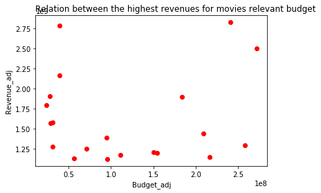

```python
plt.plot(x, y, 'ro');
plt.xlabel('Budget_adj');
plt.ylabel('Revenue_adj');
plt.title('Relation between the highest revenues for movies relevant budget',loc='left');
plt.show();
```

### Finding 1 : movie success don't depend only on budget but there are many other factors .

### Research Question 2 ( Do the vote count depend on revenue ?)

```python
vote_count_revenue = df_clean.groupby('revenue_adj').vote_count.max().sort_values(ascending= False).head(20)
vote_count_revenue
```

```
revenue_adj
8.255000e+08    9767
1.443191e+09    8903
2.827124e+09    8458
1.014733e+09    8432
4.039911e+08    7375
6.564734e+08    7080
1.137692e+09    6882
1.026713e+09    6723
5.726906e+08    6498
9.658933e+08    6417
6.067687e+08    6351
5.926566e+08    6220
3.481613e+08    6185
1.052849e+09    6137
1.073080e+09    6079
1.320229e+08    5923
4.169346e+07    5754
1.326278e+09    5636
7.122911e+08    5612
1.392446e+09    5562
Name: vote_count, dtype: int64
```

```python
x1 = vote_count_revenue.index
y1 = vote_count_revenue.values
x1, y1
```

```
(Float64Index([       825500000.0,   1443191435.20607,   2827123750.41189,
                 1014733032.48168,   403991051.509381,  656473401.9365281,
                 1137692372.63862,   1026712780.23392,   572690645.122961,
                965893322.8228301,     606768749.6621,   592656630.491278,
                 348161292.489031,    1052849482.6268,   1073079785.52895,
               132022892.45436999, 41693462.718575895, 1326278010.4756699,
                 712291130.169508,    1392445892.5238],
              dtype='float64', name='revenue_adj'),
 array([9767, 8903, 8458, 8432, 7375, 7080, 6882, 6723, 6498, 6417, 6351,
        6220, 6185, 6137, 6079, 5923, 5754, 5636, 5612, 5562]))
```

```python
slope, intercept, r, p, stderr = scipy.stats.linregress(x1, y1)
line = f'Regression line: y={intercept:.2f}+{slope:.2f}x, r={r:.2f}'
```

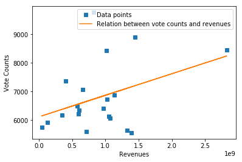

```python
fig, ax = plt.subplots()
ax.plot(x1, y1, linewidth=0, marker='s', label='Data points')
ax.plot(x1, intercept + slope * x1, label='Relation between vote counts and revenues')
ax.set_xlabel('Revenues')
ax.set_ylabel('Vote Counts')
ax.legend(facecolor='white')
plt.show()
```

### Finding 2 : Vote counts depends on movie revenues with positive correlation .

### Research Question 3 ( what the highest genres in every year ?)

```python
genres_year = df_clean.groupby(['release_year','genres']).genres.count().sort_values(ascending= False).head(10)
genres_year
```

```
release_year  genres
2014          Drama          72
2013          Drama          59
2012          Drama          58
2015          Drama          58
2013          Comedy         58
2014          Comedy         50
              Documentary    48
2009          Comedy         43
2012          Comedy         42
2013          Documentary    40
Name: genres, dtype: int64
```

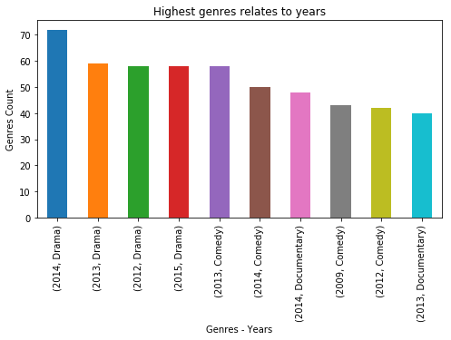

```python
genres_year.plot(kind = 'bar' , title = 'Highest genres relates to years', figsize=(8,4))
plt.xlabel('Genres - Years')
plt.ylabel('Genres Count');
```

### Finding 3 : Drama has the highest genres count in a single year which happened in 2014 .

### Research Question 4 ( when did the all time highest revenue happen and what was the movie?)

```python
movie_revenue_year = df_clean.groupby(['release_year','original_title']).revenue_adj.max().sort_values(ascending= False).head(10)
movie_revenue_year
```

```
release_year  original_title
2009          Avatar                            2.827124e+09
1977          Star Wars                         2.789712e+09
1997          Titanic                           2.506406e+09
1973          The Exorcist                      2.167325e+09
1975          Jaws                              1.907006e+09
2015          Star Wars: The Force Awakens      1.902723e+09
1982          E.T. the Extra-Terrestrial        1.791694e+09
1995          The Net                           1.583050e+09
1961          One Hundred and One Dalmatians    1.574815e+09
2012          The Avengers                      1.443191e+09
Name: revenue_adj, dtype: float64
```

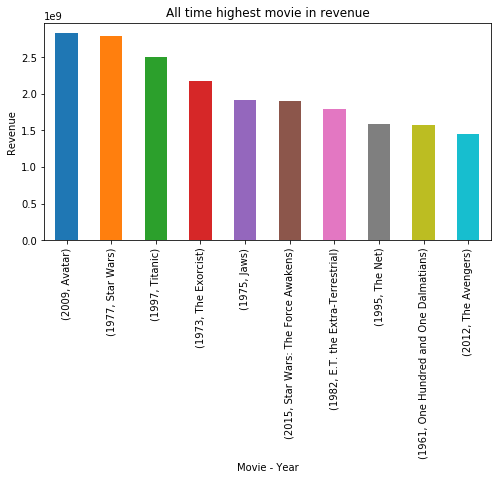

```python
movie_revenue_year.plot(kind = 'bar' , title = 'All time highest movie in revenue', figsize=(8,4))
plt.xlabel('Movie - Year')
plt.ylabel('Revenue');
```

### Finding 4 : Avatar is the all time highest movie in revenues which produced in 2009 .

### Research Question 5 ( what is the company produced more movies ?)

```python
production = df_clean.groupby('production_companies').production_companies.count().sort_values(ascending= False).head(10)
production
```

```
production_companies
Paramount Pictures                        156
Universal Pictures                        133
Warner Bros.                               84
Walt Disney Pictures                       76
Columbia Pictures                          72
Metro-Goldwyn-Mayer (MGM)                  72
New Line Cinema                            61
Touchstone Pictures                        51
20th Century Fox                           50
Twentieth Century Fox Film Corporation     49
Name: production_companies, dtype: int64
```

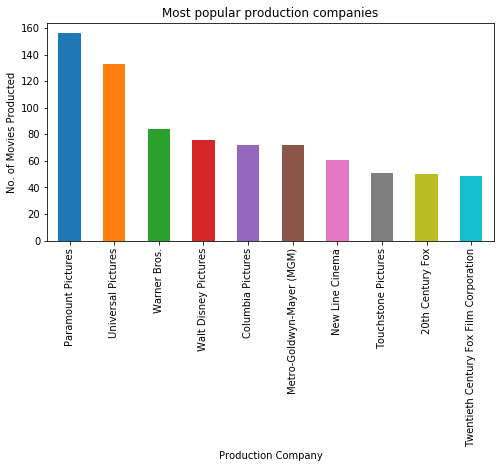

```python
production.plot(kind = 'bar' , title = 'Most popular production companies', figsize=(8,4))
plt.xlabel('Production Company')
plt.ylabel('No. of Movies Producted');
```

### Finding 5 : Paramount Pictures is the most company produced movies with 156 movies .

### Research Question 6 ( who is the director with high vote average ?)

```python
director_vote_average = df_clean.groupby('director').vote_average.mean().sort_values(ascending= False).head(10)
director_vote_average
```

```
director
Mark Cousins                                   9.2
Derek Frankowski                               8.8
David Mallet                                   8.7
Curt Morgan                                    8.5
Saul Swimmer                                   8.5
Martin Scorsese|Michael Henry Wilson           8.5
James Payne                                    8.5
Anthony Mandler                                8.4
Jorge RamÃrez SuÃ¡rez                         8.4
D.A. Pennebaker|David Dawkins|Chris Hegedus    8.4
Name: vote_average, dtype: float64
```

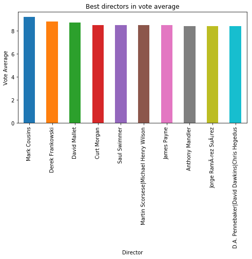

```python
director_vote_average.plot(kind = 'bar' , title = 'Best directors in vote average', figsize=(8,4))
plt.xlabel('Director')
plt.ylabel('Vote Average');
```

### Finding 6 : Movies directed by Mark Cousins is the highest in vote average .

### Research Question 6 ( who is the director with more movies in TMDb ?)

```python
director_Movies = df_clean.groupby('director').original_title.count().sort_values(ascending= False).head(10)
director_Movies
```

```
director
Woody Allen          45
Clint Eastwood       34
Steven Spielberg     29
Martin Scorsese      29
Ridley Scott         23
Steven Soderbergh    22
Ron Howard           22
Joel Schumacher      21
Brian De Palma       20
Wes Craven           19
Name: original_title, dtype: int64
```

[figure not shown]

```python
director_Movies.plot(kind = 'bar' , title = 'Director with more movies in TMDb', figsize=(8,4))
plt.xlabel('Director')
plt.ylabel('NO. of movies');
```

### Finding 7 : Woody Allen is the most director had movies in TMDb with 45 movies .

### Research Question 8 ( which year has more movies in TMDb ?)

```python
Movie_count_year = df_clean.groupby('release_year').original_title.count().sort_values(ascending= False).head(10)
Movie_count_year
```

```
release_year
2014    700
2013    659
2015    629
2012    588
2011    540
2009    533
2008    496
2010    490
2007    438
2006    408
Name: original_title, dtype: int64
```

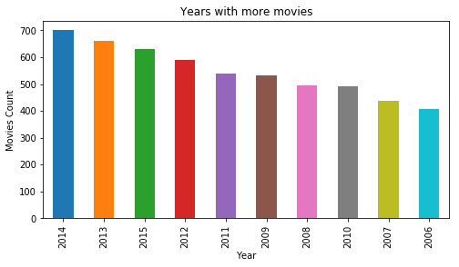

```python
Movie_count_year.plot(kind = 'bar' , title = 'Years with more movies', figsize=(8,4))
plt.xlabel('Year')
plt.ylabel('Movies Count');
```

### Finding 8 : 2014 is the most year has movies in TMDb with 700 movies .

### Research Question 9 ( In 2014 'the year with most movies count' what was the genres proportions ?)

```python
df_2014 = df_clean[df_clean['release_year'] == '2014']
```

```python
df_pie = df_2014.groupby('genres').genres.count().sort_values(ascending= False).head(10)
df_pie
```

```
genres
Drama              72
Comedy             50
Documentary        48
Horror             28
Drama|Comedy       17
Thriller           16
Comedy|Romance     16
Thriller|Horror    15
Horror|Thriller    15
Action             10
Name: genres, dtype: int64
```

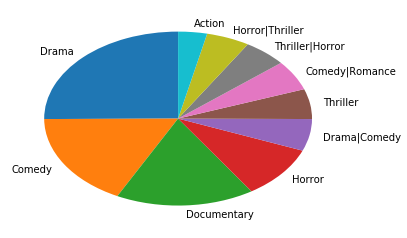

```python
my_labels = df_pie.index
y2 = np.array(df_pie.values)
plt.pie(y2, labels = my_labels , startangle = 90)
plt.show()
```

### Finding 9 : Dram is the top genre in 2014.

### Research Question 10 ( what is the movies run time range that the viewers watched more ?)

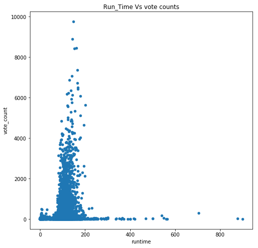

```python
df.plot(x='runtime', y='vote_count', kind= 'scatter', title = 'Run_Time Vs vote counts',figsize=(8,8));
```

### Finding 10 : the viewers prefer movies with time range from 50 up to 150 minutes to watch .

## Conclusions:

#### After cleaning the data i started to pose questions and analyze data , here are some results and findings :

- Finding 1 : movie success don't depend only on budget but there are many other factors .
- Finding 2 : Vote counts depends on movie revenues with positive correlation .
- Finding 3 : Drama has the highest genres count in a single year which happened in 2014 .
- Finding 4 : Avatar is the all time highest movie in revenues which produced in 2009 .
- Finding 5 : Paramount Pictures is the most company produced movies with 156 movies .
- Finding 6 : Movies directed by Mark Cousins is the highest in vote average .
- Finding 7 : Woody Allen is the most director had movies in TMDb with 45 movies .
- Finding 8 : 2014 is the most year has movies in TMDb with 700 movies .
- Finding 9 : Dram is the top genre in 2014.
- Finding 10 : the viewers prefer movies with time range from 50 up to 150 minutes to watch .

#### Note: I also did the explanatory process with tableau software to make insightful dashboards.You can find Tableau dashboards through this link: https://public.tableau.com/app/profile/khaled.yaseen/viz/TMDbMovies/GenresProductionCompanies

```python
from subprocess import call
call(['python', '-m', 'nbconvert', 'Investigate_a_Dataset.ipynb'])
```

```
0
```